# Time Series Econometrics (TSE)

Henri Nyberg

2025-10-20

# Preface

Foreword

Notation

# 1 Introduction

## 1.1 Time series data

A **time series** is a collection of data in which the observations correspond to consecutive time periods. A common notation for time series data is $y_{t}$, $t=1,\ldots,T$, where $t$ denotes the time period and $T$ the total number of observations. The interval between observations $y_{t-1}$ and $y_{t}$, or $y_{t}$ and $y_{t+1}$, is a some unit of time, for example, an hour, a month, a quarter or one year. In many cases, it may be natural to use more concrete labels for the time periods, for instance $t=2000,\ldots,2024$ for yearly data, or $t=2000:1, 2000:2,\ldots,2024:12$ for monthly observations. Therefore, occasionally $T$ also denotes the concrete final time label such as 2024:12 (December 2024).

- Time series data are used and analysed in various fields, such as economics and finance, but also in social, natural, engineering, and medical sciences.
- In economics and finance, data sets are typically time series, which have led to relatively specific subfields of macroeconometrics and financial econometrics.

In this course, we assume that the observations recorded are equally spaced in time (or can be approximately treated as such). Irregularly spaced data call for different methods and are not treated here. If the time series observations $y_{t}, \, t=1,\ldots,T,$ are scalar valued, we talk about **univariate time series**. On the other hand, if $\boldsymbol{y}_{t}=(y_{1t},\ldots,y_{nt})$ is vector-valued, which is emphasized by the bolded symbol, we talk about **multiple time series** or **vector-valued time series**. In these latter cases, relationships between two or more time series is of interest.

We restrict ourselves to the common case where $y_t$ is a real-valued time series, or is at least treated as such, meaning that realizations are real numbers. In discrete and limited dependent time series, $y_t$ takes only discrete values, such as binary values ($y_t=1$ or $y_t=0$) or values where the range is limited (such as the case where $y_t$ is nonnegative). These type of time series variables require specific (nonlinear) models, which we will not consider in this course (except models used for volatility modelling and hence positive-valued variables).

When analyzing time series data, often a useful and natural first step is to plot the data and inspect its main characteristics visually. Below we plot the monthly Consumer Price Index (CPI) in the United States for the time period $1990:1$–$2025:6$. In this figure, and as almost always when plotting time series data, to point out the nature of time series data (dependency between observations) the depicted line goes through observation points.

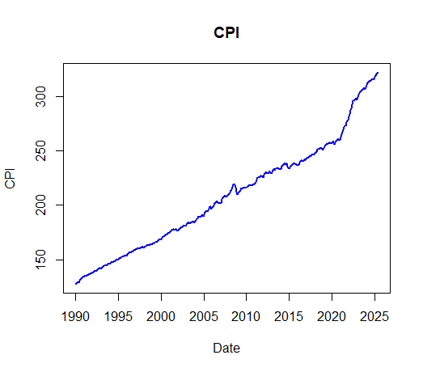

Figure: Monthly U.S. Consumer Price Index between January 1990 to June 2025 (1990:1–2025:6) (source: Shiller data).

The aim in time series analysis is often to build a **statistical model** that aims to represent the observed time series and its fluctuation over time. This typically happens by considering the dependence structure of consecutive observations. **Autocorrelation** (serial correlation) between observations is an essential property of the time series, which needs to be taken into account in statistical/econometric modelling.

- This violates the no-autocorrelation assumption typically imposed on the linear regression model (for cross-sectional datasets).
- With cross-sectional data, random sampling (usually) guarantees that the error terms of the linear regression model for different observations are mutually independent, and hence autocorrelation is (typically) not an issue.

When analyzing time series data often a useful and natural first step is to plot the series and inspect its main characteristics visually in addition to possible underlying theory or background knowledge of the phenomenon that the time series presents. This will bring (at least) preliminary idea on dependence structures behind the data generating mechanism of the time series. Some important questions to consider when looking at a time series graph:

- Is there a **trend** (i.e. the values of the time series tend to increase or decrease over time)?
- Are there **seasonal effects** (a regularly repeating pattern of highs and lows related to calendar time such as seasons, quarters, months or days of the week)?
- Any major **outliers** (observations far away from other data points)?
- Is the **variability** (variance) relatively **constant** over time?
- Are there any **abrupt changes** such as **breaks** or **regime switches** to either the level or variance of the series?

As an example, in the U.S. CPI time series above, a clear feature is an increasing trend over time. It turns out that instead of the levels, we are mainly interested in the changes of the CPI series as a measure of inflation, as will be discussed below.

An increasing trend can also be observed in the (monthly) S&P 500 stock market index. Stock prices rallied substantially between the years 1990 and 2025 (that is, stock prices experienced a substantial surge), while there are also a few substantial market corrections (“bear markets”) throughout the years. What is also important to notice at this stage is that this trending behaviour is clearly different than the one behind the CPI series.

- Characteristics behind these type of “stochastic” trends, as in the S&P 500 index, will be addressed later in this course when discussing nonstationary time series data.

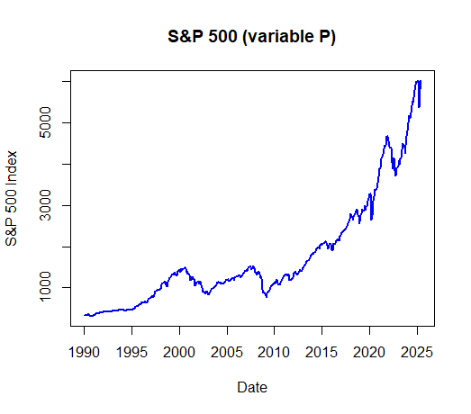

Figure: S&P 500 stock market index between January 1990 and June 2025 (source: Shiller data).

Next figure depicts the monthly number of fatalities in traffic accidents in the U.S. between $1973:1$–$1978:12$. In this series, there is no apparent increasing or decreasing trend. Instead, the series exhibits clear **seasonal variation**, with the yearly maximum always in July and the minimum in February.

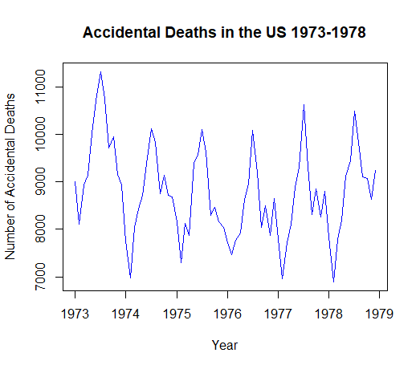

Figure: Monthly traffic accidents between January 1973 and December 1978. (source: Brockwell and Davis, 1996).

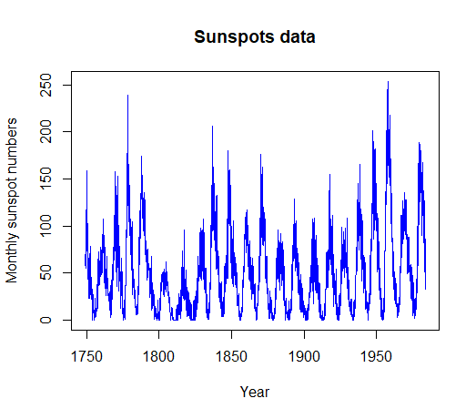

Overall, these visual findings might already suggest which type of **time series model** could be useful. After (at least a preliminary) a statistical model, as we will consider more detail in the coming sections, has been chosen, one can then for example:

- estimate the unknown parameters of the model,
- check whether the estimated model and the observations are compatible,
- test hypotheses concerning the model parameters,
- and finally, use the model for the intended end purpose.

The end purpose of how the statistical model will be eventually used varies depending on the situation and the fields of application.

- One use is to give a **summarized description** of the observed data set, which may be useful in understanding the underlying data generation process producing the data.
- Another central use of a time series model is to **forecast** the future values of the single or multiple time series. In the multivariate case, one time series of interest may be predicted by making use of information contained in other time series as predictive variables.
- One is often also interested in exploring potential **temporal and contemporaneous dependencies** between the time series, such as the relationship between inflation and stock market returns, after relevant transformations as discussed next. One may be interested in investigating whether higher inflation typically occurs simultaneously with increasing stock prices (in such an investigation, it would be appropriate to take also various other time series variables into account).

## 1.2 Transformations

As described above, in time series modelling a good first step is always to plot the time series under investigation. This gives an idea of the main features of the time series such as trends, seasonal patterns and/or apparent sudden breaks or outlying observations. In what follows in the next few Sections, it is assumed that these patterns do not exist. If the observed series does exhibit several such patterns, one should use a transformation is to eliminate these patterns.

In time series analysis, a few transformations and “manipulations” are generally used and they are even natural and common parts of the empirical analyses in certain applications.

- The **first lag** of the time series $y_t$ is denoted by $y_{t-1}$. Generally **$k$th lag** is $y_{t-k}$.
- Perhaps the most commonly used transformation for time series data is **differencing**. The **first difference** of the series, $\Delta y_t$, is the **change** between $y_t$ and $y_{t-1}$. In other words,
  $$\begin{equation*}
  \Delta y_t = y_t - y_{t-1}.
  \end{equation*}$$
- Often differencing is combined with taking natural **logarithms** (when assuming $y_t > 0, \, \forall t$). Taking logarithms is common especially when the series exhibits exponential growth or when the variation in the series increases as the level increases. The **logarithmic change** is
  $$\begin{equation*}
  \Delta \mathrm{log}(y_t) = \mathrm{log}(y_t) - \mathrm{log}(y_{t-1}).
  \end{equation*}$$
  Importantly, the logarithmic changes can be interpreted as relative changes when the changes are small:
  $$\begin{equation*}
  \Delta \mathrm{log}(y_t) \approx (y_t - y_{t-1})/y_{t-1}.
  \end{equation*}$$
- The **percentage of change** between periods $t$ and $t-1$ is $100 \Delta \mathrm{log}(y_t)$. With quarterly data $y_t$, **annualized growth rates** are obtained by multiplying 400, that is $400 \Delta \mathrm{log}(y_t)$, whereas annualized growth rates with monthly data can be approximated as $1200 \Delta \mathrm{log}(y_t)$.

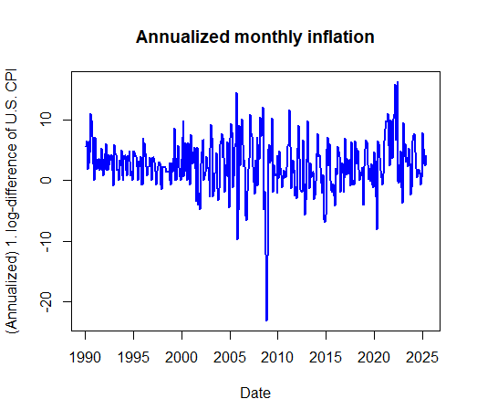

Figure: Annualized U.S. inflation (CPI inflation) rate between February 1990 to June 2025 (1990:2–2025:6).

**More on differencing**. Differencing may also happen with a longer lag than the first lag: $y_{t}-y_{t-s},\, \left(s\geq1\right)$.

- As discussed above, the above case $s=1$ is the most common (representing change from one period to another).
- In the case of seasonal variation, $s$ is often selected to match the length of the seasonal pattern. That is, for example, $s=4$ for the quarterly data and $s=12$ for the monthly series.

If denoting temporarily $y_t$ as the log CPI, taking seasonal differencing $100 (y_{t}-y_{t-12})$ yields another proxy for the U.S. inflation (cf. the time series above)

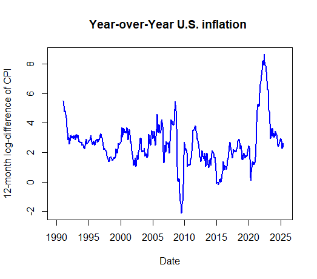

As another use of differencing, especially in financial econometrics and empirical finance, is to financial time series and returns that different assets yield for investors. Let $P_t$ the price of an asset at time $t$. Holding the asset for one period from $t-1$ to $t$ would result in a simple return
$$\begin{equation*}
R_t = \frac{P_t}{P_{t-1}} - 1 = \frac{P_t - P_{t-1}}{P_{t-1}}.
\end{equation*}$$
Moreover, so called continuously compounded return (or log return) is
$$\begin{equation*}
r_t = \mathrm{log}(1+R_t) = \mathrm{log} \Big(\frac{P_t}{P_{t-1}}\Big) =p_t - p_{t-1},
\end{equation*}$$
where $p_t = \mathrm{log} (P_t)$ and having some advantages over simple returns. In both cases percentage returns are obtained by multiplying $r_t$ or $R_t$ by 100.

- Importantly, in various financial applications, dividend (and equivalent) payments must also be taken into account when computing returns. If an asset pays dividends periodically, we must modify the definitions of asset returns. We will not consider these issues more detail in this course and details are left to more detailed studies in finance.

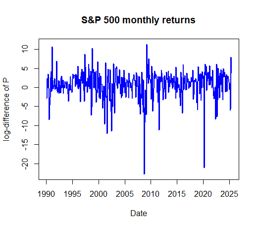

**Detrending**. The trend and/or seasonal patterns etc. of the original time series are often modelled via transformation so that this step may itself require estimation of some parameters. For example, in the case of a linear trend, one can fit a trending line using least squares regression, and then consider modelling the resulting residual series using time series methods. In that case, an observed time series $y_{t}$ would be replaced by the time series
$$\begin{equation*}
\hat{x}_{t}=y_{t}-\hat{\alpha}-\hat{\boldsymbol{\beta}}t,\,\,t=1,\ldots,T,
\end{equation*}$$
where the estimates $\hat{\alpha}$ and $\hat{\boldsymbol{\beta}}$ are obtained by regressing $y_{t}$ on a constant and $t$. More generally, instead of the linear function (of time), one can use more general polynomials as well.

- To model seasonal variation, one could use trigonometric functions of time.
- An often used alternative to remove seasonal variation (if not using already existing seasonally adjusted data) is the so-called seasonal indicators. As an example of this, for quarterly data, one would obtain seasonally-adjusted series by
  $$\begin{equation*}
  \hat{x}_{t}=y_{t}-\hat{\boldsymbol{\beta}}_{1}d_{1t}-\cdots-\hat{\boldsymbol{\beta}}_{4}d_{4t},\,\,t=1,\ldots,T,
  \end{equation*}$$
  where the $i$th seasonal indicator $d_{it}$ takes value one when the observation in question corresponds to quarter $i$ and zero otherwise ($i=1,\ldots,4)$.

As for additional information (in this course), there is also a relatively broad literature on more advanced detrending techniques than differencing and seasonal dummies in econometrics.

## 1.3 Assumptions and limitations of this course

In summary, we consider time series models/processes assuming that the observed time series do not exhibit clear seasonal patterns. If necessary, those patterns have been eliminated using some transformation or using some seasonal adjustment methods, and one is eventually modelling the transformed series.

- The typical approach especially with macroeconomic data is to use **seasonally-adjusted datasets** provided by official statistics organizations (like Statistics Finland). Therefore, we can assume that the seasonal effects are, at least at reasonable degree, already taken into account.

Concerning trends, in the first part of this course (Sections 2–9) we consider **stationary time series processes** and their realizations (i.e. time series). These assume that there are no clear trends and/or trending type behaviour in the time series.

- That is the time series are more or less realizations which resemble more U.S. inflation series and stock market returns above than the CPI level series or the s&P 500 price series.
- As for now, it suffices to understand that non-stationary time series can usually (though not always) be transformed by differencing such that stationarity assumptions hold reasonably well and thus a stationary such as ARMA($p,q$) process is possible.
- An exception to the stationary time series starts becomes at the later part of the material where trending type of behaviour will be considered more detail. The basics of nonstationary processes will be discussed in Sections 12–13 where modelling the deterministic and/or especially the stochastic trend is of interest in several applications.

Finally, we will start with univariate time series. That is we are analysing one time series at hand. Later on in Sections 10–11 and 13, we will also consider basics of multiple (multivariate) time series.

## 1.4 R Lab

All the R codes considered in this section are compiled in the following link (Tab). Notice that you might need to download some datasets from the course website and include them to the same folder as this file.

# 2 A primer on time series models

## 2.1 Starting point

**Relation to the linear regression for cross-sectional datasets**. In standard econometrics or statistics courses, linear regression models are typically introduced using cross-sectional data. A key assumption for these models is the absence of autocorrelation in the error term. With time series data, however, autocorrelation is a fundamental characteristic and is almost always present.

- While linear regression can be applied to time series variables, the notation changes to reflect the temporal ordering. Variables are indexed by time, such as $y_t$ and $x_t$ (instead of $y_i$ and $x_i$ for cross-sectional observations).

We will return to multivariate regression models with time series variables later. First, we will explore **a pure time series approach** (as characterized by Verbeek, 2008).

- In this approach, the current value of a univariate time series, $y_t$, is modeled as a function of its past values, either directly or indirectly.
- The emphasis is therefore entirely on using the information contained in $y_t$ and its own history for modeling and forecasting purposes.

## 2.2 Notes on deterministic components

In time series analysis and models for such data, we often decompose a time series process $y_t$ into a deterministic and stochastic parts. This allows us to separate deterministic parts, like the mean and trend, from the random fluctuations that are the primary focus of stochastic models, such as in ARMA or VAR models to be introduced in this course.

The general decomposition and starting point in our notation throughout this material is given by:
$$\begin{equation*}
y_t = \mu_t + z_t,
\end{equation*}$$
where the components are defined as:

- $\mu_t$: This term represents the **deterministic part**.
- $z_t$: This is the **stochastic part**, representing (random) fluctuations around the deterministic component. A crucial assumption is that this process has a zero mean, i.e., $\mathsf{E}(z_t)=0$. Therefore, $z_t$ represents the demeaned and detrended time series process, which may, and typically, have its own autocorrelation structure and hence importantly $z_t$ is not just pure random noise.

By this construction, the expected value of $y_t$ is simply its deterministic component:
$$\begin{equation*}
\mathsf{E}(y_t) = \mathsf{E}(\mu_t + z_t) = \mu_t + \mathsf{E}(z_t) = \mu_t
\end{equation*}$$

**Common forms of the deterministic component**. The functional form of $\mu_t$ depends on the underlying characteristics of the data and application in general. Two of the most common specifications are:

- **Constant mean**: If the time series fluctuates around a fixed, time-invariant level, the deterministic component is simply a constant
  $$\begin{equation*}
  \mu_t = \mu.
  \end{equation*}$$
  Here, $\mu$, or at times $\mu_0$, represents the unconditional mean of the process $\mathsf{E}(y_t)$. In general, almost all real-life time series have nonzero mean.
- **Constant and linear time trend**: If the series exhibits a persistent upward, or downward, movement over time, we also include a linear trend (together with the constant term). The deterministic component then includes both a constant and a time trend
  $$\begin{equation*}
  \mu_t = \mu_0 + \mu_1 t
  \end{equation*}$$
  where $\mu_0$ is the constant (the value of $\mu_t$ at $t=0$), and $\mu_1$ is the trend coefficient, representing the average change in $y_t$ from one period to the next.

In practice, at times we first estimate the parameters of the deterministic part $\mu_t$, e.g., via Ordinary Least Squares, and then work with $z_t$ as a residual between $y_t - \mu_t$. This is the tactic as described in Section 1 in connection to simple detrending techniques. Alternatively, and more often, modelling deterministic and random components will be carried out simultaneously.

- In our notation, $x_t$, or $\boldsymbol{x}_t$ in the case of multiple time series, is used for a general time series process (for different notational purposes) and most often they are explanatory (predictive) variables.

# 3 Stationary processes

## 3.1 Basic concepts

The aim is to build a statistical model for the observed time series $y_{1},\ldots,y_{T}$. At this stage, and in Sections 3–9 and 12, we assume that we have one, univariate, time series. Multiple time series and multivariate models will be briefly considered later in Sections 10–11 and 13.

On a rather general level, the observed time series can be interpreted as the observed value of the random vector $\boldsymbol{y}=\left(y_{1},\ldots,y_{T}\right)$ or, in other words, the **realization** of this random vector.

- Recall the notation: Here the random vector interpretation emphasizes the fact that $y_t$ will be interpreted as a random variable. Notice that We do not make a distinction between random variables and their realizations; the difference should be clear from the context.

When building a statistical model, we would attempt to specify the probability distribution of the $T$–dimensional random vector $\boldsymbol{y}=\left(y_{1},\ldots,y_{T}\right)$ that produced the observed time series.

- Note and recall that in a time series, the observations are (typically) not independent as in the conventional linear regression, and therefore it is not enough to specify the marginal distributions of the components $y_{t}$ $\left(t=1,\ldots,T\right)$.
- Instead, we indeed need to specify the $T$–dimensional joint distribution.

A concrete and often used way to specify the joint distribution of $\boldsymbol{y}$ in time series analysis is to:

- Specify a model equation that characterises the dependence structure of consecutive observations, and
- combine this with a *suitable* distributional assumption.

Before we proceed to such concrete model equations, it is useful to first briefly study some basic concepts of probability theory that form the foundation of time series analysis.

## 3.2 Stochastic processes

In statistical and econometric modelling of time series, one concentrates on the observed time series. That is the realization of a random vector $\boldsymbol{y}=\left(y_{1},\ldots,y_{T}\right)$.

From a mathematical point of view, however, it is more convenient to consider an “extension” of this vector to all time indices when defining time series models. This leads us to the concept of (a discrete time) **stochastic process** (or just simply **process**), which is a collection of random variables $\left\{y_{t};t=0,\pm1,\pm2,\ldots\right\}$.

- Occasionally, the cases $t=0,1,2,\ldots$ or $t=1,2,\ldots$ are also considered.
- Because the set of values the time index takes is usually known, it does not need to be emphasized, and often we can simply denote the stochastic process by $y_{t}$, or $\left\{y_{t}\right\}$ if one wants to emphasize the distinction to a single component of the process.
- The terms “**process**” and “**model**” are often used interchangeably in time series analysis. In this material, “process” emphasizes to the underlying theoretical mechanism (that is, the stochastic process) we aim to capture with an empirical and estimated “model” for the time series.

From a practical point of view, it is important to note that **we have only a single realization available**, the observations $\left(y_{1},\ldots,y_{T}\right)$, of the process $\left\{y_{t}\right\}$.

- In other words, we have only one realization from the process and that is only partial, that is observations are available only for the time periods $t=1,\ldots,T$.

These above-mentioned points imply that in order to investigate the properties of $y_t$ by making use of the observed data $y_{1},\ldots,y_{T}$ only, one must make some restrictive assumptions about $y_t$ for this to be possible.

## 3.3 Weak stationarity

To illustrate the final remarks in the previous section, consider the **expected value function** of the process $y_{t}$ (assume here $\mathsf{E}\left(y_{t}^{2}\right)<\infty$ for all $t$)
$$\begin{equation*}
\mu_{t}=\mathsf{E}\left(y_{t}\right),\quad t=0,\pm1,\pm2,\ldots
\end{equation*}$$
as well as the **covariance function** of $y_{t}$
$$\begin{equation*}
\gamma_{s,t}=\mathsf{Cov}\left(y_{s},y_{t}\right)=\mathsf{E}\left[\left(y_{s}-\mu_{s}\right)\left(y_{t}-\mu_{t}\right)\right], \quad t=0,\pm1,\pm2,\ldots\text{.}
\end{equation*}$$

Estimating these functions by making use of one realization $y_{1},\ldots,y_{T}$ only is of course impossible, unless we somehow restrict/limit their dependence on time. **The situation simplifies if it is assumed that these quantities do not depend on time**. Indeed, it is common to assume that such a dependence on time does not (in a particular sense) exist.

A process $y_{t}$ is called **weakly stationary**, or **covariance stationary**, if
$$\begin{equation*}
\mathsf{E}\left(y_{t}\right)=\mu < \infty \quad \mathrm{for\,\, all} \quad t=0,\pm1,\pm2,\ldots
\end{equation*}$$
and
$$\begin{equation*}
\mathsf{Cov}\left(y_{t},y_{t+h}\right)=\gamma_{t,t+h}=\gamma_{0,h} < \infty \,\, \text{for all }\,\, h,\text{ }t=0,\pm1,\pm2,\ldots\text{ .}
\end{equation*}$$
In other words, a form of **time invariance** holds: The expected value function $\mu_{t}$ is constant over time, and the covariance function $\gamma_{s,t}$ does not depend on the time indices $s$ and $t$ but only on their distance $t-s$.

- For brevity, denote $\gamma_{0,h} \equiv \gamma_{h}$.
- When $h$ is fixed, $\gamma_{h}$ is called the **autocovariance (coefficient)** of $y_{t}$ at lag $h$. As a function of $h$, the $\gamma_{h}$ is called the **autocovariance function** of $y_{t}$.
- The $\mu$ is called the **expected value** or the **mean**.

To summarize, a characteristic feature of weakly stationary process is that the first and second moments are finite and independent of time. Unless otherwise mentioned, in what follows (in this and coming few sections), **we assume that weak stationarity holds**.

A useful **practical aspect** of weak stationarity is that the plausibility of this assumption can be easily investigated by looking at a graph of the observed time series: If the observations vary with constant variance around a fixed level, then weak stationarity appears a plausible assumption.

Let us consider an example related to U.S. real GDP growth during the period 1985–2007, commonly referred to as the **Great Moderation** time period.

- More on The Great Moderation, see https://www.federalreservehistory.org/essays/great-moderation
- Real Gross Domestic Product (GDP) is the total value of a country’s goods and services produced in a specific period, adjusted for inflation.

This figure (see below) illustrates that the time series fluctuates around a relatively stable mean and exhibits approximately constant variance over time. As discussed, this behavior is typical for a weakly stationary process.

It is important to note that **weak stationarity does not imply the absence of variability**. Even in a weakly stationary process, individual observations can vary substantially due to random shocks. What matters is that the statistical properties — the mean, variance, and autocovariance structure — remain constant over time. So, occasional high or low values in the series are entirely consistent with weak stationarity, as long as they are the result of random variation and not due to major structural changes in the process.

- We will soon see more examples of weakly stationary time series through simulations.
- In Section 1, the time series depicting the U.S. inflation rate can also be interpreted as realizations from weakly stationary processes.

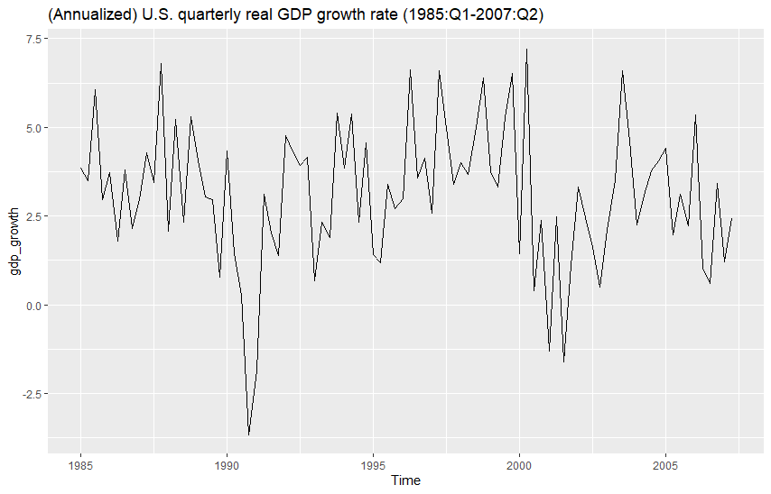

Figure: (Annualized) U.S. quarterly real GDP growth rate (1985:Q1-2007:Q2) (ggplot2 figure).

Because $\gamma_{0}=\mathsf{Var}\left(y_{t}\right)$, it holds that $\gamma_{0}\geq0$. Furthermore, the familiar properties of the covariance function imply that

- $\left\vert \gamma_{h}\right\vert \leq\gamma_{0}$.
- In this univariate (single time series) case, we have (under weak stationary)
  $$\begin{equation*}
  \mathsf{Cov}\left(y_{t},y_{t+h}\right)=\mathsf{Cov}\left( y_{t-h},y_{t}\right) = \mathsf{Cov}\left(y_t, y_{t-h}\right),
  \end{equation*}$$
  which also implies that $\gamma_{h}=\gamma_{-h}$. This expression shows where the term *lag* (*lag length*) $h$ is coming from.

Putting the above properties together, the autocovariance function has the properties
$$\begin{equation*}
\gamma_{0}\geq0, \,\, \left\vert \gamma_{h}\right\vert \leq\gamma_{0} \quad \mathrm{and} \quad \gamma_{h}=\gamma_{-h}.
\end{equation*}$$
The case $\gamma_{0}=0$ is obviously not of interest, and in what follows we assume that $\gamma_{0}>0$.

## 3.4 Autocorrelation function

In practice, a more convenient concept than autocovariance function is the **autocorrelation function**
$$\begin{equation*}
\rho_{h}=\mathsf{Cor}\left(y_{t},y_{t+h}\right)= \mathsf{Cor}\left(y_t, y_{t-h}\right)=\gamma_{h}/\gamma_{0}.
\end{equation*}$$
The **autocorrelation coefficients** $\rho_{h}$ obviously then have the properties
$$\begin{equation*}
\rho_{0}=1, \,\, \left\vert \rho_{h}\right\vert \leq1, \, \mathrm{and} \,\, \rho_{h}=\rho_{-h}.
\end{equation*}$$
Therefore, it suffices to consider the autocovariance and autocorrelation functions only for the lag lengths $h\geq 0$

- The latter just for the lags $h>0$

Due to the time invariance guaranteed by weak stationarity, it now seems evident that $\mathsf{E}\left(y_{t}\right)=\mu$ and $\mathsf{Cor}\left(y_{t},y_{t+h}\right)=\gamma_{h}$ can be estimated. One more problem remains: The autocorrelation function, in general, has an infinite number of quantities to be estimated. In practice, all of these cannot be estimated (without further restrictions). However, typically we can assume that
$$\begin{equation*}
\gamma_{h}\rightarrow0, \,\, \mathrm{when} \,\, h\rightarrow\infty.
\end{equation*}$$
In this case, the random variables $y_{t}$ and $y_{t+h}$ become **nearly uncorrelated when the distance $h$ is “large”** – that is, when $y_{t}$ and $y_{t+h}$ are “far” from each other in time.

- Therefore, in practice it suffices to estimate the autocorrelation function $\rho_{h}$, when $h=1,\ldots,H$, and $H$ is so large that $\rho_{h}\approx0$ for $h>H$.

## 3.5 Sample autocorrelation function

**Assume that the process $y_{t}$ is weakly stationary**. Then $\mathsf{E}\left(y_{1}\right)=\cdots=\mathsf{E}\left(y_{T}\right)=\mu$. Therefore, a natural estimator of the (population) mean is the **sample mean**
$$\begin{equation*}
\bar{y}=\frac{1}{T}\sum_{t=1}^{T}y_{t}.
\end{equation*}$$

Because (under weak stationarity) $\mathsf{Cov}\left(y_{1},y_{1+h}\right)=\cdots=\mathsf{Cov}\left(y_{T-h},y_{T}\right)=\gamma_{h}$ $\left(h\geq0\right)$, it also seems natural to estimate the population autocovariance coefficient $\gamma_{h}$ using the sample covariance of the observations $\left(y_{1},y_{1+h}\right),\ldots,\left(y_{T-h},y_{T}\right)$. Because $\mathsf{E}\left(y_{t}\right)=\mathsf{E}\left(y_{t+h}\right)$ (again under weak stationary), a commonly used estimator is
$$\begin{equation*}
\mathsf{c}_{h}=\frac{1}{T-h}\sum_{t=1}^{T-h}(y_{t}-\bar{y})\left(y_{t+h}-\bar{y}\right), \quad 0\leq h<T,
\end{equation*}$$
which is called the ($h$th) **sample autocovariance coefficient**. Sometimes, the denominator $T-h$ is replaced by $T$.

- When $\mathsf{c}_{h}$ is interpreted as a function of $h$ (i.e. $c_1, c_2,\ldots$), it is called the **sample autocovariance function**.

A natural estimator of the autocorrelation coefficient $\rho_{h}$ is hence
$$\begin{equation*}
\mathsf{r}_{h}=\mathsf{c}_{h}/\mathsf{c}_{0}, \qquad 0\leq h<T,
\end{equation*}$$
which is called the **sample autocorrelation coefficient** and $\mathsf{r}_1, \mathsf{r}_2, \ldots$ define the **sample autocorrelation function**.

- Notice that by definition $\mathsf{r}_0=1$. Some statistical program packages report this uninteresting case.

- If $\rho_{h}=0$ for all $h>0$, then any individual estimator $\mathsf{r}_{h}$ has an approximately 95% probability of lying between the confidence bands $(-1.96/\sqrt{T}, 1.96/\sqrt{T})$ where $T$ is the number of observations. These confidence bands are depicted below and typically in corresponding figures.
- If the individual sample autocorrelation coefficient $\mathsf{r}_h$ does not fall between these bands, there is statistically significant autocorrelation at the 5% significance level at the lag $h$.

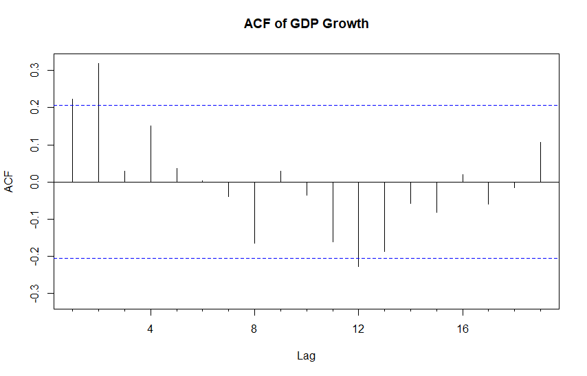

Figure: Sample autocorrelation function (ACF) of the quarterly U.S. real GDP growth rate ($T=90$, and hence $1.96/\sqrt{T} \approx 0.207$.)

This time series exhibit clear autocorrelation, which generally dampens (slowly) as the lag length $h$ increases.

- This dampening effect depends on the time series (process) considered
- Notice that above the first depicted lag (in this R function) is $\mathsf{r}_1$. At times in different functions and packages $\mathsf{r}_0=1$ is depicted, but that is of course not of interest.
- If there is some (remaining) seasonal variation, say in monthly time series after seasonal adjustment (if applicable), it causes rather strong autocorrelations at lags $h=12,$ $24$ and $36$. Similar behaviour can also happen if the time series contain some other cyclical pattern.

## 3.6 White noise process

Weak stationarity is not a strong enough assumption to allow statistical analysis of time series. It alone does not suffice for the construction of a likelihood function, nor is it enough to derive distributions of estimators or test statistics. For this reason, we need to define another concept of stationarity that is stronger than weak stationarity, **strict stationarity**. We will consider that in the next section.

Before that, let us consider first a **white noise process**, which is the simplest possible example of a weakly stationary process. Let $u_{t}$ be a process for which it holds that

- $\mathsf{E}\left(u_{t}\right) =\mu < \infty$, often $\mathsf{E}(u_t)=0$,
- $\mathsf{Var}\left(u_{t}\right)=\sigma^{2}<\infty$, and
- $\mathsf{Cov}\left(u_{s},u_{t}\right)=0$, when $s\neq t$.

This process is often called a **(weak) white noise** process and denoted by $u_{t}\sim\mathsf{wn}\left( \mu,\sigma^{2}\right)$.

- By definition, it is clear that a white noise process is weakly stationary
- Despite their simplicity, as we will see later on, white noise processes play a central role in time series analysis because they can be used to construct more complicated processes and eventually models.

## 3.7 Strictly stationary process

Let us now define the above-mentioned more stringent form of stationarity. A process $\left\{y_{t};t=0,\pm1,\pm2,\ldots\right\}$ is called **strictly stationary** (sometimes **strongly stationary**) if the collections of random variables $y_{t_{1}},\ldots,y_{t_{m}}$ and $y_{t_{1}+h},\ldots,y_{t_{m}+h}$ have the same $m-$dimensional joint distribution for all integers $t_{1},\ldots,t_{m}$, $h$ and $m$ $\left( m>0\right)$.

- That is, **the entire probability structure of the process $y_{t}$ is time-invariant**, not just the first and second-order moments.

**Properties**. A strictly stationary stochastic process has the following properties (that follow straightforwardly from the definition):

- **SS1**: The random variables $y_{t}$ have the same distribution for all $t$.
- **SS2**: The random vectors $(y_{t},y_{t+h})$ and $(y_{s},y_{s+h})$ have the same distribution for all $t$ and $s$ and all (fixed) $h$.
- **SS3**: $y_{t}$ is weakly stationary if $\mathsf{E}\left(y_{t}^{2}\right)<\infty$ holds.

It is clear that weak stationarity does not, in general, imply strict stationarity.

- For instance, weak stationarity says nothing about moments of order 3 and above.

A very useful property of strict (but not weak) stationarity is that it is conserved in transformations. In other words,

- **SS4**: If $x_{t}$ is a strictly stationary process, then so is also the process $y_{t}=g\left(x_{t+m},\ldots,x_{t-n}\right), m,n\geq0$, for any “well-behaving” (e.g. continuous or, more generally, measurable) function $g$. Moreover, $m$, $n$, or both can be replaced with $\infty$.

**“Stationarity” in this material**. Unless otherwise stated, stationarity will be interpreted as strict stationarity from now on.

- From practical time series analysis perspective, as introduced above, visual inspection of the time series is related to the theoretical implications of weakly stationary processes (i.e. mean, variance and autocovariances of the series are not dependent on time) is of interest.

## 3.8 IID and NID processes

Let $u_{t}$ be a sequence of **independent and identically distributed** (IID) random variables.

- The strict stationarity of this process is easy to check.

This IID process is also called white noise, or sometimes **strong white noise**. We will use the shorthand notation
$$\begin{equation*}
u_{t}\sim\mathsf{iid}\left(\mu,\sigma^{2}\right) \quad \mathrm{or} \quad u_{t}\sim\mathsf{IID}\left(\mu,\sigma^{2}\right)
\end{equation*}$$
where $\mathsf{iid}$ $\leftrightarrow$ refers to “independently and identically distributed”), $\mu=\mathsf{E}\left(u_{t}\right)$ and $\sigma^{2}=\mathsf{Var}\left(u_{t}\right)$ (in what follows, most often $\mu=0$).

If it is additionally assumed that $u_{t}\sim\mathsf{N}\left(\mu,\sigma^{2}\right)$, one denotes
$$\begin{equation*}
u_{t}\sim\mathsf{nid}\left(\mu,\sigma^{2}\right) \quad \mathrm{or} \quad u_{t}\sim\mathsf{NID}\left(\mu,\sigma^{2}\right)$
\end{equation*}$$
where $\mathsf{nid}$ $\leftrightarrow$ **normally and independently distributed**.

- In the following, the above standard notation for the $\mathsf{iid}$, $\mathsf{nid}$ and $\mathsf{wn}$ processes are used in these lecture notes from now on.

As an illustration of nid process, below we depict a simulated realization from the $\mathrm{nid}(0,1)$ process. The length of the time series is 300 observations ($T=300$). In other words, we can state that $z_t \sim \mathsf{nid}(0,1), \, t=1,\ldots,300$. The simulated time series exhibits completely random variation.

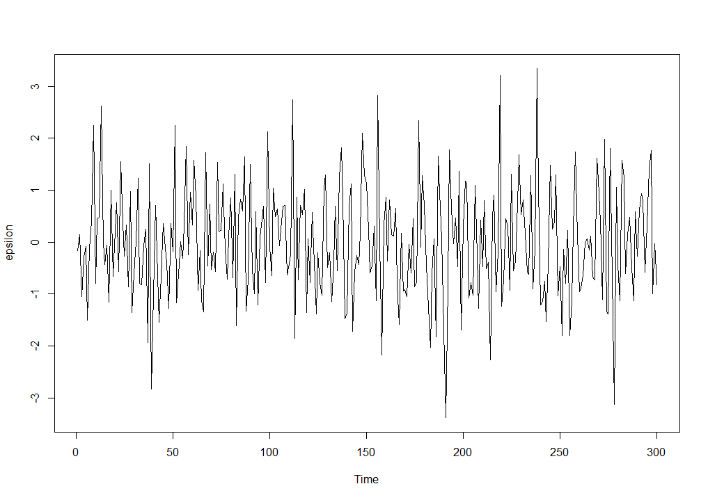

Figure: A simulated realization of nid(0,1) process ($T=300$).

## 3.9 R Lab

# 4 Linear process

## 4.1 MA(1) process

As was mentioned, white noise processes can be used to define more complicated processes. A simple example and special case is the **moving average process of order one**, or **MA(1) process**,
$$\begin{equation*}
y_{t} = \mu + u_{t} + \theta_1 u_{t-1}, \quad u_{t}\sim\mathsf{iid}\left(0,\sigma^{2}\right).
\end{equation*}$$
The values of the process are hence assumed to be generated as a weighted average of two independent and unobserved random shocks.

- In this process (model equation), we also include in the mean of the process $\mathsf{E}(y_t)=\mu$. Alternatively, we can write the MA(1) process as
  $$\begin{equation*}
  y_{t} - \mu \equiv z_t = u_{t}+\theta_1 u_{t-1}, \quad u_{t}\sim\mathsf{iid}\left(0,\sigma^{2}\right),
  \end{equation*}$$
- Notice that possible other deterministic components than a nonzero mean can also be readily included in if necessary.

MA(1) processes are strictly stationary (see above and the property SS4) and also weakly stationary. Simple calculations show that
$$\begin{eqnarray*}
\mathsf{E}\left(y_{t}\right) = \mathsf{E}(\mu) + \mathsf{E}\left(u_{t}\right)+\theta_1 \mathsf{E}\left(u_{t-1}\right)=\mu,
\end{eqnarray*}$$
$$\begin{eqnarray*}
\mathsf{Var}\left(y_{t}\right) &=& \mathsf{E}\Big(y_t- \mathsf{E}(y_t)\Big)^2 \\
&=& \mathsf{Var}\left(z_{t}\right) \\
&=& \mathsf{Var}\left(u_{t}\right)+\theta_1^{2}\mathsf{Var}\left(u_{t-1}\right) \\
&=& \sigma^{2}\left(1+\theta_1^{2}\right),
\end{eqnarray*}$$
and, for $h>0$,
$$\begin{eqnarray*}
\mathsf{Cov}\left(y_{t},y_{t+h}\right) &=& \mathsf{Cov}\left(z_{t},z_{t+h}\right) \\
&=& \mathsf{E}[\left(u_{t}+\theta_1 u_{t-1}\right)\left(u_{t+h}+\theta_1 u_{t+h-1}\right)] \\
&=& \mathsf{E}\left(u_{t}u_{t+h}\right)+\theta_1 \mathsf{E}\left(u_{t}u_{t+h-1}\right)+\theta_1 \mathsf{E}\left(u_{t-1}u_{t+h}\right)+\theta_1^{2}\mathsf{E}\left(u_{t-1}u_{t+h-1}\right) \\
&=& \left\{
\begin{array}
[c]{l}
\theta_1 \sigma^{2},\,\, h=1, \\
0,\,\, h>1.
\end{array}
\right.
\end{eqnarray*}$$
The latter two calculations make use of the independence of process $u_{t}$. These results show the weak stationarity of the MA(1) process.

- The same moment results are also obtained if the assumption $u_{t}\sim\mathsf{iid}\left(0,\sigma^{2}\right)$ is replaced with the milder assumption $u_{t}\sim\mathsf{wn}\left(0,\sigma^{2}\right)$, but in this case one cannot deduce the strict stationarity of $y_{t}$. The same comment holds also to the more general results to be presented in the next section.

Based on these calculations, the autocorrelation function of an MA(1) process takes the form
$$\begin{equation*}
\rho_{h}=\left\{
\begin{array}
[c]{l}
1,\,\, h=0,\\
\theta_1 \Big/\left(1+\theta_1^{2}\right), \,\,h=1,\\
0,\,\, h>1.
\end{array}
\right.
\end{equation*}$$
Therefore, a typical feature of an MA(1) process is that **the autocorrelation function drops to zero after lag one**.

- Thus, observations more than one period apart are uncorrelated and, when assumption $u_{t}\sim \mathsf{iid}\left(0,\sigma^{2}\right)$ holds, even independent.
- The same conclusion could, of course, be immediately made from the MA(1) model equation above.

The following figure presents two simulated realizations of length 150 of an MA(1) process with $u_{t}\sim\mathsf{nid}\left(0,1\right)$. Sample autocorrelation function based on the observations as well as the theoretical autocorrelation function are also shown.

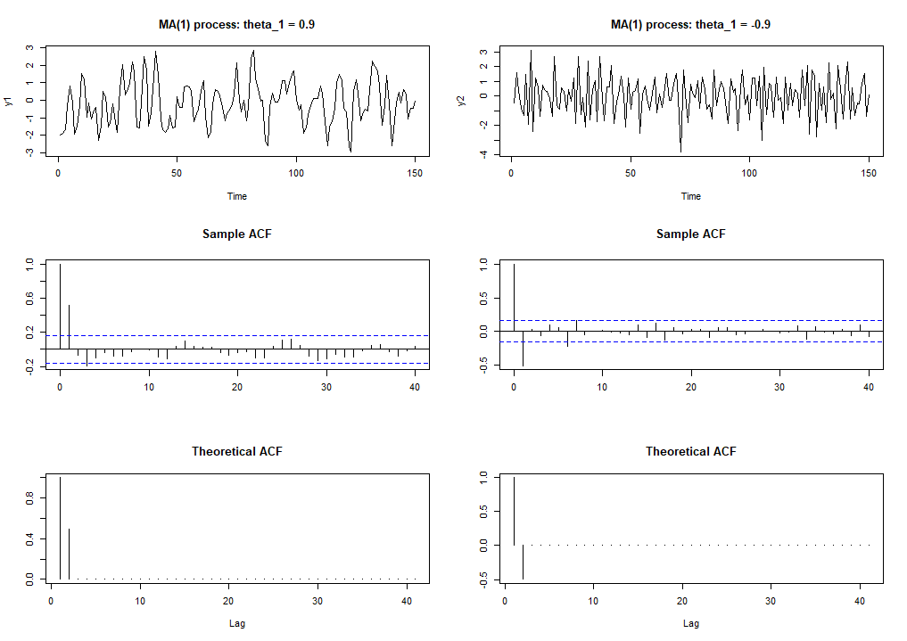

Figure: Two simulated realizations of the MA(1) process.

In Figure, on the left, the MA(1) coefficient $\theta_1$ is 0.9, on the right $\theta_1= -0.9$. In addition to simulated time series, the figure plots sample autocorrelations (“sample ACF”) and theoretical autocorrelations (“theoretical ACF”) of these two processes. In these figures $\mathsf{r}_0=1$ are depicted.

The figure above shows that in both simulated series, the observations vary around their mean (zero) according to their theoretical standard deviation ($\approx1.345$).

- In the left panel, the series has positive autocorrelation, which manifests itself as positive observations, typically followed by another positive observation.
- In the right panel, due to negative autocorrelation, positive and negative observations typically alternate.

The estimated sample autocorrelation functions resemble rather closely their theoretical counterparts. In particular, in both cases, the estimated $\mathsf{r}_{1}$ is well outside the approximate 95% confidence bands implied by the assumption $\rho_{h}=0$ $\left( \forall h>0\right)$. The remaining estimated sample autocorrelations fall mostly within these bands.

- Due to random variation, some of the remaining 39 estimates may naturally occasionally fall outside these bands.
- Furthermore, as we will discuss later, in the case of an MA(1) process, the confidence bands used above are actually too narrow.

An obvious generalization of the MA(1) is obtained by adding a linear combination of the variables $u_{t-2},\ldots,u_{t-q}$ $\left(q<\infty\right)$ to the right hand side of the MA(1). This leads to the so called MA($q$) process and to be considered more detail in Section 5.

## 4.2 Causal linear process

The MA(1) process introduced in the previous section, and its generalization the MA($q$) process ($q$ $<\infty$) to be introduced later on, are special cases of the **linear process**
$$\begin{equation*}
y_{t} = \mu + \sum_{j=-\infty}^{\infty}\psi_{j}u_{t-j}, \quad u_{t}\sim\mathsf{iid}\left(0,\sigma^{2}\right).
\end{equation*}$$
It is clear that the infinite sum on the right hand side of this equation requires further care and can not be well defined without suitable further restrictions on the coefficients $\psi_{j}$.

- We will assume that
  $$\begin{equation*}
  \sum_{j=-\infty}^{\infty}\psi_{j}^{2}<\infty.
  \end{equation*}$$
  Under this assumption the infinite sum on the right hand side of the linear process is well defined.

The mean and autocovariance function of $y_{t}$ (general linear process) can be calculated in a similar fashion as for the MA(1) process regardless of the infinite sum:
$$\begin{equation*}
\mathsf{E}\left(y_{t}\right) = \mu + \sum_{j=-\infty}^{\infty}\mathsf{E}\left(\psi_{j}u_{t-j}\right)=\sum_{j=-\infty}^{\infty}\psi_{j}\mathsf{E}\left(u_{t-j}\right)=\mu,
\end{equation*}$$
and denoting (cf. deterministic components section) $z_t \equiv y_t - \mu$, we get
$$\begin{equation*}
\mathsf{Var}\left(y_{t}\right)= \mathsf{Var}\left(z_{t}\right) =\sum_{j=-\infty}^{\infty}\mathsf{Var}\left(\psi_{j}u_{t-j}\right)=\sum_{j=-\infty}^{\infty}\psi_{j}^{2}\mathsf{Var}\left(u_{t-j}\right)=\sigma^{2}\sum_{j=-\infty}^{\infty}\psi_{j}^{2}.
\end{equation*}$$
Moreover, for $h>0$,
$$\begin{eqnarray}
\mathsf{Cov}\left(y_{t},y_{t+h}\right) &=& \mathsf{Cov}\left(z_{t},z_{t+h}\right) \\ &=& \mathsf{E}\left(\sum_{j=-\infty}^{\infty}\psi_{j}u_{t-j}\sum_{i=-\infty}^{\infty}\psi_{i}u_{t+h-i}\right) \\
&=& \sum_{j=-\infty}^{\infty}\sum_{i=-\infty}^{\infty}\mathsf{E}\left(\psi_{j}\psi_{i}u_{t-j}u_{t+h-i}\right) \\
&=& \sum_{j=-\infty}^{\infty}\sum_{i=-\infty}^{\infty}\psi_{j}\psi_{i}\mathsf{E}\left( u_{t-j}u_{t+h-i}\right) \\
&=& \sigma^{2}\sum_{j=-\infty}^{\infty}\psi_{j}\psi_{j+h},
\end{eqnarray}$$
where the calculations also make use of the properties of the process $u_{t}$ (compare the results for the MA(1) process). These calculations show that $y_{t}$ is weakly stationary.

- Notice that the strict stationarity follows from the strict stationarity of $u_{t}$ and the property SS4.

**Causal linear (MA($\infty$)) process**. Because the linear process defined above contains an infinite number of unknown parameters (the $\psi_{j}$’s), it cannot be used in practice to obtain a useful statistical model unless we place some further restrictions on $\psi_{j}$.

- Despite this, the general linear model is a useful theoretical device because many processes used in practice are special cases of it.

Like in the case of an MA(1) process, it typically holds that $\psi_{j}=0$ for $j<0$, in which case the general linear process reduces to
$$\begin{equation*}
y_{t} = \mu + \sum_{j=0}^{\infty}\psi_{j}u_{t-j}, \quad u_{t}\sim\mathsf{iid}\left(0,\sigma^{2}\right).
\end{equation*}$$
Because $y_{t}$ no longer depends on future values of the $u_{t}$ variables, one often speaks of a **causal linear process** or a **causal MA($\infty$) process**.

- The values of the process $y_{t}$ are assumed to be generated as a weighted sum of (possibly) infinitely many independent and unobserved random shocks.
- In the **noncausal case** the future shocks $u_{t+j}$ $\left(j>0\right)$ affect the present value of the process $y_{t}$. In this course, we do not consider noncausal models more detail.

## 4.3 AR(1) process

A simple special case of a causal linear process containing only one unknown parameter (and constant term) is achieved by assuming that $\psi_{j}=\phi_1^{j}$. A process defined like this leads to the autoregressive process of order one, that is an **AR(1) process**
$$\begin{equation*}
y_{t} = \nu + \phi_1 y_{t-1}+u_{t}, \quad u_{t}\sim \mathsf{iid}\left(0,\sigma^{2}\right).
\end{equation*}$$
Here one interprets the present value of the process to linearly depend on the previous value of the process as well as on an unobseved random shock (or error term) similarly as in the linear process. Furthermore, $\nu$ denotes the constant term of the process, whose connection to the mean $\mathsf{E}(y_t)=\mu$ will be examined below.

- Referring to the linear causal process, for the condition $\sum_{j=-\infty}^{\infty}\psi_{j}^{2}<\infty$ to be satisfied, it needs to assumed that $\left\vert \phi_1\right\vert<1$.

Taking the AR(1) model equation as a starting point, the necessity of condition $\left\vert \phi_1\right\vert <1$ can be demonstrated by making use of repetitive substitutions.

- First, substitute $y_{t-1} = \nu + \phi_1 y_{t-2}+u_{t-1}$ on the right hand side of the AR(1) equation.
- Then substitute $y_{t-2} = \nu + \phi_1 y_{t-3}+u_{t-2}$ to the resulting expression, and so on.

Continuing in this fashion, we obtain the equation
$$\begin{equation*}
y_{t}=\phi_1^{k}y_{t-k} + \nu \sum_{j=0}^{k-1}\phi_1^{j} + \sum_{j=0}^{k-1}\phi_1^{j}u_{t-j}.
\end{equation*}$$
When $\left\vert \phi_1\right\vert<1$, this leads us to the limiting solution
$$\begin{equation*}
y_{t} = \nu \sum_{j=0}^{\infty}\phi_1^{j} + \sum_{j=0}^{\infty}\phi_1^{j}u_{t-j}.
\end{equation*}$$
Because the AR(1) process (with $|\phi_1| < 1$) is clearly a special case of the linear process, it is strictly and weakly stationary when $|\phi_1| < 1$.

The first and second moments can be deduced from the general formulae derived in the previous section. The expected value, variance and autocovariance functions take the form
$$\begin{equation*}
\mathsf{E}\left(y_{t}\right) \equiv \mu = \nu \sum_{j=0}^{\infty}\phi_1^{j} + \mathsf{E}\Big(\sum_{j=0}^{\infty}\phi_1^{j}u_{t-j}\Big) = \nu \sum_{j=0}^{\infty}\phi_1^{j} = \nu / (1-\phi_1),
\end{equation*}$$
$$\begin{equation*}
\mathsf{Var}\left(y_{t}\right)=\sigma^{2}\sum_{j=0}^{\infty}\phi_1^{2j}=\sigma^{2}/\left(1-\phi_1^{2}\right),
\end{equation*}$$
and, for $h>0$,
$$\begin{eqnarray*}
\gamma_h &=& \mathsf{Cov}\left(y_{t},y_{t+h}\right) \\
&=& \sigma^{2}\sum_{j=0}^{\infty}\phi_1^{j}\phi_1^{j+h} \\
&=& \phi_1 \gamma _{h-1} \\
&=& \sigma^{2}\phi_1^{h}/\left(1-\phi_1^{2}\right).
\end{eqnarray*}$$

**The autocorrelation function of the AR(1) process** hence becomes
$$\begin{equation*}
\rho_{h}=\left\{
\begin{array}
[c]{l}
1, \, h=0, \\
\phi_1^{h}, \, h>0.
\end{array}
\right.
\end{equation*}$$
Unlike in the case of an MA(1) process, the autocorrelation function differs from zero for all lags (unless $\phi_1=0$). Note, however, that condition $\gamma_{h}\rightarrow0, \,\, \mathrm{when} \,\, h\rightarrow\infty$ is satisfied.

- Later, we will study a generalization of the AR(1) process, called an AR($p$) process, which is obtained by adding a linear combination of the variables $y_{t-2},\ldots,y_{t-p}, \left(p<\infty\right)$ on the right hand side of the AR(1) process.

In the AR(1) process, the autoregressive parameter $\phi_1$ clearly measures the **persistence** of a random shock to the time series.

- If $\phi_1$ is close to unity in absolute value, autocorrelation is high and the series (process) is strongly “persistent”.
- If $\phi_1$ is close to zero, there is no persistence and the effect of the shock is temporary.

The sign of $\phi_1$ determines whether the time series is positively or negatively autocorrelated.

- If $\phi_1$ is positive, then the positive values of $y_t$ are tending to follow positive values, and similarly with negative values.
- If $\phi_1$ is negative, then positive values tend to follow negative values, and vice versa.

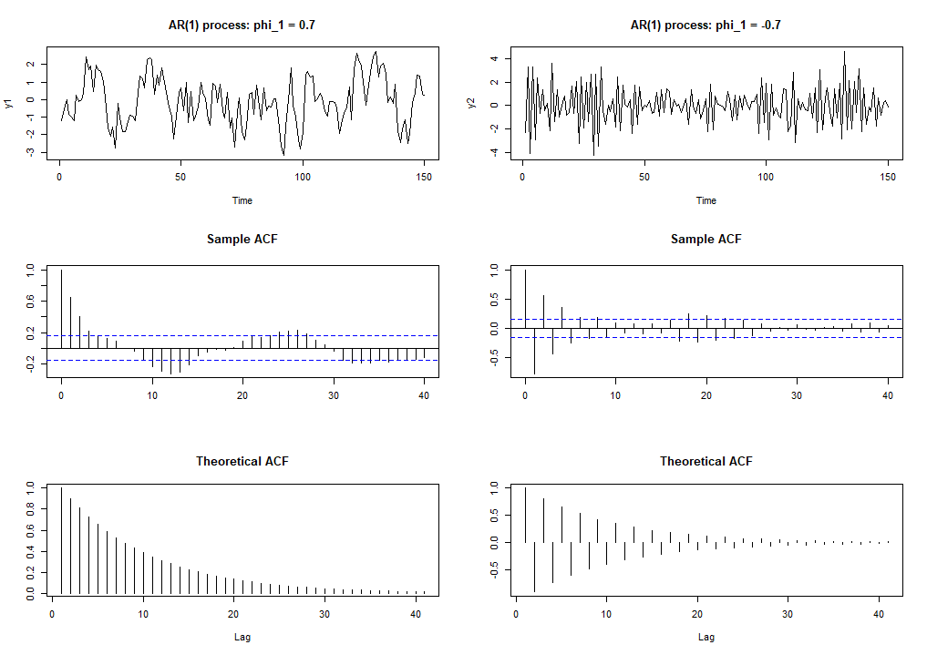

Figure: Two simulated realizations of the AR(1) process.

Figure presents two simulated realizations of length 150 of an AR(1) process with $u_{t}\sim\mathsf{nid}\left(0,1\right)$. On the left, the AR coefficient $\phi_1$ is 0.7, on the right -0.7. For simplicity, the constant term (and hence the mean) is set to 0. In addition to simulated time series, the figure plots sample autocorrelations and theoretical autocorrelations of these two processes.

- As they should be stationary series, the time series vary around their mean (zero) according to their theoretical standard deviation ($\approx1.4$).
- When $\phi_1 = 0.7$ (left), the observations have relatively strong positive autocorrelation and, as a consequence, several consecutive observations occur above the mean, as well as below the mean. This gives the time series a “smooth” flavour.
- When $\phi_1 = -0.7$ (right), the sign of autocorrelation between consecutive observations changes depending on the distance between them. These changes from positive to negative of the autocorrelation coefficients give the observed time series a jagged/zigzag pattern. Moreover, clusters of consecutive observations with small absolute values are also observed (the same for large absolute values).
- In both cases, the estimated sample autocorrelation functions are rather close to their theoretical counterparts. Moreover, several estimated autocorrelation coefficients are outside of the 95% confidence bands based on the assumption of $\rho_{h}=0$ $\left(\forall h>0\right)$.

## 4.4 Random walk

For the AR(1) model, and for any initial value $y_{0}$, we obtain representation (after recursive substitutions)
$$\begin{equation*}
y_{t}=\phi_1^{t}y_{0} + \nu \sum_{j=0}^{t-1}\phi_1^{j} + \sum_{j=0}^{t-1}\phi_1^{j}u_{t-j}, \quad t=1,2,\ldots\text{ }.
\end{equation*}$$
If we assume the initial value $y_{0}$ to be independent of the variables $u_{t}$, $t\geq1$, one can use the assumption $u_{t}\sim\mathsf{iid}\left(0,\sigma^{2}\right)$ to deduce
$$\begin{equation*}
\mathsf{E}\left(y_{t}\right)=\phi_1^{t}\mathsf{E}\left(y_{0}\right) + \nu \sum_{j=0}^{t-1}\phi_1^{j}
\end{equation*}$$
and
$$\begin{eqnarray*}
\mathsf{Var}\left(y_{t}\right) &=& \mathsf{E} \Big(y_t- \mathsf{E}(y_t) \Big)^2 \\
&=& \mathsf{Var}\left(\phi_1^{t}y_{0}\right)+\mathsf{Var}\left(\sum_{j=0}^{t-1}\phi_1^{j}u_{t-j}\right) \\
&=& \phi_1^{2t}\mathsf{Var}\left(y_{0}\right)+\sigma^{2}\sum_{j=0}^{t-1}\phi_1^{2j}.
\end{eqnarray*}$$
When $\left\vert \phi_1\right\vert =1$, the expected value of $y_{t}$, or at least its variance, clearly depends on $t$ regardless of how $y_{0}$ (or its distribution) is chosen.

- In this case, the AR(1) process therefore has no stationary solution.

When $\phi=1$ and $t\geq1$, the AR(1) process reduces to
$$\begin{equation*}
y_{t} = \nu + y_{t-1}+u_{t},\,\, u_{t}\sim \mathsf{iid}\left(0,\sigma^{2}\right).
\end{equation*}$$
This is called a **random walk**. This name is due to the “wandering” nature of the realizations of the process.

- The left panel of figure below illustrates this. For simplicity, we assume here $\nu=0$ (that is the random walk without drift) and $u_t \thicksim \mathsf{nid}(0,1)$.
- The right panel illustrates the obvious fact that the differences $y_{t}-y_{t-1}=u_{t}$ of a random walk $y_{t}=y_{0}+\sum_{j=0}^{t-1}u_{t-j}$ are stationary.

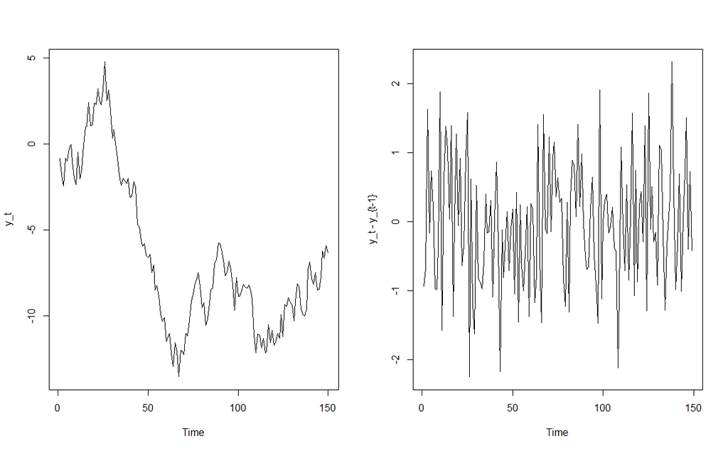

Figure: A simulated realizations of the random walk process (assuming $\mathsf{nid}(0,1)$).

The random walk and its generalizations play a central role in the analysis of **nonstationary time series**. We will come back to this in Sections 12–13.

## 4.5 ARMA(1,1) process

A concept easing the algebraic manipulations of time series processes is the so-called **backshift operator** or **lag operator**. For any process (or simply a sequence of numbers) $x_{t}$, define the operation with the equation $Bx_{t}=x_{t-1}$. More generally, $B^{2}x_{t}=B\left(Bx_{t}\right)=Bx_{t-1}=x_{t-2}$, and inductively define
$$\begin{equation*}
B^{k}x_{t}=B\left(B^{k-1}x_{t}\right)=x_{t-k}, \,\, B^{0}x_{t}=x_{t}.
\end{equation*}$$

- Here $k$ can also be negative, and when $k<0$, the operator becomes a “forward shift” operator, for example $B^{-1}x_{t}=x_{t+1}$, $B^{-2}x_{t}=x_{t+2}$ etc.
- At times backshift or lag operator is denoted by $L^k$ instead of $B^k$.

Using the lag operator, one can also define polynomials.

- For example, $\theta\left(B\right)=1+\theta_1 B$ and, e.g., $\psi\left(B\right)=\sum_{j=-\infty}^{\infty}\psi_{j}B^{j}$).

One can algebraically operate with the lag operator exactly as if $B$ were a real or a complex number.

- For instance, the MA(1) process can be written as
  $$\begin{equation*}
  y_{t}= \mu + u_{t}+\theta_1 u_{t-1} = \theta\left(B\right)u_{t}.
  \end{equation*}$$
- When differencing (some) process $y_{t}$ twice, we obtain
  $$\begin{eqnarray*}
  \left(1-B\right)^{2}y_{t} &=& \left(1-B\right)\left[\left(1-B\right) y_{t}\right] \\
  &=&\left( 1-B\right) \left( y_{t}-y_{t-1}\right) \\
  &=& y_{t}-y_{t-1}-y_{t-1}+y_{t-2} \\
  &=& \left(1-2B+B^{2}\right)y_{t}.
  \end{eqnarray*}$$

Using the lag operator, the general linear process can be defined by the equation
$$\begin{equation*}
y_{t} - \mu = \psi\left(B\right)u_{t}, \quad u_{t}\sim\mathsf{iid}\left(0,\sigma^{2}\right),
\end{equation*}$$
where $\psi\left(B\right)=\sum_{j=-\infty}^{\infty}\psi_{j}B^{j}$. The operator $\psi\left(B\right)$ is sometimes thought as a **linear filter**, which transforms the white noise sequence $\left\{ u_{t}\right\}$ to the process $\left\{y_{t}\right\}$.

- In this context, and especially in the causal case $\psi_{j}=0$, $j<0$, the white noise $u_{t}$ is often called the **innovation** sequence of the process $y_{t}$.

In what follows, we will often consider the special case of the (causal) linear process in which the filter $\psi\left(B\right)$ is rational, that is,
$$\begin{equation*}
\psi\left(B\right)=\sum_{j=0}^{\infty}\psi_{j}B^{j}=\theta\left(B\right)\phi\left(B\right)^{-1},
\end{equation*}$$
where $\phi\left(B\right)$ and $\theta\left(B\right)$ are polynomials of finite order. In the simplest case, these polynomials are of order one so that
$$\begin{equation*}
\phi\left(B\right)=1-\phi_1 B \quad \mathrm{and} \quad \theta\left(B\right)=1+\theta_1 B.
\end{equation*}$$

- It is clear that to obtain stationarity, some restrictions have to be placed on the coefficients of the polynomial $\phi\left(B\right)$.

Based on our discussion on the AR(1) process above, it is clear that in the first-order case a sufficient condition is that $\left\vert \phi_1\right\vert <1$. Then the condition $\sum_{j=-\infty}^{\infty}\psi_{j}^{2}<\infty$ attached to the linear process is satisfied and the process
$$\begin{equation*}
y_{t}-\mu =\left[\theta\left(B\right)\phi\left(B\right)^{-1}\right] u_{t}
\end{equation*}$$
is well defined. Multiplying both sides of this equation with the polynomial $\phi\left(B\right)$, we obtain the representation
$$\begin{equation*}
\phi\left(B\right) (y_{t}-\mu) = \theta\left(B\right)u_{t}
\end{equation*}$$
or
$$\begin{equation*}
y_{t} = \nu + \phi_1 y_{t-1}+u_{t}+\theta_1 u_{t-1}, \quad u_{t}\sim\mathsf{iid}\left(0,\sigma^{2}\right),
\end{equation*}$$
where $\nu = \phi\left(1\right) = 1- \phi_1$ (see the properties of the backshift operator). A process defined like this is called the **autoregressive moving average process of order one**, or the **ARMA(1,1) process**.

- This combines the AR(1) and MA(1) processes introduced earlier, and these processes can still be obtained as special cases.
- Later we will study a generalization of this process called the ARMA($p,q$) process, which can be obtained by generalizing ARMA(1,1) in a similar fashion as discussed around AR(1) and MA(1) processes.
- The coefficients $\psi_j$ of the filter $\psi\left(B\right)=\sum_{j=0}^{\infty}\psi_{j}B^{j}$ can be solved fairly straightforwardly from equation $\psi\left(B\right)=\theta\left(B\right)\phi\left(B\right)^{-1}$.

The above shows that the autocorrelation function of an ARMA(1,1) process can then be derived by applying the general formulas obtained for the general linear process. Details of these calculations are left as exercises.

## 4.6 Wold decomposition

The following famous result (named after Herman Wold) shows that every weakly stationary non-deterministic process can be expressed as a sum of a deterministic process and a causal MA$\left(\infty\right)$ process (the proof of this result is beyond the scope of this course and omitted). In other words, every weakly stationary non-deterministic process $y_{t}$ ($t=0,\pm1,\pm2,\ldots$) has a representation
$$\begin{equation*}
y_{t} = \sum_{j=0}^{\infty}\psi_{j}u_{t-j}+\upsilon_{t},
\end{equation*}$$
where

- $\mathrm{(i)}$ $\psi_{0}=1$, $\sum_{j=0}^{\infty}\psi_{j}^{2}<\infty$,
- $\mathrm{(ii)}$ $u_{t}\sim\mathsf{wn}\left(0,\sigma^{2}\right)$,
- $\mathrm{(iii)}$ $\upsilon_{t}$ is deterministic, and
- $\mathrm{(iv)}$ $\mathsf{Cov}\left( u_{t},\upsilon_{s}\right)=0$ for all $t$ and $s$. $\square$

Part (iii) means that the process $\upsilon_{t}$ can be predicted linearly using the variables $y_{t-1}, y_{t-2},\ldots$, with no error. This and part (ii) together imply that $u_{t}$ can be interpreted as a forecast error when forecasting $y_{t}$ linearly using the lags of $y_t$.

- In the case $\upsilon_{t}=0$ the process $y_{t}$ is called *purely non-deterministic*.

When, as in practice, only one realization of the process $y_{t}$ is observed, the process $\upsilon_{t}$ can therefore be treated as a non-random function of time (it can be perfectly predicted using the realized values of $y_{t-1},y_{t-2},\ldots$, so only remaining variation should be non-random). Modelling $\upsilon_{t}$ can thus be thought as modelling a trend as discussed in the introduction.

- A simple example of a process $\upsilon_{t}$ is that it is constant. Such a realization of $\upsilon_{t}$ can in practice be interpreted as the expected value of process $y_{t}$, $\mu$, or at least be included in it.

The task of modelling a weakly stationary process reduces to the task of modelling the linear filter $\psi\left(B\right)=\sum_{j=0}^{\infty}\psi_{j}B^{j}$.

- Furthermore, in the case of the ARMA($p,q$) processes to be investigated shortly, this means assuming that the filter $\psi\left(B\right)$ is rational, or in other words that $\psi\left(B\right)=\theta\left(B\right)\phi\left(B\right)^{-1}$, where $\phi\left(B\right)$ is a polynomial of order $p$ and $\theta\left(B\right)$ is a polynomial of order $q$.

As a remark, we note that the significance of the Wold decomposition should be evaluated keeping in mind that it concerns weakly stationary processes and linear forecasting. Although every weakly stationary process can be represented by the Wold decomposition, this does not mean that the decomposition is the best way to describe the process. There exist (strictly) stationary processes for which linear prediction is not optimal (in the sense of minimising mean-square forecast error).

## 4.7 Properties of sample mean and autocorrelations

Because the sample mean and the sample autocorrelation function are central tools in the analysis of time series, we next briefly discuss some of the statistical properties.

We can show that (see below) that the **sample mean**
$$\begin{equation*}
\bar{y}=\frac{1}{T}\left(y_{1}+\cdots+y_{T}\right)
\end{equation*}$$
is

- **unbiased** and **consistent estimator** of the population mean $\mu=\mathsf{E}\left(y_{t}\right)$, and
- **asymptotically normally distributed**

The statistical properties of the sample autocorrelation coefficients $\mathsf{r}_{h}=\mathsf{c}_{h}/\mathsf{c}_{0}$ are more complicated to derive than those of the sample mean, so we will not attempt to provide any detailed justifications. Under “reasonably general assumptions”, consistency and asymptotic normality of them can be established.

**Important special case**: For the important special case of $y_{t}\sim\mathsf{iid}\left(\mu,\sigma^{2}\right)$, it holds that
$$\begin{equation*}
\left(\mathsf{r}_{1},\ldots,\mathsf{r}_{H}\right)\underset{as}{\sim}\mathsf{N}\left(\boldsymbol{0},T^{-1}\boldsymbol{I}_{H}\right),
\end{equation*}$$
with a $H$-dimensional zero mean vector and $\boldsymbol{I}_{H}$ $\left(H\times H\right)$ denotes an identity matrix. This result can be used to test whether it is realistic to consider an observed time series as an uncorrelated time series process. Under the hypothesis to be tested (uncorrelatedness), the estimators $\mathsf{r}_{1},\ldots.,\mathsf{r}_{H}$ are approximately independent with distribution $\mathsf{N}\left(0,T^{-1}\right)$. Based on this, we get
$$\begin{equation*}
\mathsf{P}(\left\vert \mathsf{r}_{h}\right\vert \geq1.96/\sqrt{T})\approx 0.05,
\end{equation*}$$
a result that can be used to evaluate the significance of individual sample autocorrelation coefficients.

To obtain a joint test for several autocorrelation coefficients, one can use the test statistic
$$\begin{equation*}
Q=T\sum_{h=1}^{H}\mathsf{r}_{h}^{2}\underset{as}{\sim}\chi_{H}^{2},
\end{equation*}$$
whose large values would lead to rejection. Note that the asymptotic $\chi_{H}^{2}$–distribution follows from the distribution result above for $\left(\mathsf{r}_{1},\ldots,\mathsf{r}_{H}\right)$ and the definition of the chi-squared distribution. In practice, an alternative and slightly different test statistic
$$\begin{equation*}
Q_{{\tiny LB}}=T\left(T+2\right)\sum_{h=1}^{H}\mathsf{r}_{h}^{2}/\left(T-h\right)\underset{as}{\sim}\chi_{H}^{2},
\end{equation*}$$
called the **Ljung-Box test statistic** is preferred because in small samples its distribution has been found to be closer to the $\chi_{H}^{2}$–distribution than that of the test statistic $Q$. It should be clear that both tests need $H$ not to be too large compared to $T$ to work well.

The autocorrelation function can be used to reveal linear dependences between the observations, but not nonlinear ones (with the exception of Gaussian processes). To investigate the presence of potential nonlinear dependence over time, one (somewhat limited) approach is to test for autocorrelation in the squared observations.

- Assuming $y_{t}\sim\mathsf{iid}\left(\mu,\sigma^{2}\right)$ and $\mathsf{E}\left( y_{t}^{4}\right)<\infty$, what was said above about the sample autocorrelations also holds for sample autocorrelations computed from the squared observations $y_{t}^{2}$. In particular, the asymptotic result(s) remain valid when the autocorrelations are computed from squared observations, and also the Ljung-Box test has its indicated asymptotic distribution. In this context, however, the test is usually called the **McLeod-Li test**.
- Investigating the autocorrelations between squared observations is of great interest, especially in the case of financial time series, which themselves often are uncorrelated. We will return to this point later.

As an empirical illustration, let us consider the quarterly U.S. real GDP growth rate. It turns out that we obtain the following results from the Ljung-Box test for different lag lengths $H$:

```markdown
| Lag | Q_{LB}  | p.value |
|-----|---------|---------|
| 4   | 16.487  | 0.002   |
| 8   | 19.494  | 0.012   |
| 12  | 27.942  | 0.006   |
| 16  | 32.897  | 0.008   |
| 20  | 34.679  | 0.022   |
```

## 4.8 R Lab

# 5 ARMA processes

## 5.1 AR($p$) process

Earlier, we considered the AR(1) process. This can be generalized to the **AR($p$) process**
$$\begin{equation*}
y_{t} = \nu + \phi_{1}y_{t-1}+\cdots+\phi_{p}y_{t-p}+u_{t}, \quad u_{t}\sim\mathsf{iid}\left(0,\sigma^{2}\right),
\end{equation*}$$
which can be rewritten
$$\begin{equation*}
\phi\left(B\right) (y_{t}- \mu) = u_{t},
\end{equation*}$$
with the lag-polynomial $\phi\left(B\right)=1-\phi_{1}B-\cdots-\phi_{p}B^{p}$. The current value of the process hence depends linearly on $p$ past values of the process and the constant term, as well as on an unobserved random shock (or error term or *innovation*).

- Notice that $\phi\left(B\right) \mu \equiv \phi\left(1\right) \mu \equiv \nu$.

**A sufficient condition for the stationarity of an AR($p$) process**. A sufficient condition for the stationarity of the AR($p$) process is that the roots of the polynomial $\phi\left(z\right)$ $\left(z\in \mathbb{C}\right)$ lie outside the unit circle/disk in the complex plane, or equivalently that
$$\begin{equation*}
\phi\left(z\right)\neq 0 \,\, \mathrm{for}\,\, \left\vert z\right\vert \leq1.
\end{equation*}$$

- As an example, in the stationary AR(1) case ($|\phi_1| < 1)$, the characteristic equation yields $\phi(z)=0 \Leftrightarrow 1-\phi _{1}z = 0$ when $|z| > 1$. This shows why in the case $p=1$, the condition $\left\vert \phi_{1}\right\vert<1$ was found sufficient to ensure the existence of a (causal) stationary MA($\infty$) representation.
- Notice that the resulting root (roots) can also be complex numbers. Related to the above stationarity condition, the absolute value or norm of a complex number $z=x+iy$ $\left(i=\sqrt{-1}\right)$ is defined as $\left\vert z\right\vert=\sqrt{x^{2}+y^{2}}$. The latter form of the stationarity condition can be further expressed as $\phi\left(z\right) =0\Rightarrow\left\vert z\right\vert>1$.
- Still about possible complex roots: Because the coefficients of the polynomial $\phi\left(z\right)$ are real numbers, the potential complex roots always appear as conjugate roots, that is, if $\zeta=x+iy$ is a root, then also $\bar{\zeta}=x-iy$ is a root.

Based on the above-mentioned, a stationary AR($p$) process has an MA$\left(\infty\right)$ representation
$$\begin{equation*}
(y_{t}- \mu)=\phi \left(B\right)^{-1}u_{t}=\psi \left(B\right)u_{t}=\sum_{j=0}^{\infty}\psi_{j}u_{t-j},
\end{equation*}$$
where $\psi\left(B\right) =\sum_{j=0}^{\infty}\psi_{j}B^{j}=\phi\left(B\right)^{-1}$. The coefficients $\psi_{j}$ can be solved as a function of the parameters $\phi_{1},\ldots,\phi_{p}$ from equation
$$\begin{equation*}
\left(1-\phi_{1}B-\cdots-\phi_{p}B^{p}\right) \left(\psi_{0}+\psi_{1}B+\psi_{2}B^{2}+\cdots \right)=1
\end{equation*}$$
by interpreting the right hand side as a power series in $B$, and setting the coefficients of $B^{j}$ equal to each other on both sides of the equation.

- Recall that two polynomials are the same if their coefficients are the same.
- For instance, the coefficient of $B^{0}$ is 1, so that $\psi_{0}=1$. Next, the coefficient of $B^{1}$ is zero, so that $\psi_{1}-\phi_{1}\psi_{0}=0$ from which $\psi_{1}=\phi_{1}$ follows. The general solution is left as an exercise.

**Autocorrelation function**. The autocorrelation function of an AR($p$) process could be derived by making use of its MA$\left(\infty\right)$ representation. Instead, we present an often used and rather practical alternative approach based on the AR($p$) model equation.

Multiplying both sides of the demeaned AR($p$) process presentation with $y_{t-h}-\mu$ $\left(h\geq0\right)$ and taking expectations, we obtain
$$\begin{equation*}
\mathsf{E}\Big((y_{t}-\mu)(y_{t-h}-\mu)\Big) =\phi_{1}\mathsf{E}\Big((y_{t-1}-\mu) (y_{t-h}-\mu)\Big)+\cdots+\phi_{p}\mathsf{E}\Big((y_{t-p}-\mu)(y_{t-h}-\mu)\Big) +\mathsf{E}\Big(u_{t}(y_{t-h}-\mu)\Big).
\end{equation*}$$
Because $y_{t-h}$ (and likewise $y_{t-h}-\mu$) is a linear function of the innovation terms $u_{t-h},$ $u_{t-h-1},\ldots$, the variables $y_{t-h}$ and $u_{t}$ are independent when $h>0$. Therefore, we get

- $\mathsf{E}\Big(u_t (y_{t-h}-\mu)\Big)=0, \quad h>0$,
- For $h=0$, it can be seen that $\mathsf{E}\Big(u_{t}(y_{t}-\mu)\Big)=\mathsf{E}\left(u_{t}^{2}\right) =\sigma^{2}$.

As $\gamma_{h}=\gamma_{-h}$, we get
$$\begin{equation*}
\gamma_{h}=\left\{
\begin{array}
[c]{l}
\phi_{1}\gamma_{1}+\cdots+\phi_{p}\gamma_{p}+\sigma^{2},\,\, h=0\\
\phi_{1}\gamma_{h-1}+\cdots+\phi_{p}\gamma_{h-p},\,\, h > 0.
\end{array}
\right.
\end{equation*}$$
Dividing this (in the case $h>0$) with the variance $\gamma_{0}$ leads to the autocorrelation function of an AR($p$) process
$$\begin{equation*}
\rho_{h}=\phi_{1}\rho_{h-1}+\cdots+\phi_{p}\rho_{h-p}, \quad h>0,
\end{equation*}$$
so that it satisfies a difference equation similar to the one the AR($p$) process itself satisfies.

- When the roots of $\phi\left(z\right)$ lie outside the unit disk on the complex plane, the solution $\rho_{h}$ to this difference equation decays exponentially to zero as the lag length $h$ increases.
- The solution $\phi_{1}^{h}$ for the AR(1) is an example of this (this solution can also be easily obtained by solving the difference equation above in the case $p=1$ using the initial value $\rho_{0}=1$).

**Partial autocorrelation function**. We next define the partial autocorrelation function, which is, among other things, a useful tool for model selection. In general, $\alpha_h$ equals the conventional partial correlation coefficient that measures the correlation between the random variables $y_t$ and $y_{t-h}$ when the linear effect of the random variables $y_{t-1}, \ldots, y_{t-h+1}$ has been first eliminated.

- Therefore, a particular consequence is that $\left\vert \alpha_{h}\right\vert\leq1$.

In the case of an AR($p$) process, the **partial autocorrelation function $\alpha_h$ has a special useful feature**. For $m>p$, an AR($p$) process can be interpreted as an AR($m$) process with $\phi_{p+1}=\cdots=\phi_{m}=0$, which makes it clear that the partial autocorrelation function of an AR($p$) process satisfies (also $\alpha_0=1$):
$$\begin{equation*}
y_t \thicksim \mathrm{AR}(p) \Rightarrow \alpha_p = \phi_p \quad
\mathrm{and} \quad \alpha_h=0 \,\, \mathrm{for}\,\, h > p.
\end{equation*}$$
In other words, **the partial autocorrelation function of an AR($p$) process drops to zero after lag $p$** (assuming $\phi_p \neq 0$).

- The sample counterpart of the (population) partial autocorrelation function is obtained by using sample autocovariances $c_h$.
- The (sample) partial autocorrelation function can generally be based on the Yule-Walker equations (see details below in the Extra section).

An important detail for model selection is that if an observed time series has been generated by an AR($p$) process, its estimated autocorrelation function should decay to zero as the lag length increases **with no apparent breaks**, whereas the estimated partial autocorrelation function should have **a visible break after lag $p$**.

To identify the location of the break point in the estimated partial autocorrelation function, one can make use of the following result:

- In the case of an AR($p$) process, the estimators $\widehat{\alpha}_{h}$, $h>p$, are approximately independent with $\mathsf{N}\left(0,T^{-1}\right)$–distribution. Therefore,
  $$\begin{equation*}
  \mathsf{P}(\left\vert \widehat{\alpha}_{h}\right\vert \geq1.96/\sqrt{T})\approx0.05
  \end{equation*}$$
  when $h>p$.
- On the other hand, because the estimators $\mathsf{c}_{1},\ldots,\mathsf{c}_{p}$ are consistent, the estimator $\widehat{\alpha}_{p}$ converges in probability to the value of the theoretical partial autocorrelation coefficient $\alpha_{p}$ which for an AR($p$) process is nonzero. Therefore, for $h=p$, $\mathsf{P}(\left\vert \widehat{\alpha}_{h}\right\vert \geq1.96/\sqrt{T})$ approaches one as the sample size increases.
- These remarks justify depicting the sample partial autocorrelation coefficients similar to that of the usual autocorrelation coefficients, and adding to it horizontal critical/confidence bands to make its interpretation easier.

**Empirical example**. As an example, below we present the estimated sample partial autocorrelation functions (with lag lengths $h=0,\ldots,20$) of the quarterly U.S. real GDP growth series, together with the above-mentioned critical/confidence bands.

- The corresponding sample autocorrelation functions are shown already above.
- The first two sample partial autocorrelation coefficients $\widehat{\alpha}_{1}$ and $\widehat{\alpha}_{2}$ are clearly outside the confidence bands, whereas the rest lie within these bands (except 11th lag), suggesting an AR(2) process. The sample autocorrelation function partly supports this conclusion, while also MA(2) or some ARMA model might clearly be potential candidate for the GDP growth.
- We are coming back to empirical model selection later in this material.

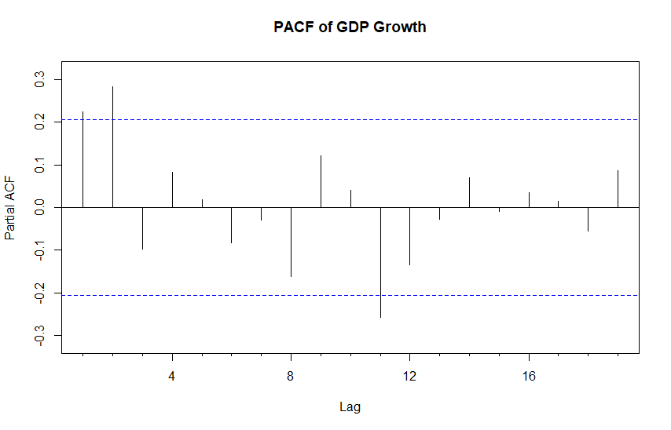

Figure: Sample partial autocorrelation function (PACF) of the U.S. quarterly real GDP growth rate.

## 5.2 MA($q$) process and invertibility

The MA($q$) process is defined as
$$\begin{equation*}
y_{t} = \mu + u_{t}+\theta_{1}u_{t-1}+\cdots+\theta_{q}u_{t-q}, \quad u_{t}\sim\mathsf{iid}\left(0,\sigma^{2}\right),
\end{equation*}$$
or alternatively using the lag operator as
$$\begin{equation*}
(y_{t}-\mu)=\theta\left(B\right)u_{t},\,\, u_{t}\sim\mathsf{iid}\left(0,\sigma^{2}\right)
\end{equation*}$$
with the lag-polynomial $\theta\left(B\right)=1+\theta_{1}B+\cdots+\theta_{q}B^{q}$. Therefore, the current value of the process is assumed to depend linearly on the present and last $q$ unobservable random shocks (error terms or innovations). Because an MA($q$) process is a special case of the (causal) linear process, it is always both weakly and strictly stationary. Moreover, we get

- $\mathsf{E}\left( y_{t}\right) = \mu$,
- $\mathsf{Var}\left( y_{t}\right) =\gamma _{0}=\left( 1+\theta _{1}^{2}+\cdots +\theta _{q}^{2}\right) \sigma^{2}$.

**Autocorrelation function**. By making use of the general results of linear process, the MA($q$) process has the autocovariance function given by
$$\begin{equation*}
\gamma_{h}=
\begin{cases}
\sigma^{2}\sum_{j=0}^{q-h}\theta_{j}\theta_{j+h}, & \text{for } \, 0\leq h\leq q,\\
0, & \text{for } \, h>q,
\end{cases}
\end{equation*}$$
where $\theta_0=1$. The autocorrelation function is then obtained via the formula $\rho_{h}=\gamma_{h}\gamma_{0}$.

- Therefore, the autocorrelation function of an MA($q$) process drops to zero after lag $q$ (assuming that $\theta_{q}\neq0$).
- If one observes a similar feature in a sample autocorrelation function, one can consider an MA($q$) process as a good candidate to model the time series.

When considering the suitability of an MA($q$) process, one can make use of the following result: In the case of an MA($q$) process, the estimators $\mathsf{r}_{h}$, $h>q$, are approximately normally distributed with mean zero and variance $\left(1+2\rho_{1}^{2}+\cdots+2\rho_{q}^{2}\right)T$. Therefore, if one wants to test whether an individual autocorrelation coefficient is statistically different from zero at the 5% significance level, the estimates $\mathsf{r}_{h}$, $h>q$, should be compared with the critical bounds
$$\begin{equation*}
\pm1.96\sqrt{\mathsf{\widehat{w}}_{q}/T}, \quad \mathsf{\widehat{w}}_{q}=\left(1+2\mathsf{r}_{1}^{2}+\cdots+2\mathsf{r}_{q}^{2}\right).
\end{equation*}$$
In this case, $\mathsf{P}(\left\vert \mathsf{r}_{h}\right\vert \geq1.96\sqrt{\mathsf{\widehat{w}}_{q}/T})\approx0.05$. Note also that the bounds above are wider than in the case $y_{t}\sim\mathsf{iid}\left(0,\sigma^{2}\right)$ when $\mathsf{\widehat{w}}_{q}$ is replaced by $1$.

**Invertibility**. It can be shown that in a (causal) AR($p$) process there exists a one to one correspondence between the parameters $\boldsymbol{\phi}=(\phi_1,\ldots,\phi_p)$ and $\sigma^{2}$, and the autocovariance function. For an MA($q$) process, a similar result does not hold.

- To see this, consider as an example the MA(1) process for which it holds that (assume that $\theta_1 \neq0$)
  $$\begin{equation*}
  \gamma_{0}=\sigma^{2}\left(1+\theta_1^{2}\right)=\sigma^{2}\theta_1^{2}\left(1+1/\theta_1^{2}\right) \,\, \mathrm{and} \,\, \gamma_{1}=\sigma^{2}\theta_1=\theta_1^{2}\sigma^{2}\left(1/\theta_1\right)\text{.}
  \end{equation*}$$
  Define $\theta_1^{\ast}=1/\theta_1$ and $\sigma_{\ast}^{2}=\theta_1^{2}\sigma^{2}$, so that $u_{t}^{\ast}=\theta_1u_{t}\sim\mathsf{iid}\left(0,\sigma_{\ast}^{2}\right)$. Now, it can be seen that the two MA(1) processes $y_{t}=u_{t}+\theta_1 u_{t-1}$ and $y_{t}^{\ast}=u_{t}^{\ast}+\theta_1^{\ast}u_{t-1}^{\ast}$ have exactly the same autocovariance function, so that they cannot be distinguished from each other based on autocovariances.
- If in addition $u_{t}\sim\mathsf{nid}\left( 0,\sigma^{2}\right)$, the entire probability structures of these two processes are indistinguishable.
- A consequence is that estimating the parameters based on an observed time series, unless one “tells” the method which of the parameter combinations $\left(\theta_1,\sigma^{2}\right)$ and $\left( \theta_1^{\ast},\sigma_{\ast}^{2}\right)$ (that fit the data equally well) should be chosen.

The typical solution to the above problem is to set the condition $\left\vert \theta_1\right\vert <1$. When one assumes $\left\vert \theta_1\right\vert<1$ in an MA(1) process, one can use the equation $u_{t}=y_{t}-\mu - \theta_1 u_{t-1}$ and repetitive substitutions to first obtain $u_{t}=y_{t}-\mu -\theta_1 (y_{t-1}-\mu) +\theta_1^{2}u_{t-2}$, and eventually
$$\begin{equation*}
(y_{t}-\mu)=-\sum_{j=1}^{k}\left(-\theta_1\right)^{j}(y_{t-j}-\mu)-\left(-\theta_1\right)^{k+1}u_{t-k-1}+u_{t}.
\end{equation*}$$
Similarly as when considering the stationarity of an AR(1) process, it can be concluded, given that the condition $\left\vert \theta_1\right\vert <1$,
$$\begin{equation*}
y_{t} -\mu =-\sum_{j=1}^{\infty}\left(-\theta_1\right)^{j} (y_{t-j}-\mu) + u_{t}.
\end{equation*}$$
That is, when $\left\vert \theta_1 \right\vert<1$ holds, an MA(1) process can be “inverted” to an AR$\left(\infty\right)$ process, which explains why in the case $\left\vert \theta_1\right\vert<1$ an MA(1) process is called **invertible**.

An alternative way to express the invertibility condition of an MA(1) process is to require that the root of the polynomial $\theta\left(z\right)$ (that is, the solution to the equation $\theta\left( z\right) =0$) is greater than one in absolute value, or in other words, that
$$\begin{equation*}
\theta\left(z\right) \neq0 \,\, \mathrm{for} \,\, \left\vert z\right\vert \leq1.
\end{equation*}$$
Similarly as in the case of the stationarity condition of an AR($p$) process, this condition ensures invertibility (that is, the existence of an AR$\left(\infty\right)$ representation also for MA($q$) processes).

**Invertibility condition of an MA($q$) process** . An MA($q$) process is invertible, if the roots of the polynomial $\theta\left(z\right)$ $\left(z\in\mathbb{C}\right)$ lie outside the unit circle/disk on the complex plane or, equivalently, if
$$\begin{equation*}
\theta\left(z\right) \neq0 \,\,\, \mathrm{for} \,\,\, \left\vert z\right\vert\leq1.
\end{equation*}$$

When the invertibility condition holds, one can formally solve $u_{t}$ from equation $(y_{t}-\mu)=\theta\left(B\right)u_{t}$ by dividing both sides by the polynomial $\theta\left(B\right)^{-1}$. The solution is
$$\begin{equation*}
\pi\left(B\right)(y_{t}-\mu) = u_{t} \,\,\, \mathrm{or} \,\,\, \sum_{j=0}^{\infty}\pi_{j}(y_{t-j}-\mu)=u_{t},
\end{equation*}$$
where $\pi\left(B\right)=\sum_{j=0}^{\infty}\pi_{j}B^{j}=\theta\left(B\right)^{-1}$ and the coefficients $\pi_{j}$ can be solved as a function of the parameters $\theta_{1},\ldots,\theta_{q}$ from the equation
$$\begin{equation*}
\left(1+\theta_{1}B+\cdots+\theta_{q}B^{q}\right) \left(\pi_{0}+\pi_{1}B+\pi_{2}B^{2}+\cdots\right)=1
\end{equation*}$$
by interpreting the right hand side as a power series in $B$, setting the coefficients of $B^{j}$ equal on both sides of the equation (and $\pi_{0}=1$).

As in the MA(1) case, invertibility ensures that there exists a one to one correspondence between the autocovariance function of an MA($q$) process and the parameters $\boldsymbol{\theta}=\left(\theta_{1},\ldots,\theta_{q}\right)$ and $\sigma^{2}$.

- Except for the first-order case, this correspondence is rather complicated, and we omit the details.
- In what follows (unless otherwise mentioned), MA processes are always assumed to be invertible.

**Partial autocorrelation function**. The general definition of a partial autocorrelation function presented in the previous subsection can also be applied in the case of an MA($q$) process, but the calculations involved would become rather complicated. However, because an MA($q$) process has (due to invertibility and assuming here $\theta_{q}\neq0$) an AR($\infty$) representation, and based on what was said above about the partial autocorrelation function of an AR($p$) process, it is intuitively clear that the partial autocorrelation function of an MA($q$) process does not drop to zero at any point, but rather smoothly decays towards zero.

- It can be shown that the the partial autocorrelation function of an MA(1) process is
  $$\begin{equation*}
  \alpha_{h}=-\left(-\theta_{1}\right)^{h}/\left(1+\theta_{1}^{2}+\cdots+\theta_{1}^{2h}\right).
  \end{equation*}$$
  Because $\left\vert \theta_{1}\right\vert<1$, the partial autocorrelation function of an MA(1) process decays to zero at an exponential rate as the lag length $h$ increases.
- For a general MA($q$) process, it can be shown that the partial autocorrelation function decays to zero at an exponential rate, potentially following the shape of a dampening sine wave.

## 5.3 ARMA($p,q$) process

An ARMA($p$,$q$) process can be characterized as a combination of AR($p$) and MA($q$) processes. It is defined by the equation
$$\begin{equation*}
y_{t} = \nu + \phi_{1}y_{t-1}+\cdots+\phi_{p}y_{t-p}+u_{t}+\theta_{1}u_{t-1}+\cdots+\theta_{q}u_{t-q},
\end{equation*}$$
where $u_{t}\sim\mathsf{iid}\left(0,\sigma^{2}\right)$. Similarly as in the case of an AR($p$) process, the current value $y_{t}$ is assumed to depend linearly on $p$ past values of the process. Unlike the AR($p$) process, the error term is now (generally) not an independent random shock, but instead an autocorrelated MA($q$) process.

Using the lag operator and the lag-polynomials $\phi\left(B\right)=1-\phi_{1}B-\cdots-\phi_{p}B^{p}$ and $\theta\left(B\right)=1+\theta_{1}B+\cdots+\theta_{q}B^{q}$, the ARMA($p,q$) process can be expressed as
$$\begin{equation*}
\phi\left(B\right)(y_{t}-\mu) = \theta\left(B\right)u_{t}.
\end{equation*}$$

- If $\theta\left(B\right)=1$ (that is, $q=0$), one obtains the AR($p$) process as a special case.
- If $\phi\left(B\right)=1$ (that is, $p=0$), one obtains the MA($q$) process.

**Stationarity and invertibility**. Based on what was said for linear processes, it is clear than an ARMA($p$,$q$) process has a well-defined (causal) MA($\infty$) representation if the polynomial $\phi\left(z\right)$ satisfies the sufficient stationarity condition of an AR($p$) process (what was said in the case of an AR($p$) process holds, but now with MA($q$) error terms).

- A sufficient condition for the stationarity of the ARMA($p$,$q$) process is that the roots of the polynomial $\phi\left(z\right)$ $\left(z\in\mathbb{C}\right)$ lie outside the unit circle/disk on the complex plane, or equivalently that
  $$\begin{equation*}
  \phi\left( z\right) \neq0 \,\,\, \mathrm{for} \,\,\, \left\vert z\right\vert \leq1.
  \end{equation*}$$
- An ARMA($p$,$q$) process is invertible, if the roots of the polynomial $\theta\left(z\right)$ $\left(z\in\mathbb{C}\right)$ lie outside the unit circle/disk on the complex plane, or equivalently if
  $$\begin{equation*}
  \theta\left(z\right)\neq0 \,\,\, \mathrm{for} \,\,\, \left\vert z\right\vert \leq1.
  \end{equation*}$$
  The general discussion concerning invertibility in the previous subsection in connection with the MA(1) process also holds here and generalizes to the case of an ARMA($p$,$q$) process.

As can be deduced from what was discussed above, when the stationarity condition holds, an ARMA($p$,$q$) process has an MA$\left(\infty\right)$ representation (cf. the AR($p$) case)
$$\begin{equation*}
(y_{t}-\mu)=\frac{\theta\left(B\right)}{\phi\left(B\right)}u_{t}=\psi\left(B\right)u_{t},
\end{equation*}$$
where $\psi\left(B\right)=\sum_{j=0}^{\infty}\psi_{j}B^{j}=\theta\left(B\right)\phi\left(B\right)^{-1}$ and the coefficients $\psi_{j}$ can be solved as a function of the parameters $\phi_{1},\ldots,\phi_{p}$ and $\theta_{1},\ldots,\theta_{q}$ by equating the coefficients of $B^{j}$ on both sides of the equation
$$\begin{equation*}
\left(1-\phi_{1}B-\cdots-\phi_{p}B^{p}\right)\left(\psi_{0}+\psi_{1}B+\psi_{2}B^{2}+\cdots\right)=1+\theta_{1}B+\cdots+\theta_{p}B^{q}.
\end{equation*}$$

- From this equation, it can be solved that $\psi_{0}=1$, $\theta_{1}=\psi_{1}-\psi_{0}\phi_{1}$, and in general,
  $$\begin{equation*}
  \psi_{j}=\sum_{i=1}^{p}\phi_{i}\psi_{j-i}+\theta_{j}, \,\, j=0,1,2,\ldots,
  \end{equation*}$$
  where $\theta_{0}=1,$ $\theta_{j}=0$, $j>q$, and $\psi_{j}=0$, $j<0$.

On the other hand, when the invertibility condition holds, an ARMA($p$,$q$) process has an AR$\left(\infty\right)$ representation
$$\begin{equation*}
\frac{\phi\left(B\right)}{\theta\left(B\right)}(y_{t}-\mu)=\pi\left(B\right)(y_{t}-\mu)=u_{t},
\end{equation*}$$
where $\pi\left(B\right)=\sum_{j=0}^{\infty}\pi_{j}B^{j}=\phi\left(B\right)\theta\left(B\right)^{-1}$. The coefficients $\pi_{j}$ can be solved similarly as the $\psi_{j}$’s above (just exchange the roles of the polynomials $\phi\left(B\right)$ and $\theta\left(B\right)$). The end result can be expressed as
$$\begin{equation*}
\pi_{j}=-\sum_{i=1}^{p}\theta_{i}\pi_{j-i}-\phi_{j},\,\, j=0,1,2,\ldots,
\end{equation*}$$
where $\phi_{0}=-1,$ $\phi_{j}=0$, $j>p$, and $\pi_{j}=0$, $j<0$. In particular, it holds that $\pi_{0}=1$ and, as in the case of the coefficients $\psi_{j}$, $\pi_{j}\rightarrow 0$ at an exponential rate as $j\rightarrow \infty$.

**Identification condition**. Earlier in connection to MA processes, the invertibility condition was motivated by the fact that it guarantees the existence of a one-to-one correspondence between the autocovariance function of a process and its model parameters. For general ARMA($p$,$q$) processes, invertibility alone is not sufficient to guarantee the existence of such a correspondence, which is also required for maximum likelihood estimation of the parameters.

- Consider as an example the simple case of an ARMA(1,1) process with the linear representation
  $$\begin{equation*}
  (y_{t}-\mu)=\frac{1+\theta_{1}B}{1-\phi_{1}B}u_{t}.
  \end{equation*}$$
  In the special case $\phi_{1}=-\theta_{1}$, it is clear that the polynomials on the right hand side can be cancelled out, resulting in the equation $y_{t}-\mu=u_{t}$ so that the process is not a “real” ARMA(1,1) process, but instead just white noise. This implies that the parameters $\phi_{1}$ and $\theta_{1}$ are not identified in the sense that maximum likelihood estimation will not work because this method cannot distinguish different pairs of parameter values that satisfy the restriction $\phi_{1}=-\theta_{1}$ (and $\left\vert \phi_{1}\right\vert <1$, $\left\vert \theta_{1}\right\vert<1$).

**Identification (or uniqueness) condition of an ARMA($p$,$q$) process**. The polynomials $\phi\left(z\right)=1-\phi_{1}z-\cdots-\phi_{p}z^{p}$ and $\theta\left(z\right)=1+\theta_{1}z+\cdots+\theta_{q}z^{q}$ of a stationary and invertible ARMA($p$,$q$) process are assumed to have no common roots and $\phi_{p}\neq0$ or $\theta_{q}\neq0$.

- Quite often, the requirement that $\phi_{p}\neq0$ or $\theta_{q}\neq0$ is not explicitly mentioned but is understood to be contained in the condition ruling out common roots.
- Unless otherwise mentioned, in what follows, we assume that this identification condition holds.

**Autocorrelation function of an ARMA($p$,$q$) process** can be derived in a manner similar to the AR($p$) case.

- In what follows, we only present the general principle of the solution.

Multiplying both sides of the ARMA($p,q$) model equation with $y_{t-h}$ $\left(h\geq0\right)$ and taking expectations yields
$$\begin{align*}
\mathsf{E}\Big((y_{t}-\mu)(y_{t-h}-\mu)\Big) & =\phi_{1}\mathsf{E}\Big(y_{t-1}(y_{t-h}-\mu)\Big)+\cdots+\phi_{p}\mathsf{E}\Big((y_{t-p}-\mu)(y_{t-h}-\mu)\Big)+\mathsf{E}\Big(u_{t}(y_{t-h}-\mu)\Big) \\
& +\theta_{1}\mathsf{E}\Big(u_{t-1}(y_{t-h}-\mu)\Big)+\cdots+\theta_{q}\mathsf{E}\Big(u_{t-q}(y_{t-h}-\mu)\Big).
\end{align*}$$
Making use of the MA$\left(\infty\right)$ representation and the definition of autocovariance this further leads to
$$\begin{equation*}
\gamma_{h} =
\begin{cases}
\phi_{1} \gamma_{h-1} + \cdots + \phi_{p}\gamma_{h-p} + \sigma^{2}\sum_{j=0}^{\infty}\theta_{h+j}\psi_{j}, & 0 \leq h < \max\left\{p, q+1\right\}, \\
\phi_{1} \gamma_{h-1} + \cdots + \phi_{p}\gamma_{h-p}, & h \geq \max\left\{p, q+1\right\}
\end{cases}
\end{equation*}$$
where $\theta_{0}=1$ and $\theta_{j}=0$ for $j\notin\left\{0,\ldots,q\right\}$. The autocorrelation function is then obtained using the formula $\rho_{h}=\gamma_{h}/\gamma_{0}$. Moreover, the coefficients $\psi_{j}$ can be expressed as function of the parameters $\phi_{1},\ldots,\phi_{p}$ and $\theta_{1},\ldots,\theta_{q}$.

- Because this recursive solution is obtained from a difference equation similar to the one the autocovariances of an AR($p$) process satisfy, it is rather clear that as the lag length $h$ increases, the autocorrelation function of an ARMA($p,q$) process decays exponentially to zero, potentially following the shape of a dampening sine wave (in the case $p=1$ this is rather easy to verify).
- Because an ARMA($p,q$) process has an AR($\infty$) representation when the invertibility condition holds, one can use the general definition of the partial autocorrelation function to conclude that the general shape of the partial autocorrelation function of an ARMA($p,q$) process is comparable to that of the autocorrelation function.

To conclude and importantly, neither the autocorrelation nor the partial autocorrelation function of an ARMA($p,q$) process ever drop to zero but instead both steadily decay towards zero.

# 6 Parameter estimation

In this section, we will consider the estimation of ARMA($p,q$) model (or ARIMA($p,d,q$) model when introducing it in the latter Sections). In a nutshell, we observe the estimation to be possible with different methods depending on the model at hand:

- In the case of an AR($p$) model estimation can be done by (conditional) ordinary least squares (OLS).
- In the case of ARMA($p,q$) models, due to the MA($q$) part, estimation is more complicated. However, estimation can be carried out by the method of maximum likelihood, which is naturally also available for the AR($p$) model as well.

## 6.1 Estimation of AR models with conditional OLS

Estimation of the AR($p$) model can be carried out with ordinary least squares (OLS), conditioning on the first $p$ observations. The AR($p$) model (including constant term) can be rewritten as
$$\begin{equation*}
y_t= \boldsymbol{x}^{\prime}_t \boldsymbol{\beta} + u_t,
\end{equation*}$$
where $\boldsymbol{x}_t=[1 \quad y_{t-1} \, \cdots \, y_{t-p}]^{\prime}$ and $\boldsymbol{\beta}=[\nu \quad \phi_1 \, \cdots \, \phi_p]^{\prime}$. The OLS estimators of $\boldsymbol{\beta}$ (and $\sigma^2$) can be constructed in the usual way familiar from past studies related to linear regression models. That is, the conditional OLS estimator of $\boldsymbol{\beta}$ is
$$\begin{equation*}
\widehat{\boldsymbol{\beta}} = \Big(\sum_{t=1}^T \boldsymbol{x}_t \boldsymbol{x}^{\prime}_t \Big)^{-1} \sum_{t=1}^T \boldsymbol{x}_t y_t.
\end{equation*}$$
In this case (notation), it is assumed that the required $p$ initial values $y_{-p+1},\ldots, y_0$ are available.

- Notice that the summation in the OLS estimator starts from $t=1,2,\ldots$ due to these available initial values. Depending on, mainly notational choices, alternatively the OLS estimator is at times written as
  $$\begin{equation*}
  \widehat{\boldsymbol{\beta}} = \Big(\sum_{t=p+1}^T \boldsymbol{x}_t \boldsymbol{x}^{\prime}_t \Big)^{-1} \sum_{t=p+1}^T \boldsymbol{x}_t y_t,
  \end{equation*}$$
  if treating observations $y_1,\ldots, y_p$ as initial values.

The usual (asymptotic) statistical properties of the resulting OLS estimator hold. In particular, it can be shown that:

- As the error term $u_t$ is uncorrelated with the lags of $y_t$, we have $\mathsf{E}(\boldsymbol{x}_t u_t)=\mathbf{0}$ (that is, $\mathsf{E}(u_t (y_{t-j}-\mu)) = 0$ for $j=1,2,\ldots,p$), and the OLS estimator $\widehat{\boldsymbol{\beta}}$ is a consistent estimator of $\boldsymbol{\beta}$.
- Heteroskedasticity-autocorrelation consistent (HAC) standard errors, such as Newey-West standard errors, can, and often should, be automatically used to take the potential remaining conditional heteroskedasticity and autocorrelation in the residuals into account for detailed statistical inference (if this is the main objective in empirical analysis).

## 6.2 Maximum likelihood estimation

Estimation of ARMA (ARIMA) models with a moving average component is somewhat more complicated than the OLS based estimation of autoregressive models. The essential problem in estimating these models stems from the fact that $u_t$ is not observable.

The estimation of an ARMA($p,q$) model, including also the AR($p$), can be based on (conditional) method of maximum likelihood by making an assumption of the distribution of the error $u_t$. A typical case would be to assume the error term is Gaussian $u_t\sim \mathsf{nid}(0,\sigma^2)$.

- It is worth noting that regardless of the errors being exactly Gaussian or not, the maximum likelihood estimator (MLE) can be interpreted as a **quasi-MLE (QMLE)** where the possible error in the model specification can be taken into consideration by using a robust parameter covariance matrix in formulation of the standard errors.
- We will come back to this QMLE interpretation within the context of AR-GARCH model. Similar argumentation as there can be used also in this context (without the GARCH errors).

We will next consider details on so called conditional maximum likelihood technique. The exact method (exact method of maximum likelihood) will be introduced at the end of next section in Extra material.

**Conditional maximum likelihood method**. The (exact) ML estimation of ARMA models requires the necessary selections for the initial values of $y_t$ and $u_t$. By conditioning to the initial values, we get the conditional maximum likelihood technique. If the sample size (length of the time series) is large, the conditional and exact MLEs are close to each other (both lead to the same asymptotic distributions). Moreover, in practice, numerical methods can be used to maximize the log-likelihood function in both cases.

Let us consider a concrete example case of an ARMA(1,1) model
$$\begin{equation*}
y_t = \nu + \phi_1 y_{t-1} + u_t + \theta_1 u_{t-1},
\end{equation*}$$
where $u_t \thicksim \mathsf{nid}(0,\sigma^2)$. That is, the normality assumption of the error term is assumed. The goal is to estimate the vector of parameters $\boldsymbol{\vartheta}=(\nu, \phi_1, \theta_1, \sigma^2)$.

- We use the notation $\boldsymbol{\vartheta}$ (“vartheta”) to denote a general parameter vector containing all the parameters of the model.
- Even though we concentrate on the ARMA(1,1), the following argumentation generalizes readily to more general ARMA processes, which are of the form $y_t = \mathsf{E}_{t-1}(y_t) + u_t$ where $\mathsf{E}_{t-1}(y_t)$ corresponds to the employed model structure (systematic part of the model). Here $\mathsf{E}_{t-1}(\cdot)$ denotes the conditional expectation and it will be introduced more detail in Forecasting section. In this ARMA(1,1) case, we get $\mathsf{E}_{t-1}(y_t) = \nu + \phi_1 y_{t-1} + \theta_1 u_{t-1}$, whereas, e.g., in the AR($p$) case we get $\mathsf{E}_{t-1}(y_t) = \nu + \phi_1 y_{t-1} + \cdots + \phi_p y_{t-p}$.

In the ARMA(1,1) model, taking the initial values for $y_0$ and $u_0$ as given, the sequence of $u_1, \ldots, u_T$ can be constructed from $y_1, \ldots, y_T$ by iterating
$$\begin{equation*}
u_t = y_t - \nu - \phi_1 y_{t-1} - \theta_1 u_{t-1}, \quad t=1,\ldots,T.
\end{equation*}$$
When conditioning on $y_{t-1}$ and $u_{t-1}$, which are included in the information available at time $t-1$, we end up that the conditional distribution of $y_t$ that is (conditionally) normally distributed due to the normality assumption of $u_t$:
$$\begin{equation*}
y_t|(y_{t-1}, u_{t-1}) \thicksim \mathsf{N}(\nu + \phi_1 y_{t-1} + \theta_1 u_{t-1}, \sigma^2).
\end{equation*}$$
The specific form of the conditional density function of $y_t$, conditional on $y_{t-1}$ and $u_{t-1}$, is hence
$$\begin{equation*}
f_{y_t|y_{t-1}, u_{t-1}}(y_t|y_{t-1}, u_{t-1}; \boldsymbol{\vartheta}) = \frac{1}{\sqrt{2 \pi \sigma^2}} \mathrm{exp} \Big(- \frac{(y_t - \nu - \phi_1 y_{t-1} - \theta_1 u_{t-1})^2}{2 \sigma^2} \Big).
\end{equation*}$$

**Construction of the log-likelihood function**. The (conditional) log-likelihood function can based on the conditional density functions for single observations. Here we are not just restricting ourselves to the ARMA(1,1) and/or Gaussian case. That is the following steps can be generalized also to other modelling choices such as ARMA models.

Denote $\mkern 3mu\underline{\mkern-3mu\mathbf{Y}\mkern-3mu}\mkern 3mu_{t}= (y_1 \ldots y_t)$ and, therefore, the sample of observations is denoted by $\mkern 3mu\underline{\mkern-3mu\mathbf{Y}\mkern-3mu}\mkern 3mu_T=(y_1, \ldots y_T)$. The joint conditional density function (without arguments) $f_{\mkern 3mu\underline{\mkern-3mu\mathbf{Y}\mkern-3mu}\mkern 3mu_{T}}(\mkern 3mu\underline{\mkern-3mu\mathbf{Y}\mkern-3mu}\mkern 3mu_{T})$ is obtained as the product of conditional density functions
$$\begin{equation*}
f_{\mkern 3mu\underline{\mkern-3mu\mathbf{Y}\mkern-3mu}\mkern 3mu_T}=f_{y_T|\mkern 3mu\underline{\mkern-3mu\mathbf{Y}\mkern-3mu}\mkern 3mu_{T-1}}\cdot f_{\mkern 3mu\underline{\mkern-3mu\mathbf{Y}\mkern-3mu}\mkern 3mu_{T-1}}=f_{y_T|\mkern 3mu\underline{\mkern-3mu\mathbf{Y}\mkern-3mu}\mkern 3mu_{T-1}} f_{y_{T-1}|\mkern 3mu\underline{\mkern-3mu\mathbf{Y}\mkern-3mu}\mkern 3mu_{T-2}}\cdot f_{\mkern 3mu\underline{\mkern-3mu\mathbf{Y}\mkern-3mu}\mkern 3mu_{T-2}}=\cdots=\prod_{t=1}^{T} f_{y_t|\mkern 3mu\underline{\mkern-3mu\mathbf{Y}\mkern-3mu}\mkern 3mu_{t-1}}\cdot f_{\mkern 3mu\underline{\mkern-3mu\mathbf{Y}\mkern-3mu}\mkern 3mu_0}.
\end{equation*}$$
By conditioning on $\mkern 3mu\underline{\mkern-3mu\mathbf{Y}\mkern-3mu}\mkern 3mu_0$, which contains the necessary initial values (depending on, e.g., the lag lengths $p$ and $q$ of the ARMA($p,q$) model), the conditional density function gets the form
$$\begin{equation*}
\prod_{t=1}^{T} f_{y_t|\mkern 3mu\underline{\mkern-3mu\mathbf{Y}\mkern-3mu}\mkern 3mu_{t-1}},
\end{equation*}$$
which then leads to the the (conditional) log-likelihood function
$$\begin{eqnarray*}
l(\boldsymbol{\vartheta}) = \sum_{t=1}^{T} \mathrm{log} \, f_{y_t|\mkern 3mu\underline{\mkern-3mu\mathbf{Y}\mkern-3mu}\mkern 3mu_{t-1}}(y_t|\mkern 3mu\underline{\mkern-3mu\mathbf{Y}\mkern-3mu}\mkern 3mu_{t-1}; \boldsymbol{\vartheta}).
\end{eqnarray*}$$

- Going back to the specific example of Gaussian ARMA(1,1) model, the conditional log-likelihood function is hence
  $$\begin{eqnarray*}
  l(\boldsymbol{\vartheta}) = -\frac{T}{2} \mathrm{log}(2 \pi) - \frac{T}{2} \mathrm{log}(\sigma^2) - \frac{1}{2 \sigma^2} \sum_{t=1}^{T}
  u^2_t,
  \end{eqnarray*}$$
  where $u_t = y_t - \nu - \phi_1 y_{t-1} - \theta_1 u_{t-1}$ in this ARMA(1,1) case.

The maximum likelihood estimate (MLE) of $\boldsymbol{\vartheta}$ is obtained by maximizing the conditional log-likelihood function. This requires numerical optimization methods. These numerical (iterative) algorithms require initial values and/or possibly also preliminary estimation of the parameters, but econometric/statistical programs and packages are carrying out these steps straightforwardly.

**AR($p$) case**. We will next show that, in the case of the AR($p$) model, the conditional maximum likelihood estimation actually leads to the (conditional) least squares estimates when the error term is Gaussian ($u_t \thicksim \mathrm{nid}(0, \sigma^2)$).

Since $y_t$ is a linear combination of $u_t, u_{t-1}, \ldots$ (given stationarity and corresponding MA($\infty$) representation), it follows that $u_s$ and $\boldsymbol{x}_t$ are independent $\forall s \ge t$, where, as above, $\boldsymbol{x}_t=[1 \quad y_{t-1} \, \cdots \, y_{t-p}]^{\prime}$. By assuming the normality of the error term, we get
$$\begin{equation*}
y_t|\mkern 3mu\underline{\mkern-3mu\mathbf{Y}\mkern-3mu}\mkern 3mu_{t-1} \thicksim \mathsf{N}(\boldsymbol{x}^{'}_t \boldsymbol{\beta}, \sigma^2),
\end{equation*}$$
and the conditional density function of $y_t$ is
$$\begin{equation*}
f_{y_t|\mkern 3mu\underline{\mkern-3mu\mathbf{Y}\mkern-3mu}\mkern 3mu_{t-1}}(y_t|\mkern 3mu\underline{\mkern-3mu\mathbf{Y}\mkern-3mu}\mkern 3mu_{t-1}) = \frac{1}{\sqrt{2 \pi \sigma^2}}\mathrm{exp}\Big(-\frac{1}{2\sigma^2}(y_t -\boldsymbol{x}^{'}_t \boldsymbol{\beta})^2 \Big).
\end{equation*}$$
From this we get the (sample) log-likelihood function
$$\begin{equation*}
l(\boldsymbol{\vartheta}) \equiv l(\boldsymbol{\beta}, \sigma^2)=-\frac{T-p}{2} \mathrm{log}(2\pi)-\frac{T-p}{2} \mathrm{log}(\sigma^2)-\frac{1}{2\sigma^2}\sum_{t=1}^{T}(y_t-\boldsymbol{x}^{'}_t \boldsymbol{\beta})^2.
\end{equation*}$$
where the first term can also be removed because it does not depend on the parameters $\boldsymbol{\vartheta}$. This corresponds the (conditional) log-likelihood function of a Gaussian linear regression model, but now for time series observation $(y_1,\ldots, y_T)$. Maximizing this gives us the same conditional least squares estimator $\widehat{\boldsymbol{\beta}}$ (and $\widehat{\sigma}^2$) as obtained above.

**Exact method of maximum likelihood**. The exact log-likelihood function contains also the impact of initial values when constructing the log-likelihood function. Some details on this technique is provided below.

**Statistical inference**. It can be shown that when the stationarity, invertibility, and identification conditions hold, the “usual” asymptototic properties of an maximum likelihood estimator (exact or conditional) hold. In particular, the estimators $\boldsymbol{\widehat{\boldsymbol{\beta}}}$ and $\widehat{\sigma}^{2}$ are both consistent, asymptotically normally distributed and asymptotically independent. In other words, it holds
$$\begin{equation*}
\boldsymbol{\widehat{\boldsymbol{\beta}}}\underset{as}{\sim}\mathsf{N}\left( \boldsymbol{\boldsymbol{\beta}},\boldsymbol{V}\left(\boldsymbol{\boldsymbol{\beta}}\right) ^{-1}\right),
\end{equation*}$$
where the matrix $\boldsymbol{V}\left(\boldsymbol{\boldsymbol{\beta}}\right)=\mathsf{E}\left[-\partial^{2}l(\boldsymbol{\boldsymbol{\beta}},\sigma^{2})/\partial\boldsymbol{\boldsymbol{\beta}}\partial\boldsymbol{\boldsymbol{\beta}}^{\prime})\right]$ is the so-called Fisher information matrix of the parameter $\boldsymbol{\boldsymbol{\beta}}$ (the parameter $\sigma^{2}$ does not appear in the final expression of $\boldsymbol{V}\left(\boldsymbol{\boldsymbol{\beta}}\right)$ as a result of taking the expectation).

- These asymptotic results hold also without the normality assumption, although in that case the estimators are no longer (asymptotically) efficient. It should be noted that the stationarity, invertibility, and identification conditions are required for the above asymptotic distribution result, which can give a poor approximation also when these conditions are “nearly violated”.

**Hypothesis testing**. Using the empirical counterpart of $\boldsymbol{V}\left(\boldsymbol{\boldsymbol{\beta}}\right)$, namely $\widehat{\boldsymbol{V}}(\boldsymbol{\widehat{\boldsymbol{\beta}},\widehat{\sigma}^{2}})=-\partial^{2}l(\boldsymbol{\widehat{\boldsymbol{\beta}}},\widehat{\sigma}^{2})/\partial\boldsymbol{\boldsymbol{\beta}}\partial\boldsymbol{\boldsymbol{\beta}}^{\prime}$ (the so-called empirical or observed information matrix of the parameter $\boldsymbol{\boldsymbol{\beta}}$), the asymptotic distribution result above can be used to construct statistical Wald tests and confidence intervals concerning the parameter $\boldsymbol{\boldsymbol{\beta}}$

- The partial derivatives appearing in this expression can in practice be approximated with their numerical counterparts.

In particular, the square roots of the diagonal elements of the matrix $\widehat{\boldsymbol{V}}(\boldsymbol{\widehat{\boldsymbol{\beta}}},\widehat{\sigma}^{2}\boldsymbol{)}^{-1}$ can be used as approximate standard errors of the components of the estimator $\boldsymbol{\widehat{\boldsymbol{\beta}}}$. For instance, an individual estimated component of $\boldsymbol{\widehat{\boldsymbol{\beta}}}$ would be interpreted as “significantly” different from zero if its absolute value is at least 2 (or 1.96) times the size of its approximate standard error. Formally, $\boldsymbol{V}(\boldsymbol{\beta}, \sigma^2)^{-1} = [v^{ij}]$, its empirical counterpart is $\widehat{\boldsymbol{V}}(\widehat{\boldsymbol{\beta}}, \widehat{\sigma}^2)^{-1} = [\widehat {v}^{ij}]$, and
$$\begin{equation*}
\widehat{\boldsymbol{\beta}}_i \underset{as.}{\thicksim} \mathsf{N}(\boldsymbol{\beta}_i, v^{ii}).
\end{equation*}$$
Thus null hypothesis $\beta_i=0$ gets rejected at the 5% significance level if the $t$-ratio (cf. $t$-test)
$$\begin{equation*}
\Big|\frac{\widehat{\boldsymbol{\beta}}_i}{\sqrt{\widehat {v}^{ii}}}\Big|\ge 1.96 \Leftrightarrow|\widehat{\boldsymbol{\beta}}_i| \ge 1.96 \sqrt{\widehat {v}^{ii}}
\end{equation*}$$
and the 95% confidence intervals for $\beta_i$ can be obtained by
$$\begin{equation*}
\widehat{\beta}_i \pm 1.96 \cdot \mathrm{s.e.}(\widehat{\beta}_i) =1.96\sqrt{\widehat {v}^{ii}}.
\end{equation*}$$
Tests constructed using likelihood ratio principles can also be used in a conventional manner.

**Empirical examples**. In the previous section, we concluded an AR(2) model to be one possible candidate for the quarterly U.S real GDP growth (1985:Q1–2007:Q2). The conditional maximum likelihood estimation of this model gives us
$$\begin{equation*}
y_{t} = \underset{\left(0.197\right) }{1.693} + \underset{\left(0.101\right) }{0.160} y_{t-1} + \underset{\left(0.101\right) }{0.287} y_{t-1} + \widehat{u}_{t}, \quad \widehat{\sigma}^{2}=3.536,
\end{equation*}$$
where under the estimates in brackets are the approximate standard errors. Especially the estimate for the AR(2) coefficient is statistically significant at the 5% significance level and hence the model cannot be shrinked. Alternatively, if reporting the estimation result for the demeaned process, we then obtain
$$\begin{equation*}
\bar{y}_{t} = \underset{\left(0.101\right) }{0.160}\bar{y}_{t-1} + \underset{\left(0.102\right) }{0.287}\bar{y}_{t-2} +\widehat{u}_{t},
\end{equation*}$$
where $\bar{y}_{t}=y_{t}-3.061$ is the demeaned GDP growth series.

# 7 Model selection of ARMA model

## 7.1 Starting point

Consider an observed time series $y_{1},\ldots,y_{T}$, which is assumed (e.g., judging by its graph) to be generated by a stationary process, and whose modelling as some ARMA($p,q$) process appears reasonable.

- As has been mentioned above, to achieve this some preliminary transformations may be required, such as via differencing related to ARIMA($p,d,q$) and/or nonstationary (unit root) processes (to be introduced later on this material). The most common examples of such transformations are taking differences (potentially combined with taking logarithms) and eliminating a deterministic trend by relevant detrending method.
- In the case of a process following a linear trend, the model would then be $y_{t}= \nu + \delta t + z_{t}$, $t$ $=1,\ldots,T$, where $z_{t}$ is an ARMA($p,q$) process (cf. the decomposition $y_t = \mu_t + z_t$). The idea is to estimate the parameters $\nu$ and $\delta$ using least squares, and then move on to consider the obtained series of residuals. From the point of view of parameter estimation, this amounts to modelling the deterministic part via parameters $\nu$ and $\delta$ (related to $\mu_t$)), and the parameters of the ARMA($p,q$) process $z_{t}$ separately. An obvious alternative would be to estimate all these parameters jointly.

Finding a suitable ARMA($p,q$) process or, using terminology often used in connection with statistical modelling, an **ARMA($p,q$) model**, traditionally consists of the following stages (that are partially related with each other):

1. Specifying (selecting) the model orders $p$ and $q$
2. Estimation of model parameters (including initial values and possibly preliminary estimation of parameters)
3. Evaluating the sufficiency of the estimated model by model diagnostic checks and at times forecasting performance

If the estimated model is found insufficient in Step 3, one has to select a new model, that is new orders $p$ and $q$, re-estimate the parameters and evaluate sufficiency of the model. As mentioned above, Steps 1–3 are related with each other and are not always performed separately or in this order.

**In practice, one can never know with certainty whether the true (correct) orders of the ARMA($p,q$) model have been found**.

- If the orders are chosen too small, then some aspects of the autocorrelation structure of the time series remain unmodelled, which is obviously not optimal, especially from the strict modelling and perhaps also forecasting perspective. This may lead one to think, to be on the safe side, that it would be best to choose the orders large that there is no possibility of having chosen them too small. However, using orders that are too large leads to inefficiency in parameter estimation. As especially forecasting is based on an estimated model this may often lead to decreasing forecast accuracy.
- It is particularly harmful if both orders $p$ and $q$ are chosen too large, because this leads to a model in which $\phi_{p}=0=\theta_{q}$ so that the model parameters are not identified (see the identification condition of the ARMA processes) and meaningful estimation of them is not possible.

For these reasons, it is often advisable to follow the **principle of parsimony** and choose a model that is as simple as possible while being sufficiently large and adequate for the data.

**In what follows in this section**, the error term is assumed to satisfy $u_{t}\sim\mathsf{iid}\left(0,\sigma^{2}\right)$, and in connection with maximum likelihood estimation, the even stronger assumption $u_{t}\sim\mathsf{nid}\left(0,\sigma^{2}\right)$.

- Unless otherwise mentioned, it is also assumed that the stationarity and invertibility conditions hold.

**Constant term or demeaning?**. As discussed, the mean $\mathsf{E}(y_t)=\mu$ is typically nonzero, which means that we need to include a constant term to the model, or alternatively considered demeaned time series. Some clarifying points from empirical modelling perspective:

- The mean is typically estimated using the sample mean $\bar{y}$, after which one may consider the **centered time series** $y_{t}-\bar{y}$, $t=1,\ldots,T$, and acts as if $\bar{y}$ would exactly equal the unknown $\mu$. This leads to a slight error, but it can be shown that in large samples this error is negligible.
- **If not centering the time series process, you should always include in the constant term** to the model equation, as followed in our notation above when introducing different ARMA processes.

## 7.2 Sample autocorrelations and partial autocorrelations

A good second step after visualizing the series is to investigate the autocorrelation structure of the time series using the estimated (sample) autocorrelation function (ACF) and partial autocorrelation function (PACF). In many cases, these functions may contain clues regarding the suitable lag lengths $p$ and $q$ concerning an adequate ARMA($p,q$) model.

In particular, recall what we have learned about the properties of AR, MA and ARMA processes! That is, **one should look for potential breaks (“sudden drops to zero”) in the sample autocorrelation and sample partial autocorrelation functions**.

- A break in the sample autocorrelation function, but not in the sample partial autocorrelations, suggests an MA model may be a suitable.
- With an AR case, the properties are completely other way round. That is, we should see a break in the sample partial autocorrelations but not in the sample autocorrelations.
- If there are no clear breaks (and behavior as described above for MA or AR processes), an ARMA process appears as a likely candidate model.

In other words, in summary, an AR($p$) process is described by an ACF that is infinite in extent (it tails off), but a PACF that is (close to) zero for lags larger than $p$. Moreover, for an MA($q$) process we have and ACF that is (close to) zero for lags larger than $q$ and a PACF that is infinite in extent (it tails off). In the absence of either of these two situations, an ARMA model might be an adequate model.

This is so called **Box-Jenkins model selection procedure**. Although quite often this procedure does not point to a single particular candidate model, it may help by ruling out some model alternatives and may be helpful as a tool to be used jointly with other model selection criteria to be introduced below.

## 7.3 Information criteria and sequential tests

Likewise using sample ACF and PACF, the purpose here is to select the orders $p$ and $q$ of the ARMA($p,q$) model after one has first set “sufficiently large” maximum lag lengths $p^{\ast}$ and $q^{\ast}$. This preliminary selection can be made, for instance, by making use of the sample autocorrelation and partial autocorrelation functions.

- Let $\tilde{\sigma}_{p,q}^{2}$ ($0\leq p\leq p^{\ast}$, $0\leq q\leq q^{\ast}$) be the estimator of the innovation variance $\sigma^{2}$ of an ARMA($p,q$) process.
- Suppose also that the quantity $m>\max\left(p^{\ast},q^{\ast}\right)$ used in this estimation method is held constant for all attempted values of $p$ and $q$.

As discussed, it is preferable to avoid choosing $p$ and $q$ too large.

- One possible way to choose $p$ and $q$ would be to minimize $\tilde{\sigma}_{p,q}^{2}$ over the possible values $0\leq p\leq p^{\ast}$, $0\leq q\leq q^{\ast}$. However, this approach does not work, because due to the nature of the least squares or maximum likelihood method, this would lead one to choose orders too large.

To fix this obvious problem, one approach to select the orders $p$ and $q$ is to minimize the function
$$\begin{equation}
C\left(p,q\right) =\log\tilde{\sigma}_{p,q}^{2}+ \frac{\left(p+q+1\right) g\left( T\right)}{T}, \quad 0\leq p\leq p^{\ast},0\leq q\leq q^{\ast},
\end{equation}$$
where the so-called **penalty function** $g\left(\cdot\right)$ is positive valued and satisfies $g\left( T\right) /T\rightarrow0$ as $T\rightarrow \infty$ (“+1” due to the inclusion of the constant term $\nu$). The idea behind the penalty function is to penalize for using an unnecessarily large model. If increasing the order $p$ or $q$ does not make $\tilde{\sigma}_{p,q}^{2}$ sufficiently much smaller, then one does not choose the larger model.

Typically used penalty functions (which have been derived based on different principles) are:

- AIC: $g\left( T\right) =2$ (Akaike information criterion)
- HQ: $g\left( T\right) =2\log (\log T)$ (Hannan and Quinn information criterion)
- BIC: $g\left( T\right) =\log T$ (Schwarz information criterion/Bayesian information criterion)

The first of these (AIC) penalizes the least (favors larger models) and the last (BIC) the most (favors smaller models).

- We note that of the HQ penalty function, there exist also other versions in which the constant 2 has been replaced by some other constants.

In practice, it is often advisable to use the criteria described above only as one tool to help in model selection, and not base the selection only on mechanical minimization of the criterion $C\left( p,q\right)$. In principle, the final selection of the model should always be done after successful parameter estimation (i.e. when there are clearly no suspicious behavior in some estimates) and inspection of diagnostic check to evaluate the sufficiency of the model (see the next subsection).

However, **a modern** and partly also **machine learning perspective**, information criteria or equivalent tools are often used quite mechanically to select lag lengths of the ARMA model. Even though not completely advisable, in the era of large datasets, it is not always possible (or reasonable) to perform diagnostic checking in each step.

**Neighbouring models**. In case of time series that appear difficult to model and select a suitable ARMA($p,q$) model, it may be useful to consider as alternatives also models in which lag lengths $p$ and $q$ are one larger than in the model that minimizes the criterion function.

- Keeping, however, in mind that selecting both orders too large can lead to identification problems as was mentioned in connection to the identification condition of the ARMA processes

One may also choose a few models that correspond to the smallest values of the information criterion function (see above), and continue with these models to more detailed investigation. Finally, it is common to use several of the above-mentioned criterion functions simultaneously and see whether they indicate the same model or not.

**Sequential tests**. One way to choose the AR($p$) or ARMA($p,q$) model orders is based on sequential tests. In what follows, we will consider an AR($p$) model for simplicity, but the following procedure can be generalized into ARMA models too.

- Start by choosing a relatively large model order $p*$
- Estimate an AR($p*$) model
  $$\begin{equation*}
  y_t = \nu + \phi_1 y_{t-1} + \cdots + \phi_{p^*-1} y_{t- p^* +1} + \phi_{p^*} y_{t-p^*} + u_t.
  \end{equation*}$$
- Test (evaluate) constraint $H_0:\phi_{p*}=0$
- If the null hypothesis cannot be rejected, estimate an AR($p*-1$) model, and test for $H_0:\phi_{p*-1}=0$
- This sequential testing procedure is carried out until we can reject the null hypothesis (get the first rejection).

The sequential testing above can be used mechanically (notice the obvious multiple testing problem and its impact on p-values, but this is often ignored in this context) using $t$-test or the Wald test statistics or using information criteria.

## 7.4 Evaluating the adequacy of the estimated model

In the previous sections, it is assumed that the lag lengths (orders) $p$ and $q$ of the ARMA($p,q$) model have been chosen, in one way or another, that the model is adequate/sufficient. This means that the error term $u_{t}$ satisfies at least the assumption $u_{t}\sim\mathsf{iid}\left(0,\sigma^{2}\right)$, but at the same time $p$ and $q$ are not, at least simultaneously, unnecessarily large.

- If also assuming the normality of the error term, then satisfying preferably the assumption $u_{t}\sim\mathsf{nid}\left(0,\sigma^{2}\right)$

As discussed above, one often follows **the principle of parsimony** when choosing the model, which can sometimes leads to a model in which at least one of the orders has been chosen too small. In such a case, the error term of that selected model would remain autocorrelated, and moving to a larger model to incorporate this remaining correlation may improve, for instance, forecasting performance of the model.

**Residuals**. A natural way to investigate the adequacy of an estimated model is to use residuals, whose properties should resemble those of the theoretical error terms $u_{t}$. As with linear regression models, residuals are acquired as the difference of the observed time series ($y_t$) and its fitted values $\widehat{y}_t$ of the selected and estimated (ARMA) adequate model
$$\begin{equation*}
\widehat{u}_t = y_t - \widehat{y}_t.
\end{equation*}$$
In practice, one can also perform a further scaling and divide the residuals $\widehat{u}_{t}$ with their estimated standard error $\widehat{\sigma}$. The **standardized residuals** obtained in this way, $\widehat{u}_{t}/\widehat{\sigma}$, should in the case of a correctly specified model be approximately independent with mean zero and variance one.

**Graphical and formal residual analysis**. The first step in the investigation of the properties of the residuals is to plot their time series graph. If the estimated model is correct (or more realistically “adequate/sufficient”), the time series of the residuals should not exhibit trends, cyclical components, systematic variation in their level over time, variation of the variance over time (that is, heteroskedasticity), too many outlying observations, etc.

- That is due to the fact that residuals $\widehat{u}_t$ should resemble assumptions made on the error term $u_t$.

In the next step, one can investigate whether the residuals are not autocorrelated. This is essentially performed in the same way as testing and investigating whether there is autocorrelation in the observed time series. In this case, the observed time series is the residual series.

- It should be noted, though, that for the autocorrelation coefficients computed from residuals, the critical bounds $\pm1.96/\sqrt{T}$ are not valid, not even asymptotically.
- Expressions for the asymptotically correct critical bounds do exist, but are complicated, although some computer programs plot them automatically. If such correct bounds are not (easily) available, the somewhat incorrect bounds $\pm1.96/\sqrt{T}$ are sometimes used to give at least a rough measure of the significance of the autocorrelation coefficients computed from the residuals.

In testing remaining autocorrelation in the residuals, the **Ljung-Box test statistic** (introduced earlier) can also be used.

- However, when considering an ARMA($p,q$) model with a constant term, instead of the (asymptotic) $\chi_{H}^{2}$–distribution used earlier, one should now use the $\chi_{H-p-q-1}^{2}$–distribution where one has to choose $H$ “large enough” for this (asymptotic) distribution to be valid.
- In practice, $H$ is chosen somewhere around 10–20 depending on the sample size $T$. Moreover, typically a couple of different selections of $H$ are considered to see whether the testing results are similar for different selections.

**Possible (remaining) nonlinearities**. Although the errors of the chosen model could be considered to have no autocorrelation, they are not necessarily independent. In line with earlier discussion on possible nonlinearities, one but clearly restricted way of investigating potential nonlinear dependencies in the errors is to use autocorrelations of the squared residuals.

It can be shown that when errors satisfy the assumption $u_{t}\sim\mathsf{nid}\left( 0,\sigma^{2}\right)$, the sample autocorrelation coefficients of the squared residuals $\widehat{u}_{t}^{2}$ ($t=1,\ldots.,T$) are approximately independent and $\mathsf{N}\left( 0,1/T\right)$–distributed. Therefore, to sample autocorrelation coefficients of squared residuals $\widehat{u}_{t}^{2}$, one can apply the critical bounds $\pm1.96/\sqrt{T}$ as well as the **McLeod-Li test** presented (that is, Ljung-Box test applied to squared residuals).

- If one notices that the errors are not autocorrelated, but that their squares are autocorrelated, one can also conclude that the errors can not be Gaussian (for Gaussian processes, being not autocorrelated is equivalent with being independent). Although the asymptotic results of the estimators presented in the previous section do hold even without the normality of the errors, it is still useful to investigate how realistic the normality assumption is by checking the histogram of the residuals or using quantile-quantile plot.
- If the errors are only serially uncorrelated, but not independent, the covariance matrix of the maximum likelihood estimator $\boldsymbol{\widehat{\boldsymbol{\beta}}}$ is not necessarily the one given in parameter estimation section. The consistency and asymptotic normality of $\boldsymbol{\widehat{\boldsymbol{\beta}}}$ can still hold under more general assumptions, but the estimated standard errors or test statistics are not necessarily valid.

**Empirical example**. Let us take a look at the sufficiency of the AR(2) model estimated for the U.S. real GDP growth series. Below we depict the residual time series from the fitted model, as well as their sample autocorrelations and histogram.

- It turns out that there is no (substantial) statistically significant residual autocorrelation left in the residuals. In addition to the sample autocorrelations, the Ljung-Box test statistics for different lag lengths $H$ generally also confirm this conclusion (at least at the 5% or higher significance level).
- As an example, the Ljung-Box test statistic gets the value $17.546$ from the first 16 lags. That is, to say, $H=16$ and the corresponding $p$-value from the $\chi_{13}^{2}$–distribution is $0.176$ (degrees of freedom: $H-p-q-1=13$.

The histogram of the residuals suggest that the normality assumption is reasonable (see bottom right). Residual histograms typically strictly matching the density function of the normal distribution (as depicted also in the figure below), but in this case the normality assumption seems relatively adequate.

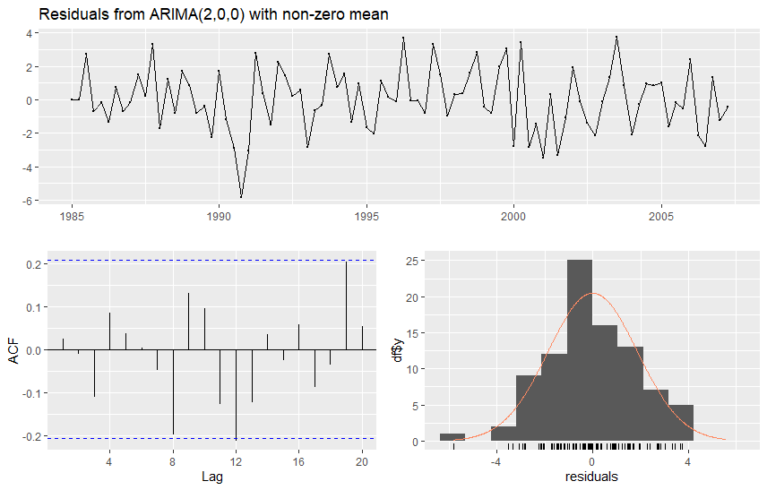

Figure: The residual time series of the AR(2) model estimated for the US real GDP growth series (upper figure), their estimated autocorrelation function ($h=0,\ldots,20$, bottom left) and their histogram (bottom right).

The main conclusions from residual diagnostics do not substantially change if using the AIC to select the lag length of the AR model. In the resulting AR(3) model the third lag ($y_{t-3}$) is not statistically significant predictor in terms of the estimated t-value. Moreover, when considering ARMA models, the AIC selects MA(2) model, with essentially the same conclusions from residual diagnostics as in the AR(2) model.

When considering squared residuals and the McLeod-Li test statistics for different lag lengths, it turns out that basically with any lag length selection the resulting p-values are very high (typically higher than 0.50). Therefore, for the Great Moderation time period in the U.S. economy, there is no initial evidence for strong nonlinearities in the real GDP growth.

## 7.5 R Lab

# 8 Forecasting with ARMA models

## 8.1 Properties of the conditional expectation

Before considering forecasting with an ARMA($p$,$q$) process, we examine a general situation where the objective is to forecast the (scalar) random variable $Y$ using the realized value $\boldsymbol{X}=\boldsymbol{x}$ of a random vector $\boldsymbol{X}$. A result from probability theory tells us that the optimal forecast, in the sense of minimized mean square error, is the conditional expected value of $Y$ given $\boldsymbol{X}=\boldsymbol{x}$. In other words,
$$\begin{equation*}
\mathsf{E}\left[\left(Y-\mathsf{E}\left(Y\left\vert \boldsymbol{X}=\boldsymbol{x}\right.\right)\right)^{2}\right]\leq\mathsf{E}\left[\left(Y-g\left(\boldsymbol{x}\right)\right)^{2}\right]
\end{equation*}$$
for any function $g\left(\boldsymbol{x}\right)$ of $\boldsymbol{x}$ (assuming the expectations above are finite).

The above definition can be generalized to the case where the random vector $\boldsymbol{X}$ might be infinite-dimensional. This case will be encountered in the ARMA($p$,$q$) context assuming that all the values of the process $\left\{y_{t},\text{ }t=0,\pm1,\ldots\right\}$ that precede the **forecast origin** (the time when the forecast is constructed) are known.

For our purposes, it suffices to know some simple properties of the conditional expected value (which also hold in the case of an infinite-dimensional conditioning variable). In this course, we will use the following properties of the conditional expected value:

- **CEV1**: $\mathsf{E}\left(aY_{1}+bY_{2}\left\vert \boldsymbol{X} \right.\right)=a\mathsf{E}\left(Y_{1}\left\vert \boldsymbol{X} \right.\right) +b\mathsf{E}\left(Y_{2}\left\vert \boldsymbol{X} \right.\right)$, when $a$ are $b$ constants.
- **CEV2**: $\mathsf{E}\left(Y\left\vert \boldsymbol{X} \right. \right)=\mathsf{E}\left(Y\right)$, when $Y$ and $\boldsymbol{X}$ are independent random variables.
- **CEV3**: $\mathsf{E}\left(Y\right)=\mathsf{E}\left[\mathsf{E}\left(Y\left\vert \boldsymbol{X} \right.\right)\right]$ (so-called law of iterated expectations)
- **CEV4**: $\mathsf{E}\left[h\left(\boldsymbol{X} \right)Y\left\vert \boldsymbol{X} \right.\right]=h\left(\boldsymbol{X} \right)\mathsf{E}\left(Y\left\vert \boldsymbol{X} \right.\right)$ for any function $h$ (assuming the expected value of $h\left(\boldsymbol{X}\right)Y$ exists and is finite).

## 8.2 Forming forecasts

**Forecasting an ARMA($p$,$q$) process**. As the discussion above suggests, we consider forecasting an ARMA($p$,$q$) process assuming that the entire infinitely long history of the process is known.

In what follows, we again assume that the constant term is included in the model equation to control a nonzero mean of $y_t$ (i.e. $\mathsf{E}(y_t) = \mu \neq 0$).

- When we are interested in forecasting the levels of $y_t$, which is often and typically the case, it is important to consider how forecasts will be obtained for original levels if using demeaning of the time series and/or extracting a trend component. That is, all the possible transformations must be carefully taken into account in forecast computations.
- We will also assume that the ARMA($p$,$q$) process under consideration is stationary and invertible and that the innovation term satisfies the condition $u_{t}\sim\mathsf{iid}\left(0,\sigma^{2}\right)$.

In the calculations that follow, we repeatedly make use of the above-mentioned properties of the conditional expected value (CEV1–CEV4).

**AR(1) case**. Consider forecasting an AR($p$) process, and for simplicity, we first also assume that $p=1$.

- In one-step forecasting, the aim is to forecast the value $y_{t+1}$, when the preceding history $\left\{y_{t},y_{t-1},\ldots\right\}$ of the process is known.
- More generally, in $h$-step forecasting, the aim is to forecast the value of $y_{t+h}$, when $\left\{y_{t},y_{t-1},\ldots\right\}$ is known.

For brevity, denote the conditional expectation as
$$\begin{equation*}
\mathsf{E}\left(y_{t+h}\left\vert y_{s},\text{ }s\leq t\right.\right)=\mathsf{E}_{t}\left( y_{t+h}\right), \quad \left(h\geq1\right).
\end{equation*}$$
Taking conditional expectations of both sides of the AR(1) equation (forwarded first by one period)
$$\begin{equation*}
y_{t+1} = \nu + \phi_{1}y_{t}+u_{t+1}
\end{equation*}$$
leads to (see CEV1)
$$\begin{equation*}
\mathsf{E}_{t}\left(y_{t+1}\right) = \nu + \phi_{1}\mathsf{E}_{t}\left(y_{t}\right)+\mathsf{E}_{t}\left(u_{t+1}\right).
\end{equation*}$$

- Under the stationarity condition $\left\vert \phi_{1}\right\vert<1$, the variables $y_{t},y_{t-1},\ldots$ depend only on the variables $u_{t},u_{t-1},\ldots$. Recall the MA($\infty$) representation of $y_t$ to see this.
- Therefore, in the conditional expectation $\mathsf{E}_{t}\left(u_{t+1}\right)$, the conditioning random variables $\left\{y_{s},s\leq t\right\}$ are independent of $u_{t+1}$. Following the property CEV2, we then obtain
  $$\begin{equation*}
  \mathsf{E}_{t}\left(u_{t+1}\right)=\mathsf{E}\left(u_{t+1}\right)=0.
  \end{equation*}$$
  More generally it holds
  $$\begin{equation*}
  \mathsf{E}_{t}\left(u_{t+k}\right)=\mathsf{E}\left(u_{t+k}\right)=0, \quad k \ge 1.
  \end{equation*}$$
- Moreover, $\mathsf{E}_{t}\left(y_{t}\right)=y_{t}$ (see CEV4: $y_t$ is included in the information set at time $t$).

Putting the above results together, we obtain
$$\begin{equation*}
\mathsf{E}_{t}\left(y_{t+1}\right) = \nu + \phi_{1}y_{t}.
\end{equation*}$$

When forecasting $y_{t+2}$, we obtain
$$\begin{eqnarray*}
\mathsf{E}_{t}\left(y_{t+2}\right) &=& \nu + \phi_{1}\mathsf{E}_{t}\left(y_{t+1}\right)+\mathsf{E}_{t}\left(u_{t+2}\right) \\
&=& \nu + \phi_{1}\mathsf{E}_{t}\left(y_{t+1}\right) \\
&=& (1+\phi_1) \nu + \phi_{1}^{2}y_{t},
\end{eqnarray*}$$
and inductively (given $|\phi_1|<1$) $h$-period forecast
$$\begin{equation*}
\mathsf{E}_{t}\left(y_{t+h}\right)= (1+\phi_1 + \cdots + \phi^h_1) \nu + \phi_{1}^{h}y_{t} =
\mu + \phi_{1}^{h}y_{t}.
\end{equation*}$$

**AR($p$) case**. In the case of a general AR($p$) process, we use a similar steps to obtain forecasts. Taking conditional expectations of both sides of
$$\begin{equation*}
y_{t+1} = \nu + \phi_{1}y_{t}+\cdots+\phi_{p}y_{t+1-p}+u_{t+1},
\end{equation*}$$
and using similar arguments as in the case $p=1$, including the results $\mathsf{E}_{t}\left(u_{t+1}\right)=0$ and $\mathsf{E}_{t}\left(y_{t-j}\right)=y_{t-j}$ $\left(j\geq0\right)$, we obtain
$$\begin{equation*}
\mathsf{E}_{t}\left(y_{t+1}\right) = \nu + \phi_{1}y_{t}+\cdots+\phi_{p}y_{t+1-p}.
\end{equation*}$$
When forecasting $y_{t+2}$, we similarly obtain
$$\begin{equation*}
\mathsf{E}_{t}\left(y_{t+2}\right)= \nu + \phi_{1}\mathsf{E}_{t}(y_{t+1})+\phi_{2}y_{t}+\cdots+\phi_{p}y_{t+2-p},
\end{equation*}$$
where the conditional expected value on the right hand side could be replaced with the expression obtained for it above.

- In other words, the variable $y_{t+1}$, unknown at time $t$, has been replaced with its forecast $\mathsf{E}_{t}(y_{t+1})$.
- The variables $y_{t},\ldots,y_{t+2-p}$ are known at time $t$. Therefore, they remain on the right hand side as they are included in the information set at the forecast origin.

Inductively, it is straightforward to see that the above generalizes to forecasting $h$ periods ahead
$$\begin{equation*}
\mathsf{E}_{t}\left(y_{t+h}\right) = \nu + \phi_{1}\mathsf{E}_{t}(y_{t+h-1})+\phi_{2}\mathsf{E}_{t}(y_{t+h-2})+\cdots+\phi_{p}\mathsf{E}_{t}(y_{t+h-p}), \quad h\geq1,
\end{equation*}$$
where $\mathsf{E}_{t}\left(y_{t+h-j}\right)=y_{t+h-j}$ for $h\leq j$. This means that forecasts can be computed recursively, starting with the one-step-ahead case $h=1$, and proceeding one step at a time to the forecast horizons $h=2$, $h=3,\ldots$.

**ARMA($p,q$) case**. To obtain forecasting formulae for an ARMA($p$,$q$) process is quite similar to forecasting with an AR($p$) process.

- When the stationarity condition holds, $y_{t}-\mu = \sum_{j=0}^{\infty}\psi_{j}u_{t-j}$, from which it follows that $u_{t+i}$, $i\geq1$, is independent of the variables $\left\{y_{t},y_{t-1},\ldots\right\}$.
- Therefore, $\mathsf{E}_{t}(u_{t+i})=\mathsf{E}(u_{t+i})=0$ for all $i\geq0$ (see CEV2).
- On the other hand, when the invertibility condition holds, $u_{t}=\sum_{j=0}^{\infty}\pi_{j}(y_{t-j}-\mu)$, and therefore $\mathsf{E}_{t}(u_{t-i})=u_{t-i}$ for all $i\geq0$ (see CEV4).

Taking conditional expectations of both sides of the equation defining an ARMA($p$,$q$) and using the above-mentioned properties, we obtain $h$-period ahead forecast
$$\begin{eqnarray*}
\mathsf{E}_{t}(y_{t+h}) &=& \nu + \phi_{1}\mathsf{E}_{t}(y_{t+h-1})+\cdots+\phi_{p}\mathsf{E}_{t}(y_{t+h-p})
+ \theta_{1}\mathsf{E}_{t}(u_{t+h-1})+\cdots+\theta_{q}\mathsf{E}_{t}(u_{t+h-q}), \quad h \geq 1,
\end{eqnarray*}$$
where $\mathsf{E}_{t}\left(y_{t+h-j}\right)=y_{t+h-j}$ for $h\leq j$, and
$$\begin{equation*}
\mathsf{E}_{t}\left(u_{t+h-j}\right)=\left\{
\begin{array}{cc}
&u _{t+h-j}, \,\, \mathrm{when} \,\, h\leq j, \\
&0, \,\, \mathrm{when}\,\, h>j.
\end{array}
\right.
\end{equation*}$$
Using this forecast formula, forecasts can again be computed recursively, starting with the one-step-ahead case $h=1$, and proceeding one step at a time to the cases $h=2,$ $h=3,\ldots$.

The discussion above makes the unrealistic assumption that the parameters of the examined process are known.

- In practice, unknown parameters are replaced by their estimates, and in this case the above-mentioned optimality of forecasts (forecast construction) only holds approximately.

Moreover, for ARMA models, in practice the innovation terms appearing in the forecasting formulae above (not in the AR($p$) case) have to be computed using the observed time series, so in the formula $u_{t}=\sum_{j=0}^{\infty}\pi_{j}(y_{t-j}-\mu)$ we have to truncate the sum at some point (e.g., $\sum_{j=0}^{t-1}\pi_{j} (y_{t-j}-\mu)$).

- A popular alternative is to calculate $u_{t}$ using the difference equation
  $$\begin{equation*}
  u_{t}=y_{t} - \nu - \phi_{1}y_{t-1}-\cdots-\phi_{p}y_{t-p}-\theta_{1}u_{t-1}-\cdots-\theta_{q}u_{t-q}, \quad t=1,2,\ldots,
  \end{equation*}$$
  where the initial values $y_{0},\ldots,y_{-p}$ can be assumed known (that is, observed), and the initial values $u_{0},\ldots,u_{-q}$ can be chosen to be $u_{0}=\cdots=u_{-q}=0$ (that is, the unconditional mean of the $u_{t}$). When $t$ is large, the effect of initial values is negligible.

## 8.3 Prediction intervals

An alternative way to approach forecasting an ARMA($p$,$q$) process is via the MA$\left(\infty\right)$ representation. Taking conditional expectations of both sides of the equation
$$\begin{equation*}
y_{t+h}= \mu + \sum_{j=0}^{\infty}\psi_{j}u_{t+h-j},
\end{equation*}$$
and using results of conditional expectations used above, we obtain
$$\begin{equation*}
\mathsf{E}_{t}(y_{t+h}) = \mu + \sum_{j=h}^{\infty}\psi_{j}u_{t+h-j}.
\end{equation*}$$
This formula is not useful in practice, but it is convenient for investigating the properties of the forecast error $y_{t+h}-\mathsf{E}_{t}(y_{t+h})$. From the two equations above, we obtain
$$\begin{equation*}
y_{t+h}-\mathsf{E}_{t}(y_{t+h})=\sum_{j=0}^{h-1}\psi_{j}u_{t+h-j}.
\end{equation*}$$
Note, in particular, that the forecast error of the one-step forecast is $u_{t+1}$.

- Taking (unconditional) expectations from both sides of the last equation shows that the forecast $\mathsf{E}_{t}(y_{t+h})$ is unbiased in the sense that the forecast error has an expected value of zero:
  $$\begin{equation*}
  \mathsf{E}\left[y_{t+h}-\mathsf{E}_{t}(y_{t+h})\right]=0.
  \end{equation*}$$
- Furthermore, we can compute the variance of the forecast error. With straightforward computation, we obtain
  $$\begin{equation*}
  \mathsf{Var}\Big(y_{t+h}-\mathsf{E}_{t}(y_{t+h})\Big)=\sigma^{2}\sum_{j=0}^{h-1}\psi_{j}^{2}\equiv\sigma_{h}^{2}.
  \end{equation*}$$
- Importantly, note that as $h$ increases, the forecast converges (in mean square) to the mean of the process, whereas the variance of the forecast error $\sigma_{h}^{2}$ converges to the variance of the process being predicted ($y_{t}$), namely $\sigma^{2}\sum_{j=0}^{\infty}\psi_{j}^{2}$.

If one assumes that $u_{t}\sim\mathsf{nid}\left(0,\sigma^{2}\right)$, then
$$\begin{equation*}
y_{t+h}-\mathsf{E}_{t}(y_{t+h})\sim\mathsf{N}\left(0,\sigma_{h}^{2}\right)
\end{equation*}$$
and, therefore, $y_{t+h}$ is contained in the interval
$$\begin{equation*}
\mathsf{E}_{t}(y_{t+h})\pm1.96\sigma_{h}
\end{equation*}$$
with 95% probability (in repeated sampling). In practice, the unknown parameters in the forecast $\mathsf{E}_{t}(y_{t+h})$ and in the standard deviation $\sigma_{h}$ are replaced by their estimates, and hence the normality of the forecast errors hold only approximately.

**Empirical example (continue)**. In the previous two sections, we concluded that an AR(2) model to be one possible candidate for the U.S real GDP growth (1985:Q1–2007:Q2). The estimated AR(2) model
$$\begin{equation*}
y_{t} = \underset{\left(0.197\right) }{1.693} + \underset{\left(0.101\right) }{0.160} y_{t-1} + \underset{\left(0.101\right) }{0.287} y_{t-1} + \widehat{u}_{t}, \quad \widehat{\sigma}^{2}=3.536,
\end{equation*}$$
where under the estimates in brackets are the approximate standard errors. Therefore, if now computing 8-quarter-ahead predictions starting from the last observation (2007:Q2) are obtained with the forecasting formulae above applied in the case of $p=2$ (and $q=0$) and $h=8$. The resulting (point) forecasts of the estimated AR(2) model and their 80 and 95% confidence intervals are presented below.

```markdown
        Point Forecast      Lo 80    Hi 80      Lo 95    Hi 95
2007 Q3       2.427727 0.01787587 4.837578 -1.2578223 6.113277
2007 Q4       2.781453 0.34098863 5.221917 -0.9509150 6.513820
2008 Q1       2.834604 0.28036903 5.388840 -1.0717615 6.740971
2008 Q2       2.944709 0.38002888 5.509388 -0.9776305 6.867048
2008 Q3       2.977582 0.40040373 5.554759 -0.9638718 6.919035
2008 Q4       3.014464 0.43506842 5.593860 -0.9303814 6.959310
2009 Q1       3.029805 0.44884169 5.610767 -0.9174375 6.977047
2009 Q2       3.042852 0.46149492 5.624209 -0.9049929 6.990696
```

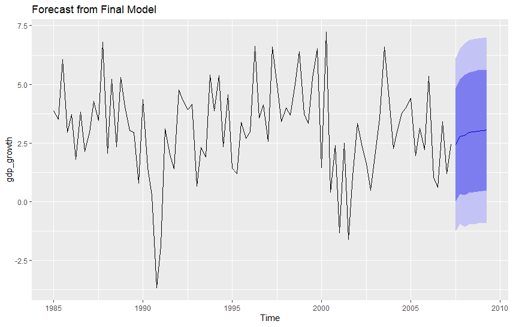

Figure: 8-step-ahead forecasts for the U.S. real GDP growth and their 80 and 95% confidence intervals from the AR(2) process.

Obviously these forecasts, constructed at 2007:Q2, for the years 2008 and 2009 turned out to be too optimistic due to the Great Financial Crisis (2008–2009) and the worst recession in almost 100 years occurred in that time! It can generally be concluded that there were no econometric models able to predict such a depression. Therefore, these forecasts can rather be seen as a scenario type of forecast how the U.S. economy could have been evolved without the financial crisis.

## 8.4 Introduction to out-of-sample forecasting

In various fields, particularly economics and finance, it is crucial to assess the reliability and accuracy of forecasts generated by estimated time series models. A popular method for this evaluation is (pseudo) **out-of-sample forecasting**. This approach aims to mimic a real-time forecasting scenario as closely as possible, using only information that would have been available at the time the forecast was made.

The fundamental idea is to evaluate the forecast performance by systematically reserving a portion of the data, unknown to the model during its estimation, to serve as a “future” against which forecasts are compared. This method is termed at times “pseudo” out-of-sample forecasting because, while we are simulating real-time forecasting, we do have full knowledge of the entire dataset beforehand in our analysis. In a “true” real-time forecasting, future observations are, by definition, unknown.

- Notice that **backtesting** in the financial industry is essentially a form of out-of-sample forecasting applied specifically to financial data and trading strategies. While the underlying principle is the same, the terminology and focus can differ slightly. While a time series analyst might use out-of-sample forecasting to evaluate how accurately they can predict a stock’s price, a financial analyst would use backtesting to see if a strategy based on those predictions would have actually made money.

**The out-of-sample forecasting process** generally involves the following steps:

1. **Define initial estimation sample**: An initial segment of the time series, say the first $T$ observations ($y_1, \dots, y_T$), is used to estimate the model’s parameters. This period is often referred to as the **training sample** or **estimation sample**.
2. **Define forecasting horizon ($h$)**: Like above where we introduced how to construct forecasts with ARMA models, we specify how many periods ahead we want to forecast (e.g., $h=1$ for one-period-ahead, $h=2$ for two-periods-ahead, etc.).
3. **Define forecasting evaluation period**: A subsequent segment of the data, known as the **test sample** or **forecasting sample**, is set aside. This period spans from $y_{T+1}$ up to $y_{T+m+h-1}$, where $m$ is the number of distinct **forecast origins** (i.e., the number of times we re-estimate the model and generate a new $h$-step forecast).
4. **Iterative forecasting and parameter updating**: The core of (pseudo) out-of-sample forecasting is its iterative nature. We start by estimating the model using the initial $T$ observations, then we forecast $h$ periods ahead. We then “advance time” by one period, potentially re-estimate the model with updated information, and generate a new $h$-period-ahead forecast. This process is repeated $m$ times.

Let’s clarify the notation with an example. Suppose we want to evaluate two-period-ahead forecasts ($h=2$).

- Let $T$ denote the end of our *initial* estimation sample.
- Let $j$ be an index for the forecast origin, running from $j=0, 1, \dots, m-1$. For simplicity, let $m=4$.

The sequence of forecasts at different forecast origins and their corresponding actual values would be:

- Forecast origin $T$ (i.e., $j=0$):
  - Estimate the model using data $y_1, \dots, y_T$.
  - Generate a $h=2$ period forecast, denoted $\widehat{y}_{T+2|T}$.
  - This forecast is compared against the actual observation $y_{T+2}$.
  - The forecast error is $\widehat{e}_{T+2} = y_{T+2} - \widehat{y}_{T+2|T}$.
- Forecast origin $T+1$ (i.e., $j=1$):
  - Update the estimation sample. This is where rolling vs. expanding parameter updating window (see below) becomes relevant.
  - Generate a $h=2$ period forecast, denoted $\widehat{y}_{T+3|T+1}$.
  - This forecast is compared against the actual observation $y_{T+3}$.
  - The forecast error is $\widehat{e}_{T+3} = y_{T+3} - \widehat{y}_{T+3|T+1}$.
- Forecast origin $T+2$ (i.e., $j=2$):
  - Update the estimation sample.
  - Generate a $h=2$ period forecast, denoted $\widehat{y}_{T+4|T+2}$.
  - This forecast is compared against the actual observation $y_{T+4}$.
  - The forecast error is $\widehat{e}_{T+4} = y_{T+4} - \widehat{y}_{T+4|T+2}$.
- Forecast origin $T+3$ (i.e., $j=3$):
  - Update the estimation sample.
  - Generate a $h=2$ period forecast, denoted $\widehat{y}_{T+5|T+3}$.
  - This forecast is compared against the actual observation $y_{T+5}$.
  - The forecast error is $\widehat{e}_{T+5} = y_{T+5} - \widehat{y}_{T+5|T+3}$.

In general, for $j=0, 1, \dots, m-1$, we compute the $h$-period forecast from the information available at $T+j$, denoted $\widehat{y}_{T+h+j|T+j}$. The corresponding forecast error is:
$$\begin{equation*}
\widehat{e}_{T+h+j} = y_{T+h+j} - \widehat{y}_{T+h+j|T+j}
\end{equation*}$$

**Parameter updating strategies**. In a real forecasting situation, the information set used for model estimation typically includes the most recent observations. The way this information set is updated over time defines different parameter estimation strategies:

- **Expanding window**: In this approach, the estimation sample grows by one observation in each iteration. If the initial estimation sample is $y_1, \dots, y_T$, the next estimation sample will be $y_1, \dots, y_{T+1}$, then $y_1, \dots, y_{T+2}$, and so on. This means older observations are always retained. This is suitable when one believes that all past data is equally relevant for estimating the current parameters.
- **Rolling window**: Here, the estimation sample has a fixed size (e.g., $T$ observations) and “rolls” forward by one observation in each iteration. If the initial sample is $y_1, \dots, y_T$, the next sample will be $y_2, \dots, y_{T+1}$, then $y_3, \dots, y_{T+2}$, and so on. This approach gives more weight to recent observations and is useful when model parameters are suspected to change over time (i.e., the presence of structural breaks or regime changes).

The accompanying R code (R Lab below) allows you to select either a `rolling` or `expanding` window strategy using the `window_type` parameter.

**Evaluating forecast accuracy**. Once the forecast errors ($\widehat{e}_{T+h+j}$) for the entire test sample are computed, a typical measure for evaluating forecast accuracy is the **Mean Squared Forecast Error (MSFE)**:
$$\begin{equation*}
MSFE = \frac{1}{m} \sum_{j=0}^{m-1} \widehat{e}_{T+h+j}^2.
\end{equation*}$$
The MSFE penalizes larger errors more heavily due to the squaring forecast errors. Its square root, the **Root Mean Squared Forecast Error (RMSFE)**, is also commonly used as it is in the same units as the original series, making it easier to interpret.

Another popular alternative is the **Mean Absolute Forecast Error (MAFE)**:
$$\begin{equation*}
MAFE = \frac{1}{m} \sum_{j=0}^{m-1} |\widehat{e}_{T+h+j}|.
\end{equation*}$$
The MAFE is less sensitive to outliers than the MSFE.

The objective of this exercise is to identify the model(s) that produce the smallest MSFE and/or MAFE values, indicating superior forecasting performance.

**Empirical example (continue)**. Let us continue an illustration of out-of-sample forecasting of the quarterly U.S. real GDP growth. Assume that we start out-of-sample forecasting in 2010:Q1 and construct one ($h=1$) and four ($h=4$) quarter out-of-sample forecasts for the forecasting sample (test) sample period 2010:Q1–2019:Q4. We compare the performance of AR(1), AR(2), AR(3) and AR(4) models.

- The first estimation sample is between 1985:Q1–2009:Q4.
- Obviously, based on the previous results (for the sample period excluding the Great Financial Crisis) suggest the AR(2) model.
- Parameter updating is done via expanding and rolling window approaches separately.
- MSFEs suggest that except $h=4$ horizon and rolling window approach (there AR(4) model), AR(3) model yields the smallest MSFE in different comparisons.

```markdown
--- MSFE Results for AR(1), AR(2), AR(3), AR(4) (h=1, expanding window) ---
$`AR(1)`
[1] 3.010018
$`AR(2)`
[1] 2.810865
$`AR(3)`
[1] 2.760154
$`AR(4)`
[1] 3.451758

--- MSFE Results for AR(1), AR(2), AR(3), AR(4) (h=1, rolling window) ---
$`AR(1)`
[1] 3.032567
$`AR(2)`
[1] 2.793521
$`AR(3)`
[1] 2.731007
$`AR(4)`
[1] 3.481733

--- MSFE Results for AR(1), AR(2), AR(3), AR(4) (h=4, expanding window) ---
$`AR(1)`
[1] 2.628715
$`AR(2)`
[1] 2.662022
$`AR(3)`
[1] 2.457973
$`AR(4)`
[1] 2.467844

--- MSFE Results for AR(1), AR(2), AR(3), AR(4) (h=4, rolling window) ---
$`AR(1)`
[1] 2.602836
$`AR(2)`
[1] 2.633853
$`AR(3)`
[1] 2.496958
$`AR(4)`
[1] 2.478106
```

## 8.5 R Lab

# 9 Volatility modelling: AR-GARCH model

## 9.1 Modelling conditional variance

ARMA models can be characterized as models for the conditional mean of a stationary process.

- When the invertibility condition holds, ARMA processes have the AR($\infty$) representation from which it can be seen that the conditional expected value of $y_{t}$, conditional on the past of the process $\left\{y_{t-1},y_{t-2},\ldots\right\}$, is $\mathsf{E}_{t-1}(y_t)=-\sum_{j=1}^{\infty}\pi_{j} (y_{t-j}-\mu)$.

The conditional variance of an ARMA process (model) $y_t$ is
$$\begin{eqnarray*}
\mathsf{Var}_{t-1}(y_t) &=& \mathsf{E}_{t-1}(y_t-\mathsf{E}_{t-1}(y_t))^2 \\
&=& \mathsf{E}_{t-1}(u^2_t) \\
&=& \mathsf{E}(u^2_t) \qquad (\mathrm{CEV2}) \\
&=& \sigma ^{2}.
\end{eqnarray*}$$
This shows that evident systematic variation in conditional variance, that several time series contain, cannot be taken into consideration with an ARMA model. Typical examples of such time series are financial time series and especially different asset return series.

**Empirical example**. The NASDAQ 100 (ticker symbol ^NDX) is a major stock market index that tracks the performance of 100 of the largest non-financial companies listed on the NASDAQ stock market (U.S. stock market).

- It includes 100 of the largest domestic and international companies listed on NASDAQ, weighted by a modified market capitalization method to limit the influence of the very large firms. The index excludes financial companies and is heavily concentrated in the technology sector and dominated by a few extremely large companies like (as in 2025) NVIDIA Corporation (NVDA), Microsoft Corp. (MSFT), Apple Inc. (AAPL) and Amazon.com Inc. (AMZN).
- The NASDAQ 100 is widely viewed as the benchmark for large-cap growth stocks.

Let us consider excess stock returns of the NASDAQ 100 over the 3-Month Treasury Bill rate. As a simple approximation, we can think that we are interested in the percentage changes (log-differences) of the NASDAQ 100 index adjusted for risk-free rate return (see Transformations in Section 1). Below we depict the daily excess stock returns between 1.1.2003–30.9.2025.

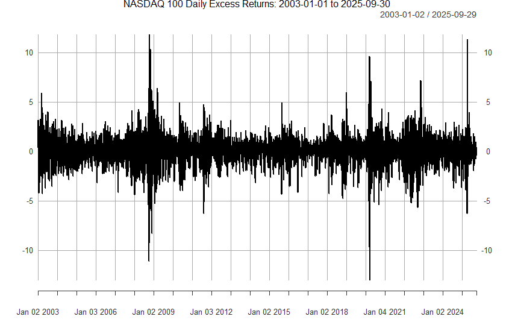

Figure: Excess stock returns of the NASDAQ 100 stock market index.

- Typically asset returns are almost non-autocorrelated
- For this sample period and NASDAQ returns, the resulting Ljung-Box test statistics reject the null hypothesis of no autocorrelation with all the relevant statistical significance levels.

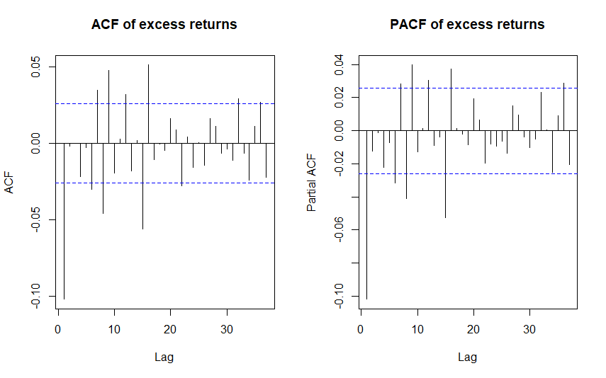

Figure: Sample autocorrelations and partial autocorrelations in NASDAQ 100 excess returns.

The asset return series exhibits, however, some even more clear and typical variation, which is reflected by the autocorrelation function of the squared observations: All the reported autocorrelation coefficients of squared observations exhibit clear positive autocorrelation exceeding the 95%-critical bound. The approximate $p$-value of the McLeod Li test with $H=10$, and also with other selections, is zero with four decimal precision.

- There are periods during which the variation of the series is either larger or smaller than on average. This “volatility clustering” is certain type of heteroskedasticity.
- When the definition of variance is taken into account, it is natural to investigate this using the autocorrelation function of the squared observations. Notable are also the large difference between large and small absolute values, which suggests a more fat-tailed distribution than the normal distribution.

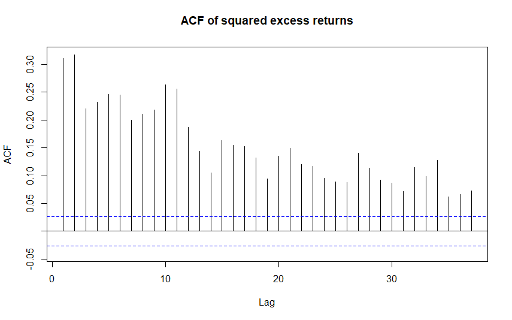

Figure: Sample autocorrelations for the squared stock return observations.

In what follows, heteroskedasticity similar to that of the stock return series above is thought to be not related with changes in unconditional variance, but rather with changes in the **conditional variance** where conditioning is on the past values of the series. Next, we will first consider some general aspects of models used in modelling conditional variance, and then focus on some particular models that are most common in practice.

## 9.2 Model formulation

In this section, we consider an AR-GARCH model determined by the following two equations
$$\begin{equation*}
y_{t} = \nu + \phi_{1}y_{t-1}+\cdots+\phi_{p}y_{t-p}+u_{t},
\end{equation*}$$
$$\begin{equation*}
u_{t} = h_{t}^{1/2}\varepsilon_{t},\quad \varepsilon_{t}\sim\mathsf{iid}\left(0,1\right),
\end{equation*}$$
where $h_{t}$ is a function of the variables $u_{t-j}$, $j>0$, and the error term $\varepsilon_{t}$ is assumed to be independent of the variables $y_{t-j}, \, j>0$, and hence also of the variables $u_{t-j}$, $j>0$. In other words, we consider an **AR($p$) model whose error term is conditionally heteroskedastic**.

- The coefficients $\phi_{1},\ldots,\phi_{p}$ are assumed to satisfy the (sufficient) stationarity condition of the AR($p$) process: $1 - \phi_1 z - \cdots - \phi_p z^p = \phi(z) \neq 0, \, \mathrm{when} \, |z| \le 1$.

Regarding the conditional variance, by its definition, the variance of a random variable is associated with the squares of the random variable. Therefore, it seems natural that the conditional variance $h_t$ would depend on the past squared values of the process. For concreteness sake, consider a general **GARCH($r$,$s$) model**
$$\begin{equation*}
h_{t}=\omega+\beta_{1}h_{t-1}+\cdots+\beta_{r}h_{t-r}+\alpha_{1}u_{t-1}^{2}+\cdots+\alpha_{s}u_{t-s}^{2},
\end{equation*}$$
whose parameters are assumed to satisfy the required conditions for non-negativeness, identification, and strict stationarity (to be considered below).

As before, we denote the conditional expectation as $\mathsf{E}_{t-1}\left(\cdot\right)=\mathsf{E}\left(\cdot\left\vert y_{s},\text{ }s\leq t-1\right.\right)$. Because $u_{t}$ is a function of the variables $y_{t}$, …, $y_{t-p}$, the conditional variance $h_{t}$ is a function of the variables $y_{t-j}$, $j>0$. Therefore, we can use the same arguments as considered, e.g., in forecast construction (see CEV4) to conclude that in the AR-GARCH model
$$\begin{equation*}
\mathsf{E}_{t-1}\left( u_{t}\right) =h_{t}^{1/2} \mathsf{E}_{t-1}\left(\varepsilon_{t}\right) =h_{t}^{1/2}\mathsf{E}\left(\varepsilon_{t}\right)=0.
\end{equation*}$$
Together with this result, the model equations of the AR-GARCH model can be used to justify the following two results
$$\begin{equation*}
\mathsf{E}_{t-1}(y_t) = \nu + \phi_{1} y_{t-1}+ \cdots + \phi_{p}y_{t-p} \quad \mathrm{and} \quad \mathsf{Var}_{t-1}(y_t)=h_t.
\end{equation*}$$

- The latter result can be justified by noticing that $y_{t} = \mathsf{E}_{t-1}\left(y_{t}\right) + u_{t}$ and that
  $$\begin{eqnarray*}
  \mathsf{Var}_{t-1}\left(y_{t}\right) &=& \mathsf{E}_{t-1}(y_t - \mathsf{E}_{t-1}(y_t))^2 \\
  &=& \mathsf{E}_{t-1}\left(u_{t}^{2}\right) \\
  &=& h_t \mathsf{E}(\varepsilon_{t}^{2}) \\
  &=& h_{t},
  \end{eqnarray*}$$
  where the result CEV2 and the identity $u_{t}^{2}=h_{t}\varepsilon_{t}^{2}$ is used (see the general model definition above).

These two results demonstrate that the conditional mean and conditional variance of the process $y_{t}$ depend on the past values of the process. Based on the above points, building a volatility model, that is selecting the model equation for $h_t$, roughly consists of the following steps:

- Finding an adequate specification for the conditional mean $\mathsf{E}_{t-1}(y_t)$ (e.g., to select a suitable AR or ARMA model, and including also possible deterministic terms) is necessary to obtain a suitable specification for the conditional variance.
- Checking for the (conditional) heteroskedasticity of the error term. This can be based on residuals, as they are empirical counterparts of the error terms. That is testing “ARCH effects” using, e.g., the McLeod-Li test.
- Finding a sufficient specification for the conditional variance $h_t$. There are a lot of different alternative model specifications to GARCH($r,s$) suggested in the econometric literature. Replacing it with some of the alternatives yield a straightforward extension of the AR-GARCH model introduced above.
- Estimation of the full model can be carried out by the method of maximum likelihood.

## 9.3 GARCH(1,1) and ARCH($s$) models

Instead of the general GARCH($r,s$) model, the **GARCH(1,1) model**
$$\begin{equation*}
h_t = \omega + \beta_1 h_{t-1} + \alpha_1 u^2_{t-1}
\end{equation*}$$
has been found adequate for most (financial) time series data.

- In this GARCH(1,1) case, the non-negativeness of $h_t$ requires $\omega > 0$ and $\alpha_1, \beta_1 \ge 0$. Moreover, for $\beta_1$ to be identified, $\alpha_1$ must be strictly positive ($\alpha_1 > 0$).
- In the GARCH($r,s$) model, these non-negativeness conditions are clearly more complicated.

Another special case of GARCH models is obtained when $r=0$. That is the “GARCH-part” is missing and the GARCH($r,s$) model reduces to an **ARCH($s$)** model
$$\begin{eqnarray*}
h_t = \omega + \sum_{i=1}^{s} \alpha_i u^2_{t-1}.
\end{eqnarray*}$$

In line with the idea of capturing **volatility clustering** with ARCH and GARCH models, the periods of high (and low) conditional variance tend to persist. This is easy to see with the **ARCH(1) model** ($s=1$)
$$\begin{equation*}
h_t = \omega + \alpha_1 u^2_{t-i},
\end{equation*}$$
where $\omega, \alpha_1 \ge 0$. A large shock ($u^2_{t-1}$) increases $h_t$, which then subsequently increases $u^2_t$ and $h_{t+1}$. This same logic holds also for more general ARCH and GARCH models. Moreover, in the ARCH(1) model, assuming normality of $\varepsilon_t$, the (unconditional) kurtosis of $u_t$ is
$$\begin{equation*}
\frac{\mathrm{E}(u^4_t)}{\mathrm{E}(u^2_t)^2} = \frac{3 (1 - \alpha^2_1)}{1 - 3 \alpha^2_1}.
\end{equation*}$$
Kurtosis is finite (i.e. the 4th moment exists) if $3 \alpha^2_1 < 1$ and larger than 3 implied by the normal distribution. The ARCH(1) model is hence capable of capturing excess kurtosis often present in financial data.

- Large outliers (in absolute value) appear more often than implied by the innovations in (observed) asset returns.
- Similar result on excess kurtosis holds also for more general ARCH and GARCH models, but the formulae become more complicated.

As a summary of large past research, the GARCH(1,1) model has generally been found a successful and parsimonious alternative to the ARCH($s$) model with a typically large $s$ for asset returns. Why? By recursive substitutions, we get
$$\begin{eqnarray*}
h_t &=& \omega + \beta_1 h_{t-1} + \alpha_1 u^2_{t-1} \\
&=& \omega + \beta_1 \omega + \beta_1^2 h_{t-2} + \alpha_1 \beta_1 u^2_{t-2} + \alpha_1 u^2_{t-1} \\
& \vdots & \\
&=& \omega \sum_{j=0}^{k} \beta_1^j + \alpha_1 \sum_{j=0}^{k} \beta_1^j u^2_{t-1-j} + \beta_1^{k+1} h_{t-k-1}.
\end{eqnarray*}$$
This suggests that in the case $\beta_1 < 1$,
$$\begin{equation*}
h_t = \omega \sum_{j=0}^{\infty} \beta_1^j + \alpha_1 \sum_{j=0}^{\infty} \beta_1^j u^2_{t-1-j},
\end{equation*}$$
which is a particular kind of ARCH($\infty$) form. Therefore, we can conclude that GARCH(1,1) is able to capture volatility clustering in a parsimonious way by specifying only three parameters.

Another perspective on the GARCH models, and specifically to the GARCH(1,1) model, is obtained by adding $u_t^2$ on both sides of the model equation. Therefore, the GARCH(1,1) can be rewritten
$$\begin{equation*}
u^2_t = \omega + (\alpha_1 + \beta_1) u^2_{t-1} + \xi_t - \beta_1 \xi_{t-1},
\end{equation*}$$
where $\xi_t = u^2_t - h_t = h_t(\varepsilon^2_t-1)$ and $\mathrm{E}(\xi_t)=0$. This is an ARMA(1,1) type of presentation for $u_t^2$.

- As for the ARMA(1,1) process, the condition for weak and strict stationarity is $\alpha_1 + \beta_1 < 1$ (together with restrictions $0 \le \alpha_1, \beta_1 \le 1$ to, e.g., guarantee the non-negativity of $h_t$).
- Moreover, the unconditional variance (provided stationarity) is
  $$\begin{equation*}
  \mathrm{E}(u^2_t) = \frac{\omega}{1 - \alpha_1 - \beta_1}.
  \end{equation*}$$

## 9.4 Parameter estimation

If it is assumed that the error term is Gaussian
$$\begin{equation*}
\varepsilon_{t}\sim\mathsf{nid}\left(0,1\right),
\end{equation*}$$
the (conditional) likelihood function can be derived following analogous principles as in ARMA models. In other words, assuming $\varepsilon_t \thicksim \mathsf{nid}(0,1)$, we get
$$\begin{equation*}
u_t = h^{1/2}_t \varepsilon_t, \quad \varepsilon_t \thicksim \mathsf{nid}(0,1),
\end{equation*}$$
where $h_t = h_t(y_{t-1}, y_{t-2},\ldots)$, $\varepsilon_t$ and vector $(y_{t-1}, y_{t-2},\ldots)$ are independent, and $u_t = y_t - \mathsf{E}_{t-1}(y_t)$. Assume also that $y_t$ is stationary. Given the above assumptions and the conditional moments (conditional mean and variance) of the AR-GARCH model, we get the conditional density function of the observation $y_t$ as
$$\begin{equation*}
y_t|\{y_{t-j}, \, j \ge 1 \} \thicksim \mathsf{N}(\nu + \phi_1 y_{t-1} + \cdots + \phi_p y_{t-p}, h_t).
\end{equation*}$$
Therefore, it can be concluded that the conditional distribution of $y_{t}$, conditional on $\mkern 3mu\underline{\mkern-3mu\mathbf{Y}\mkern-3mu}\mkern 3mu_{t-1}=(y_1, \ldots y_{t-1}), \, t=1,\ldots,T$, is Gaussian with conditional mean $\nu + \phi_{1}y_{t-1}+\cdots+\phi_{p}y_{t-p}$ and conditional variance $h_{t}$ where the model equation for $h_{t}$ needs to be specified.

Using the observed time series and $l$ initial values $y_{-l},\ldots, y_0, y_1, \ldots, y_T$, as in the parameter estimation of ARMA models, this leads to the conditional joint density function
$$\begin{equation*}
\prod_{t=1}^{T} f_{y_t|\mkern 3mu\underline{\mkern-3mu\mathbf{Y}\mkern-3mu}\mkern 3mu_{t-1}} = (2\pi)^{-T/2} \cdot
\prod_{t=1}^{T} h^{-1/2}_t \cdot \mathrm{exp}\Big(-\frac{1}{2} \sum_{t=1}^{T} \frac{u^2_t}{h_t} \Big).
\end{equation*}$$
Denote the parameter vector of the AR-GARCH model $\boldsymbol{\vartheta}=\left(\boldsymbol{\phi,\delta}\right)$ where $\boldsymbol{\phi} = (\nu, \phi_1,\ldots, \phi_p)$ contains parameters related to the conditional mean and $\boldsymbol{\delta} = (\omega, \alpha_1, \ldots, \alpha_s, \beta_1, \ldots, \beta_r)$ contains the parameters of the model for the conditional variance. The log-likelihood then becomes (omitting constant terms not dependent on the model parameters)
$$\begin{equation*}
l(\boldsymbol{\vartheta}) = \sum_{t=1}^{T} l_t(\boldsymbol{\vartheta}) = -\frac{1}{2} \sum_{t=1}^{T} \mathrm{log}\, h_t(\boldsymbol{\phi}, \boldsymbol{\delta}) - \frac{1}{2} \sum_{t=1}^{T} \frac{u_t(\boldsymbol{\phi})^2}{h_t(\boldsymbol{\phi},\boldsymbol{\delta})},
\end{equation*}$$
with $u_t(\boldsymbol{\phi}) = y_t - \nu - \phi_1 y_{t-1} - \cdots - \phi_p y_{t-p}$ and $h_t(\boldsymbol{\phi}, \boldsymbol{\delta})$ are functions of the parameters $\boldsymbol{\phi}$ and $\boldsymbol{\delta}$. Maximization of the likelihood function is performed using numerical methods similar to the ARMA models.

- As an example, in the GARCH(1,1) case $r=s=1$ and hence $h_{t} = \omega + \beta_1 h_{t-1} + \alpha_1 u_{t-1}^{2},$ for the conditional variance. This means that $\boldsymbol{\delta} = (\omega, \alpha_1, \beta_1)$.

If the normality assumption of the error term $\varepsilon_t \thicksim \mathsf{nid}(0,1)$ made above holds, the usual asymptotic properties of the maximum likelihood estimator (consistency and asymptotic normality) hold. If the Gaussianity assumption is found inappropriate, one could either (or both):

- Use a non-Gaussian distribution, like the $t$-distribution for the error term. This leads to the different form for the log-likelihood function, but the general lines to obtain it are the same as above.
- Modify the asymptotic distribution and interpret the maximum likelihood estimator (MLE) as **quasi-MLE (QMLE)**.

Concerning the QMLE approach, if the likelihood function is maximized at $\boldsymbol{\widehat{\vartheta}}=(\boldsymbol{\widehat{\phi},\widehat{\delta})}$, it can be shown, even without the normality assumption and under general assumptions and regularity conditions, that it holds
$$\begin{equation*}
\widehat{\boldsymbol{\vartheta}} \underset{as}{\sim}\mathsf{N}\left(\boldsymbol{\vartheta},\boldsymbol{V}\left(\boldsymbol{\vartheta}\right)^{-1} \boldsymbol{B} \left(\boldsymbol{\vartheta}\right) \boldsymbol{V}\left(\boldsymbol{\vartheta}\right)^{-1}\right),
\end{equation*}$$
where
$$\begin{equation*}
\boldsymbol{V}\left(\boldsymbol{\vartheta}\right) = \mathsf{E}\left[-\partial^{2}l(\boldsymbol{\vartheta})/\partial\boldsymbol{\vartheta}\partial\boldsymbol{\vartheta}^{\prime}\right]
\end{equation*}$$
and
$$\begin{equation*}
\boldsymbol{B}\left(\boldsymbol{\vartheta}\right) =\mathsf{E}\left[\sum_{t=1}^{T}\left(\frac{\partial}{\partial\boldsymbol{\vartheta}}l_{t}(\boldsymbol{\vartheta})\right) \left(\frac{\partial}{\partial\boldsymbol{\vartheta}}l_{t}(\boldsymbol{\vartheta})\right)^{\prime}\right],
\end{equation*}$$
where $l_{t}(\boldsymbol{\vartheta})$ is as described above. Using the empirical counterparts of the matrices $\boldsymbol{V} \left(\boldsymbol{\vartheta}\right)$ and $\boldsymbol{B}\left(\boldsymbol{\vartheta}\right)$, namely
$$\begin{equation*}
\widehat{\boldsymbol{V}}(\boldsymbol{\widehat{\vartheta})}=-\partial^{2}l(\boldsymbol{\widehat{\vartheta}})/\partial\boldsymbol{\vartheta}\partial\boldsymbol{\vartheta}^{\prime} \quad \mathrm{and} \quad \widehat{\boldsymbol{B}}(\boldsymbol{\widehat{\vartheta})}=\sum_{t=1}^{T}\left( \frac{\partial}{\partial\boldsymbol{\vartheta}}l_{t}(\boldsymbol{\widehat{\vartheta}})\right)\left(\frac{\partial}{\partial\boldsymbol{\vartheta}}l_{t}(\boldsymbol{\widehat{\vartheta}})\right)^{\prime}
\end{equation*}$$
the asymptotic distribution of the estimator $\boldsymbol{\widehat{\vartheta}}$ presented above can be used to form approximate standard errors and Wald tests about the parameter $\boldsymbol{\vartheta}$.

- If the normality assumption (i.e. $\varepsilon_t \thicksim \mathsf{nid}(0,1)$) holds, then $\boldsymbol{V}\left(\boldsymbol{\vartheta}\right) = \boldsymbol{B}\left(\boldsymbol{\vartheta}\right)$, and the expressions above for the (QMLE) asymptotic distribution and the standard errors and Wald tests simplify to the usual MLE case.
- The practical message from above is that it is often reasonable to rely on the QMLE-based asymptotic distribution result and resulting robust standard errors, such as so called Bollerslev-Wooldridge standard errors, for different parameter estimates of the AR-GARCH model. The rationale is that model specification, including the distribution assumption $\varepsilon_t \thicksim \mathsf{nid}(0,1)$, is often not entirely correctly specified. Hence allowing for the additional robustness to the possible misspecification through QMLE estimates is advisable.

**Empirical example (continue)**. Consider the estimation result of the AR-GARCH model with Gaussian error term for the excess stock returns of the NASDAQ 100 index. For simplicity, fit a relatively simple AR(1)-GARCH(1,1) model (see above with selections $p=r=s=1$). That is, we specify

- AR(1) model for the conditional mean.
- GARCH(1,1) model for the conditional variance

That is, we estimate an AR(1) model with GARCH(1,1) errors. The estimation result of the maximum likelihood estimation, based on the normality assumption of $\varepsilon_t$, yields
$$\begin{eqnarray*}
y_{t} &=& \underset{{\left(0.013\right) }}{0.087} - \underset{{\left(0.013\right) }}{0.044} y_{t-1} +
\widehat{u}_{t}
\notag \\
&& \\
\widehat{h}_{t} &=&\underset{{\left(0.006\right) }}{0.035} +\underset{{\left(
0.013\right) }}{0.876}\widehat{h}_{t-1}+\underset{{\left( 0.012 \right) }}{0.105}\widehat{u}_{t-1}^{2}, \notag
\end{eqnarray*}$$
Here we report the robust standard errors under the parameter estimates (see the QMLE asymptotic distribution result). The full estimation result provided by **rugarch package** in R yields the following results:

```markdown
*---------------------------------*
*          GARCH Model Fit        *
*---------------------------------*

Conditional Variance Dynamics
-----------------------------------
GARCH Model : sGARCH(1,1)
Mean Model  : ARFIMA(1,0,0)
Distribution    : norm

Optimal Parameters
------------------------------------
        Estimate  Std. Error  t value Pr(>|t|)
mu      0.087229    0.012889   6.7679 0.000000
ar1    -0.043797    0.014149  -3.0954 0.001965
omega   0.035129    0.004868   7.2160 0.000000
alpha1  0.104804    0.008170  12.8272 0.000000
beta1   0.876000    0.008975  97.6078 0.000000

Robust Standard Errors:
        Estimate  Std. Error  t value Pr(>|t|)
mu      0.087229    0.012567   6.9412 0.000000
ar1    -0.043797    0.012630  -3.4677 0.000525
omega   0.035129    0.006497   5.4066 0.000000
alpha1  0.104804    0.012428   8.4331 0.000000
beta1   0.876000    0.012869  68.0716 0.000000

LogLikelihood : -9030.906

Information Criteria
------------------------------------

Akaike       3.1583
Bayes        3.1641
Shibata      3.1583
Hannan-Quinn 3.1603

Weighted Ljung-Box Test on Standardized Residuals
------------------------------------
                        statistic p-value
Lag[1]                     0.1471  0.7014
Lag[2*(p+q)+(p+q)-1][2]    0.6119  0.9317
Lag[4*(p+q)+(p+q)-1][5]    2.0557  0.6952
d.o.f=1
H0 : No serial correlation

Weighted Ljung-Box Test on Standardized Squared Residuals
------------------------------------
                        statistic p-value
Lag[1]                      1.998  0.1575
Lag[2*(p+q)+(p+q)-1][5]     4.486  0.1993
Lag[4*(p+q)+(p+q)-1][9]     6.661  0.2292
d.o.f=2

Weighted ARCH LM Tests
------------------------------------
            Statistic Shape Scale P-Value
ARCH Lag[3]   0.09937 0.500 2.000  0.7526
ARCH Lag[5]   4.68135 1.440 1.667  0.1217
ARCH Lag[7]   5.49080 2.315 1.543  0.1794
```

The estimation result shows well the point using the QMLE:

- The estimated coefficients (“AR”,“ARCH” and “GARCH” estimates) are the same for “optimal paramaters” (that is, when we assume that the normality assumption $\varepsilon_t$ holds) and for QMLE (resulting robust estimation results), butthe estimated standard errors are different. Especially for the GARCH part this means, as often in these circumstances, that the robust standard errors are somwhat higher reflecting the additional uncertainty coming from possible model misspecification.
- All in all, all the estimated coefficients are statistically significant at the conventional significance levels. Moreover, the typical pattern of the GARCH(1,1) model is also present where the GARCH parameter (here $\beta_1$) is larger than the ARCH coefficient $\alpha_1$, and their sum is relatively close to 1. Estimated volatility (conditional standard deviation $\widehat{h}^{1/2}_t$) of the estimated model is depicted below.

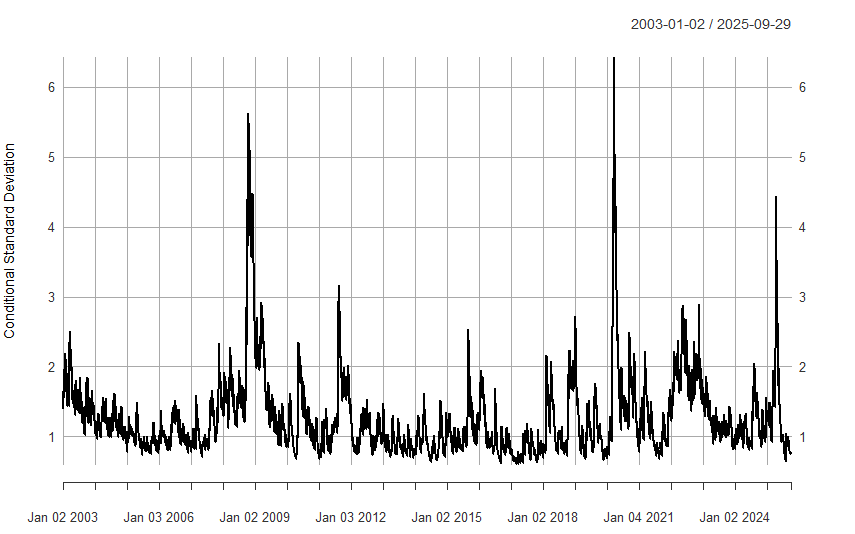

Figure: Estimated conditional standard deviation based on the AR(1)-GARCH(1,1) model for the NASDAQ 100 excess returns.

Residual diagnostics show that:

- There is no remaining autocorrelation in the residuals and squared residuals (based on the Ljung-Box and the McLeod-Li tests and residual autocorrelation coefficients).
- Without presenting details, (weighted) ARCH LM test tests the null hypothesis that there is no signs of remaining conditional heteroskedasticity in the residuals $\widehat{u}_t$. In the estimation result above, the p-values of the ARCH LM tests show that the parsimonious AR(1)-GARCH(1,1) is an adequate model.
- There is some deviation from the normality assumption in the (standardized) residuals. This suggests that the estimates should be interpreted as QMLEs, as above.

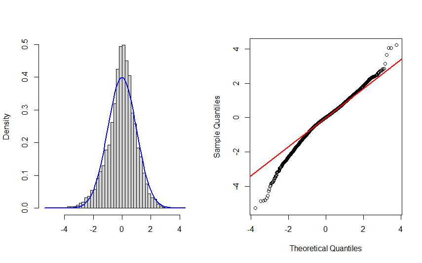

Figure: Histogram and Q-Q plot of (standardized) residuals.

## 9.5 Forecasting

Assume observations are available up to time $t$ and the object of interest is to forecast the future values of $y_{t+k}$ ($k\geq1$). In addition to stationarity, assume that $\mathsf{E}\left(y_{t}^{2}\right)<\infty$.

**Volatility forecasts**. Concerning forecasting the conditional variance, we assume that observations up to and including time $t$ (i.e. the forecast origin at time $t$) are available, and that forecasts for $h_{t+1}$, $h_{t+2}$, are desired.

As $h_{t+1}$ is a (deterministic) function of the variables $y_{t},y_{t-1},\ldots$, and thus the first conditional variance we need to forecast is $h_{t+2}$. For simplicity, let us concentrate on the GARCH(1,1) case. Taking conditional expected values (conditional on $\left\{y_{t},y_{t-1},\ldots\right\}$) of both sides of
$$\begin{equation*}
h_{t+2}=\omega+\beta_1 h_{t+1}+\alpha_1 u_{t+1}^{2}
\end{equation*}$$
yields the optimal (in the mean squared error sense) forecast of $h_{t+2}$ as
$$\begin{equation*}
\mathsf{E}_{t}\left(h_{t+2}\right)=\omega + \beta_1\mathsf{E}_{t}\left(h_{t+1}\right)+\alpha_1 \mathsf{E}_{t}\left(u_{t+1}^{2}\right),
\end{equation*}$$
where $\mathsf{E}_{t}\left(h_{t+1}\right)=h_{t+1}$ (see CEV4). Moreover, we obtain that (see CEV2 and CEV4)
$$\begin{equation*}
\mathsf{E}_{t}\left(u_{t+1}^{2}\right) = \mathsf{E}_{t}\left(h_{t+1}\varepsilon_{t+1}^{2}\right)=h_{t+1}\mathsf{E}_{t}\left(\varepsilon_{t+1}^{2}\right)=h_{t+1}\mathsf{E}\left(\varepsilon_{t+1}^{2}\right)=h_{t+1},
\end{equation*}$$
so that
$$\begin{equation*}
\mathsf{E}_{t}\left(h_{t+2}\right)=\omega+(\alpha_1+\beta_1)h_{t+1}.
\end{equation*}$$

When the forecast horizon is $k\geq3$, in a similar fashion we obtain
$$\begin{equation*}
\mathsf{E}_{t}\left(h_{t+k}\right) = \omega+\beta_1 \mathsf{E}_{t}\left(h_{t+k-1}\right)+\alpha_1 \mathsf{E}_{t}\left(u_{t+k-1}^{2}\right),
\end{equation*}$$
and finally
$$\begin{equation*}
\mathsf{E}_{t}\left(h_{t+k}\right)=\omega \sum_{j=0}^{k-2}\left(\alpha_1+\beta_1\right)^{j}+\left(\alpha_1+\beta_1\right)^{k-1}h_{t+1}, \quad k=2,3,\ldots,
\end{equation*}$$
where $h_{t+1}$ is a function of variables $\left\{y_{t},y_{t-1},\ldots\right\}$ known at the time when forecasts are constructed.

In practice,

- the unknown parameters $\alpha_1$, $\beta_1$, and $\omega$ have to be replaced by corresponding estimates.
- Unlike in ARMA models, the quantity being predicted is now unobserved, although it can be computed using GARCH model equation for all $t\geq1$ as long as parameter values and required initial values for $h_t$ and $y_t$ are available. A common choice in practice is to use the sample variance of the observed time series as the initial value $h_{0}$. In the stationary case, the effect of the initial values diminishes as $t$ increases.
- Forecasting with a more general GARCH($r,s$) model is carried out in principle in the same way as outlined above, although the resulting forecasting formulae become more cumbersome. Deriving interval predictions is also complicated, one major reason for this being that the distribution of the conditional variance deviates heavily from a Gaussian distribution.
- Overall, **volatility forecasting** is a separate and a large area in financial econometrics that we are not considering in this course more detail.

## 9.6 GARCH-in-mean model

In the **GARCH-in-mean** (**GARCH-M**) **model**, the conditional variance is allowed to directly affect the conditional mean as well.

To simplify the notation, let us consider the first-order special case, i.e., the AR(1)-GARCH(1,1)-M model
$$\begin{eqnarray*}
\nonumber y_t = \nu + \phi_1 y_{t-1} + \delta g(h_t) + u_t, \quad
h_t = \omega + \alpha_1 u^2_{t-1} + \beta_1 h_{t-1},
\end{eqnarray*}$$
where, as before, $u_t = y_t - \nu - \phi_1 y_{t-1} - \delta g(h_t)$, but now the conditional variance $h_t$ also affects the level of $y_t$ through the function $g(h_t)$. Depending on the situation, the “in-mean effect” can be defined

- $g(h_t) = h_t$,
- $g(h_t) = \sqrt{h_t}$, or
- $g(h_t) = \mathrm{log} (h_t)$.

A positive coefficient $\delta$ means that the value of $y_t$ increases when the conditional variance increases.

- As an extension of the GARCH-M version presented above, the orders of the AR and GARCH models can naturally be greater than 1.
- In general, instead of the AR($p$) model, another suitable model for the conditional mean of $y_t$ can be used.
- Similarly, a model other than GARCH(1,1) can be chosen for the GARCH part.

The GARCH-M model is used, for example, in financial econometrics (empirical finance) to model the fundamental risk-return relation, where risk (here volatility, measured by the conditional variance or its transformation) is allowed to directly affect the expected return of a security.

**Empirical example (continue)**. Let us consider an GARCH-in-mean extension of the AR(1)-GARCH(1,1) model (with Gaussian innovations) obtained above for the NASDAQ 100 excess stock returns. That is we consider the following model for the conditional mean
$$\begin{eqnarray*}
\nonumber y_t = \nu + \phi_1 y_{t-1} + \delta \sqrt{h_t} + u_t.
\end{eqnarray*}$$
That is we include the conditional standard deviation to the conditional mean.

- This is one possible way to examine the fundamental risk-return relationship in (excess) stock returns (here NASDAQ 100 index). The positive risk-return relation is the cornerstone of financial economics.

QMLE-based estimation result obtained with the rugarch package on AR(1)-GARCH(1,1)-M model:

```markdown
Robust Standard Errors:
        Estimate  Std. Error   t value Pr(>|t|)
mu      0.000963    0.043060  0.022373 0.982151
ar1    -0.043796    0.012596 -3.477072 0.000507
archm   0.085665    0.040331  2.124019 0.033669
omega   0.035116    0.006429  5.462160 0.000000
alpha1  0.104836    0.012296  8.526169 0.000000
beta1   0.875948    0.012702 68.958838 0.000000
```

Therefore, it appears that the estimated coefficient of $\delta$, here “archm”, is positive and also statistically significant at the 5 % significance level based on the robust $t$-value. Even though the statistical significance is not very strong, the positive risk-return relation can be approved.

- Residual diagnostics of this GARCH-M model is essentially the same as obtained without the in-mean effect, and hence the model seems adequate.

## 9.7 R Lab

# 10 Multivariate time series models

So far, we have considered univariate models, such as AR and ARMA models, where only one time series is analyzed at hand.

- That is the “pure time series approach” as formulated at the beginning of the material.

Modelling multiple time series simultaneously is, however, often much more of interest in different applications. Using multivariate time series implies larger predictive information, which may improve the accuracy of empirical analyses such as forecasts.

We will next briefly introduce three important extensions to the univariate models, which have extensively been used in the econometric (statistics) literature:

- Linear (predictive) regressions with time series variables
- Vector autoregressive (VAR) models
- Cointegration (in connection to nonstationary time series)

## 10.1 Predictive regressions: Background and starting point

Let us assume, for simplicity, throughout this section that we have two sets of variables: $y_t$ is still the dependent variable and one ($M=1$) or generally multiple ($M>1$) additional predictive variables $(x_{1t}, \ldots, x_{Mt})$. We are mainly interested in a linear regression model, but now with time series, where the lags of predictive variables are used as predictors. For example, one possible model specification is
$$\begin{equation*}
y_t= \beta_0 + x_{1, t-1} \beta_1 + \cdots + x_{M, t-1} \beta_M + u_t \equiv \boldsymbol{x}^{\prime}_t \boldsymbol{\beta} + u_t,
\end{equation*}$$
where $\boldsymbol{x}_t$ contains predictors and $u_t$ is $\mathsf{iid}$ error term or at least serially uncorrelated and uncorrelated with the regressors $\boldsymbol{x}_t$. The parameters of this type of model, contained in $\boldsymbol{\beta}$, can be estimated by the (conditional) least squares (in a similar fashion as discussed, e.g., in connection to the AR($p$) model. That is minimizing the OLS criterion (with required initial values)
$$\begin{equation*}
\widehat{\boldsymbol{\beta}} = \mathrm{arg}\,\underset{\boldsymbol{\beta}}{\mathrm{min}} \sum_{t=1}^{T} (y_t -\boldsymbol{x}^{\prime}_t \boldsymbol{\beta})^2,
\end{equation*}$$
resulting in the OLS estimator (and estimates)
$$\begin{equation*}
\widehat{\boldsymbol{\beta}} = \Big(\sum_{t=1}^{T} \boldsymbol{x}_t \boldsymbol{x}^{\prime}_t \Big)^{-1} \sum_{t=1}^{T} \boldsymbol{x}_t y_{t}.
\end{equation*}$$

In contrast to the model specification above, at times we are also considering other linear regressions:

- Simultaneous values of predictive variables, instead of their lags, can be used as predictors in certain circumstances and applications. As an example and for simplicity $K=1$, the model can be
  $$\begin{equation*}
  y_t= \beta_0 + x_{1t} \beta_1 + u_t.
  \end{equation*}$$
- Including also the lags of $y_t$ on the right hand side of the model equation. These are then autoregressive models with additional predictive variables, often denoted by ARX or ADL (Autoregressive Distributed Lag) models. One example of such a model is
  $$\begin{equation*}
  y_t= \beta_0 + \phi_1 y_{t-1} + \beta_1 x_{1, t-1} + u_t,
  \end{equation*}$$
  which can be straightforwardly extended by allowing more lags of $y_t$ and $x_{1t}$.
- Including an autocorrelated error term is also possible. That is, especially in the somewhat already distant literature $u_t = \phi u_{t-1} + \varepsilon_t, \, \varepsilon_t \thicksim \mathsf{iid}(0,\sigma^2)$ (see, e.g., Verbeek, Chapters 4.6-4.7). Notice that adding the lags of $y_t$, we can try to address the possible autocorrelation in the error term.

Subsequent (sub)sections are organized as follows:

- The case where all the (dependent and predictive/explanatory) variables are stationary variables.
- When there are also nonstationary variables present.
- At end of this section, we also briefly introduce the case where $K$ is high-dimensional. That is the number of predictive variables can be very large. Otherwise in this section, we restrict ourselves to the idea that have only one or only a few predictive variables (i.e. $K$ is relatively small).

## 10.2 Stationary variables

Let us start with the case (assumption) that all variables $y_t$ and $x_{1t}, \ldots, x_{Kt}$ are stationary, which means that their respective time series plots do not contain strong stochastic or deterministic trends. Broadly speaking then, under the following two conditions $\mathrm{(i)}$ and $\mathrm{(ii)}$, the OLS estimator $\widehat{\boldsymbol{\beta}}$ of the parameters of interest in a linear regression model
$$\begin{equation*}
y_t= \boldsymbol{x}^{\prime}_t \boldsymbol{\beta} + u_t,
\end{equation*}$$
where $\boldsymbol{x}_t = (x_{1t}, \ldots, x_{Mt})$ or, e.g., $\boldsymbol{x}_t = (x_{1, t-1}, \ldots, x_{M, t-1})$, is consistent and asymptotically normal when

- $\mathrm{(i)}$ The error term $u_t$ is serially uncorrelated and uncorrelated with the regressors included in $\boldsymbol{x}_t$.
- $\mathrm{(ii)}$ All the regressors in $\boldsymbol{x}_t$ are either deterministic or stationary random variables.

If not otherwise mentioned, we assume that $\mathrm{(i)}$ and $\mathrm{(ii)}$ are valid.

After estimation of the model, the same residual diagnostic methods as for ARMA models are available for assessing the residuals and hence the adequacy of the model. The resulting asymptotic distribution result for the OLS estimator is
$$\begin{equation*}
\sqrt{T} (\widehat{\boldsymbol{\beta}} - \boldsymbol{\beta}) \underset{d}{\longrightarrow} \mathsf{N}\Bigg(\boldsymbol{0}, \Big(\sum_{t=1}^{T} \boldsymbol{x}_t \boldsymbol{x}^{\prime}_t \Big)^{-1} \Bigg),
\end{equation*}$$
where $\underset{d}{\longrightarrow}$ denotes converge in distribution. It turns out that, in fact, even (mild) autocorrelation of the residuals can be accepted without losing many of the useful asymptotic properties of the (conditional) OLS estimator. If autocorrelation occurs after the initial formation of the model, we can proceed in essentially two different ways (see detailed discussion below):

- form a (linear) model where the error term is autocorrelated.
- (preferable alternative) adjust the covariance matrix of the estimated parameters $\widehat{\boldsymbol{\beta}}$ (see below)

## 10.3 Forecasting with predictive variables

Let us consider forecast construction more detail. When attempting to predict the value of $y_{t+h}$ with external predictive variables, additional complications arise especially when the forecast horizon $h$ lengthens. As an example, consider a simple model (the main arguments generalize to more general models) containing only two lags of one predictive variable $x_t$
$$\begin{equation*}
y_t= \beta_0 + \beta_1 x_{1, t-1} + \beta_2 x_{1, t-2} + u_t.
\end{equation*}$$
As in the ARMA case, one-step forecast is the conditional expectation given the information set at time $t$. That is
$$\begin{equation*}
\mathsf{E}_t(y_{t+1}) = \beta_0 + \beta_1 x_{1t} + \beta_2 x_{1,t-1}.
\end{equation*}$$
From this, it is immediately apparent that additional challenges arise if the forecast horizon $h$ lengthens longer than one ($h=1$). In other words, multi-step forecasts ($h>1$) seem to require forecasts for $x_{1t}$.

- Vector autoregressive models provide one alternative to solve this problem when building a joint (multiple-equation) model for $y_t$ and $x_{1t}$

An alternative to this is to use predictive models that are specific to each forecast horizon. In that case, when using the predictive information available at time $t$, we can specify
$$\begin{equation*}
y_{t+h}= \beta_0 + \beta_1 x_{1t} + \beta_2 x_{1,t-1} + e_{t+h},
\end{equation*}$$
where $e_t$ is a zero-mean error term and the forecast can then be constructed “directly” as
$$\begin{equation*}
\mathsf{E}_t(y_{t+h})= \beta_0 + \beta_1 x_{1t} + \beta_2 x_{1,t-1}.
\end{equation*}$$
Naturally here the parameters $\boldsymbol{\beta} = (\beta_0, \beta_1, \beta_2)$, and finally their estimates, are then specific to the forecast horizon $h$.

- The properties of the error term $e_t$ can be complicated due to overlapping forecasting horizon from the forecast origin at time $t$ to $t+h$.
- What is introduced above for a simple model containing only one predictive variable can be generalized straightforwardly to the case where we have $K$ predictors such as more lags of $y_t$ as predictors.

Overall, this same principle of $h$-period predictive models can be seen as a building block for various extended predictive regressions such as the ones containing **elements of machine and statistical learning**.

## 10.4 Extra: Regularized predictive regressions

Let us briefly focus on predicting $y_{t+h}$ at time $t$ (that is the forecast origin) given the collection of $K$ predictive variables in $\boldsymbol{x}_t = (x_{1t},\ldots,x_{Mt})$, which may also contain some lagged values of $y_t$ (as discussed above).

- This is the predictive regression we already briefly considered above, but now predicting with high-dimensional predictors.

**The challenge of big dependent data**. The focus here is on big dependent data, meaning we’re dealing with a large collection of potential predictors where the number of variables, $M$, can be substantial.

- In some cases, $M$ might even be greater than the sample length $T$ ($M > T$) used for estimating the model parameters.
- Here for “big dependent data” we mean that the number of (predictive) time series is large. “Dependent” refers to autocorrelation (serial correlation) in the data. In this section, our dependent variable $y_t$ is still scalar-valued (i.e. only one time series) and hence we consider single-equation models.

**Traditional limitation**. When $M$ is large relative to $T$, traditional estimation techniques, like Ordinary Least Squares (OLS), as introduced above, fail or produce highly unstable and unreliable results.

- The classic OLS estimator is not well-defined if $M > T$ (instead $M < < T$).
- Even if $M$ is less than $T$ but still large, the resulting model can suffer from overfitting, where it fits the noise in the historical data too closely, leading to poor out-of-sample forecasting performance.

**Need for structure**: To overcome the curse of dimensionality - the problems that arise when the number of variables grows - we need methods that can impose structure or constraints on the predictive relationship. This is essential for selecting the most relevant predictors and stabilizing the parameter estimates in a data-rich environment.

**Regularized estimation and sparsity**. To enable effective predictive regressions in this high-dimensional setting, where the predictor space can be very large, a class of techniques known as regularized estimators is employed. Regularization involves adding a penalty term to the standard loss function (like the sum of squared errors) that we aim to minimize. This penalty discourages the model from assigning large values to the coefficients, effectively shrinking them towards zero. Key examples (briefly without details in this course):

- **Ridge estimator**: This technique adds a penalty proportional to the sum of the squared coefficients. It stabilizes the estimates by shrinking all coefficients but doesn’t set any exactly to zero.
- **LASSO** (Least Absolute Shrinkage and Selection Operator): This method uses a penalty based on the sum of the absolute values of the coefficients. Crucially, the LASSO has the ability to perform automatic variable selection by setting the coefficients of irrelevant predictors from $\boldsymbol{x}_t$ exactly to zero. This produces a sparse model, meaning that only a few (the most important) predictors are ultimately used.
- **Elastic Net**: This is a hybrid that combines the penalties of both Ridge and LASSO. It’s often used to leverage the variable selection of LASSO while retaining the grouping effect and stability of Ridge, especially when predictors are highly correlated.

**Relevance**: These estimators are foundational in modern forecasting and (statistical) machine learning, particularly when integrating vast amounts of data—such as financial indicators, survey data, or text-based predictors—into an economic forecasting model. They provide a principled way to manage the trade-off between bias (from shrinkage) and variance (from the large number of predictors) to achieve superior out-of-sample forecasting accuracy.

A more detailed treatment of these specific estimators is reserved for the **Advanced Time Series Econometrics course**.

# 11 Basics of vector autoregression

Univariate ARMA models can be generalized to the multivariate case where **multiple time series are analyzed simultaneously**. In this course, we concentrate on a brief introduction of basic ideas of a **vector autoregressive (VAR) model**. The VAR model provides a very common framework for analyzing time series dynamics, such as the effects of random shocks (e.g., changes in economic policy or technology).

- VAR model and its statistical details will be considered more detail in **Advanced Time Series Econometrics course**.
- VAR model and its very important role for applied macroeconometrics and empirical macroeconomics will be considered more detail in **Macroeconometrics course**.

## 11.1 VAR($p$) process

Let us start with a bivariate model. That is we have two stationary time series $y_{1t}$ and $y_{2t}$ with $\mathsf{E}(y_{1t}) = \mu_1$ and $\mathsf{E}(y_{2t})=\mu_2$. **A bivariate (i.e., a two-variable) first-order VAR process** (i.e., a bivariate **VAR(1) process**) is given as
$$\begin{eqnarray*}
y_{1t} &=& \nu_1 + a_{11} y_{1, t-1} + a_{12} y_{2, t-1} + u_{1t} \\
y_{2t} &=& \nu_2 + a_{21} y_{1, t-1} + a_{22} y_{2, t-1} + u_{2t},
\end{eqnarray*}$$
where $u_{1t}$ and $u_{2t}$ are two error terms (independent of the history of $y_{1t}$ and $y_{2t}$) that may be correlated. In a matrix notation, the VAR(1) process can be rewritten
$$\begin{eqnarray*}
\left[ \begin{array}{c}
y_{1t} \\
y_{2t} \end{array} \right] =
\left[ \begin{array}{c}
\nu_{1} \\
\nu_{2} \end{array} \right] +
\left[ \begin{array}{cc}
a_{11} & a_{12} \\
a_{21} & a_{22} \end{array} \right]
\left[ \begin{array}{c}
y_{1, t-1} \\
y_{2, t-1} \end{array} \right] +
\left[ \begin{array}{c}
u_{1t} \\
u_{2t} \end{array} \right].
\end{eqnarray*}$$

Equivalently,
$$\begin{equation*}
\boldsymbol{y}_t = \boldsymbol{\nu} + \boldsymbol{A}_1 \boldsymbol{y}_{t-1} + \boldsymbol{u}_t,
\end{equation*}$$
where now $\boldsymbol{y}_t = (y_{1t}, y_{2t})$, $\boldsymbol{\nu}_t = (\nu_{1}, \nu_{2})$ and $\boldsymbol{u}_t = (u_{1t}, u_{2t})$ are two $2 \times 1$ vectors.

- In this notation, likewise throughout this material, with bolded font we emphasize vectors and matrices, to distinguish scalar-valued components and processes.

As an extension of two-variable and first-order case, **$K$-variable VAR($p$) process** is
$$\begin{equation*}
\boldsymbol{y}_t = \boldsymbol{\nu} + \boldsymbol{A}_1 \boldsymbol{y}_{t-1} + \cdots + \boldsymbol{A}_p \boldsymbol{y}_{t-p} + \boldsymbol{u}_t, \quad \boldsymbol{u}_t \thicksim \mathsf{iid}(\boldsymbol{0}, \boldsymbol{\Sigma}_u)
\end{equation*}$$
where $y_t= (y_{1t} \, \cdots \, y_{Kt})$ is a $K \times 1$ vector of variables and $\boldsymbol{A}_1, \ldots, \boldsymbol{A}_p$ are $K \times K$ coefficient matrices. In other words, the VAR($p$) process depends on the $p$ lags of $y_{1t}, \ldots, y_{Kt}$. The error term (“shock” or “innovation”) $\boldsymbol{u}_t = (u_{1t}, \ldots , u_{Kt})$ is an unobserved $K \times 1$ (vector) iid process.

- Hence $\mathsf{E}(\boldsymbol{u}_t)=\boldsymbol{0}$, $\mathsf{E}(\boldsymbol{u}_t \boldsymbol{u}_t^{\prime}) = \boldsymbol{\Sigma}_u$, and $\mathsf{E}(\boldsymbol{u}_t \boldsymbol{u}_s^{\prime}) = \boldsymbol{0}, \, s \neq t$.
- The bivariate and more general model show the basic idea: The idea of the VAR($p$) model is to regress each component of $y_t$ on its own lags and on the lags of the other components. The model can describe lagged or dynamic dependencies among variables. For example, one may ask how $y_{2t}$ affects the future path of $y_{1t}$, and other way round.

**A companion form**: The VAR($p$) process can be rewritten
$$\begin{eqnarray*}
\boldsymbol{Y}_t = \boldsymbol{\nu}^* + \mathbf{A} \boldsymbol{Y}_{t-1} + \boldsymbol{U}_t,
\end{eqnarray*}$$
where $\boldsymbol{Y}_t = [\boldsymbol{y}^{\prime}_t \, \cdots \, \boldsymbol{y}^{\prime}_{t-p+1}]^{\prime}$ and $\boldsymbol{\nu}^{*} = [\boldsymbol{\nu}^{\prime} \,\, \boldsymbol{0}^{\prime} \cdots \, \boldsymbol{0}^{\prime}]^{\prime}$ are ($Kp \times 1$) and $\boldsymbol{U}_t = [\boldsymbol{u}^{\prime}_t \,\, \boldsymbol{0}^{\prime} \cdots \, \boldsymbol{0}^{\prime}]^{\prime}$ are ($Kp \times 1$) vectors, and
$$\begin{equation*}
\mathbf{A}=
\left[
\begin{array}{ccccc}
\boldsymbol{A}_1 & \boldsymbol{A}_2 & \cdots & \boldsymbol{A}_{p-1} & \boldsymbol{A}_p \\
\boldsymbol{I}_K & \boldsymbol{0}_K & \cdots & \boldsymbol{0}_K & \boldsymbol{0}_K \\
\boldsymbol{0}_K & \boldsymbol{I}_K & \cdots & \boldsymbol{0}_K & \boldsymbol{0}_K \\
\vdots & & \ddots & \vdots & \vdots \\
\boldsymbol{0}_K & \boldsymbol{0}_k & \cdots & \boldsymbol{I}_K & \boldsymbol{0}_K \\
\end{array}\right] \quad (Kp \times Kp)
\end{equation*}$$
In other words,
$$\begin{equation*}
\left[
\begin{array}{c}
\boldsymbol{y}_t \\
\boldsymbol{y}_{t-1} \\
\vdots \\
\boldsymbol{y}_{t-p+1}
\end{array}\right] =
\left[
\begin{array}{c}
\boldsymbol{\nu} \\
\boldsymbol{0} \\
\vdots \\
\boldsymbol{0}
\end{array}\right]
+
\left[
\begin{array}{ccccc}
\boldsymbol{A}_1 & \boldsymbol{A}_2 & \cdots & \boldsymbol{A}_{p-1} & \boldsymbol{A}_p \\
\boldsymbol{I}_K & \boldsymbol{0}_K & \cdots & \boldsymbol{0}_K & \boldsymbol{0}_K \\
\boldsymbol{0}_K & \boldsymbol{I}_K & \cdots & \boldsymbol{0}_K & \boldsymbol{0}_K \\
\vdots & & \ddots & \vdots & \vdots \\
\boldsymbol{0}_K & \boldsymbol{0}_K & \cdots & \boldsymbol{I}_K & \boldsymbol{0}_K \\
\end{array}\right]
\left[
\begin{array}{c}
\boldsymbol{y}_{t-1} \\
\boldsymbol{y}_{t-2} \\
\vdots \\
\boldsymbol{y}_{t-p}
\end{array}\right]
+
\left[
\begin{array}{c}
\boldsymbol{u}_t \\
\boldsymbol{0} \\
\vdots \\
\boldsymbol{0}
\end{array}\right]
\end{equation*}$$
indicating that there holds equalities $\boldsymbol{y}_t = \boldsymbol{\nu} + \boldsymbol{A}_1 \boldsymbol{y}_{t-1} + \cdots + \boldsymbol{A}_p \boldsymbol{y}_{t-p} + \boldsymbol{u}_t$, $\boldsymbol{y}_{t-1} = \boldsymbol{y}_{t-1}$, and so on to $\boldsymbol{y}_{t-p+1}= \boldsymbol{y}_{t-p+1}$.

**Lag-operator** and the **lag-polynomial presentation of the VAR($p$)**. Define again the lag-operator as $B^k \boldsymbol{x}_t = \boldsymbol{x}_{t-k}$, $k=0,\pm 1, \pm 2, \ldots$, where $\boldsymbol{x}_t$ might be a vector. Therefore, using the lag-operators, the VAR($p$) process can be rewritten
$$\begin{eqnarray*}
\boldsymbol{A}(B) \boldsymbol{y}_t = \boldsymbol{\nu} + \boldsymbol{u}_t,
\end{eqnarray*}$$
where $\boldsymbol{A}(B) = (\boldsymbol{I}_n - \boldsymbol{A}_1 B - \cdots - \boldsymbol{A}_p B^p)$.

**Stationarity (stability) of the VAR($p$) process**. A VAR($p$) process is (strictly) stationary (stable) (given $\boldsymbol{u}_t \thicksim \mathrm{iid}(\boldsymbol{0}, \boldsymbol{\Sigma}_u)$) if the roots of the determinant
$$\begin{equation*}
\mathrm{det} \Big(\mathbf{I}_K - \boldsymbol{A}_1 z - \cdots - \boldsymbol{A}_p z^p \Big) = 0
\end{equation*}$$
are outside the unit circle in absolute value (i.e., $|z| > 1$).

Notice, however, that many statistical software packages, including the **vars* package in R**, use an alternative but equivalent presentation.

- They first represent the VAR(p) process in its companion form (see above). The stability of the system is then determined by the eigenvalues of the companion matrix $\mathbf{A}$.
- In vars package and VAR-function, the part “Roots of the characteristic polynomial” reported by R are precisely these eigenvalues. The key relationship is that these eigenvalues of the companion matrix are the reciprocals of the roots of the determinant polynomial. Therefore, the two conditions are equivalent:
  - Roots of $\mathrm{det} \Big(\mathbf{I}_n - \boldsymbol{A}_1 z - \cdots - \boldsymbol{A}_p z^p \Big) = 0$ are outside the unit circle ($|z| > 1$).
  - Eigenvalues of the companion matrix $\mathbf{A}$ are inside the unit circle ($|\lambda| < 1$).
- So, when using R’s output, we check if the moduli of the reported roots (the eigenvalues) are **all less than 1** to confirm that the VAR model is stable.

**Linear process**. As the AR($p$) process, the stationary (stable) VAR($p$) process can be written
$$\begin{equation*}
\boldsymbol{y}_t = \boldsymbol{\mu} + \sum_{j=0}^{\infty} \boldsymbol{\Psi}_j \boldsymbol{u}_{t-j}= \boldsymbol{\Psi}(B) \boldsymbol{u}_t,
\end{equation*}$$
where $\boldsymbol{\Psi}(B) = [\boldsymbol{A}(B)]^{-1} = \boldsymbol{\Psi}_0 + \boldsymbol{\Psi}_1 B + \boldsymbol{\Psi}_2 B^2 + \cdots$ defines matrix-valued lag-polynomial. In addition to this linear process presentation, the sequence $\boldsymbol{\Psi}_0, \boldsymbol{\Psi}_1, \boldsymbol{\Psi}_2, \ldots$ have also other important role in macroeconometrics. It turns out that the matrix $\boldsymbol{\Psi}_s$ ($\boldsymbol{\Psi}_0 = \boldsymbol{I}_K$) measures the effect of one-unit increase in $u_{jt}$ upon $y_{i,t+s}$, , $i,j=1,\ldots,K$, or equivalently
$$\begin{equation*}
\boldsymbol{\Psi}_s = \frac{\partial \boldsymbol{y}_{t+s}}{\partial \boldsymbol{u}^{\prime}_t}.
\end{equation*}$$
A function of elements $\boldsymbol{\Psi}_0$, $\boldsymbol{\Psi}_1$, $\boldsymbol{\Psi}_2, \ldots$ is the **(forecast error) impulse response function** (IRF) of the VAR($p$) process.

- In other words, the row $i$, column $j$ element of $\boldsymbol{\Psi}_s$ gives the effect of a one-unit increase in the error term of the $j$th variable at time $t$ on the $i$th variable at time $t+s$, holding all other errors constant.
- For instance, the first column of $\Psi_1$ gives the effect in period 1 of a unit increase in the error term of the first variable (first shock) in period 0 on each variable in the system.
- Especially in (structural) macroeconometrics, the VAR model is extended by economic identification assumption, which leads to **structural VAR models** and identified impulse response functions. These will be considered more detail in **Macroeconometrics** course.

As in the univariate case, here defined element-by-element, due to the typical assumption $\boldsymbol{\Psi}_s \longrightarrow \boldsymbol{0}, \, s \longrightarrow \infty$, the effects decay in time. In empirical analysis, the unknown $\boldsymbol{\Psi}_s$ must also be replaced by their estimates, obtained from the estimation result of the VAR model.

**VAR($p$) model: Estimation and model selection**. The stationary VAR($p$) model can be estimated by ordinary least squares (OLS).

- More specifically, estimation can be done equation by equation by OLS (cf. the model structure).
- If the distribution of $\boldsymbol{u}_t$ is known (asssumed to be known), the model can also be estimated by the method of maximum likelihood (ML). Under normality assumption, that is $\boldsymbol{u}_t \sim \mathsf{nid}(\boldsymbol{0}, \boldsymbol{\Sigma}_u)$, the conditional ML estimator is numerically equivalent to the OLS estimator.
- The OLS estimator is consistent and asymptotically normally distributed. Thus, the $t$-statistics of the parameter estimates can be used as usual to test for the statistical significance of individual parameter coefficients.

As for the univariate AR($p$) model, there are several approaches to determine the lag length $p$ for the VAR($p$) model.

- Sequential testing procedure (cf. the sequential testing for univariate models)
- Information criteria (including intercept parameters):
  - AIC: $\mathrm{log} (\mathrm{det}(\boldsymbol{\Sigma}_u)) + \frac{2}{T} K(Kp+1)$
  - BIC: $\mathrm{log} (\mathrm{det}(\boldsymbol{\Sigma}_u)) + \frac{\mathrm{log}(T)}{T} K(Kp+1)$

For the competing models (recall that exactly the same sample period must be used!) the one with the lowest value of the selected information criterion is the selected (preferable) model.

**VAR($p$): Model selection and residual diagnostics**

Overall, the model selection can be based on the specification cycle presented in the case of univariate AR models but modified suitable to VARs. However, due to multiple time series and hence more complicated dynamic interrelationships between the variables, autocorrelation functions cannot be directly used to select the lag length $p$.

- Especially information criteria, such as AIC and BIC, can be used like in the univariate case.
- At times the lag length selections correspond the frequency of the data. That is, for the quarterly data $p=4$ and for monthly data $p=12$.

**The adequacy of the selected and estimated VAR($p$) model** can be evaluated by diagnostic checks (like for ARMA models). A well-specified model should capture all the systematic, linear dynamics present in the (multivariate) time series data. The primary goal of these checks is to determine if there is any significant autocorrelation left in the vector of residuals $\widehat{\boldsymbol{u}}_t = \boldsymbol{y}_t - \widehat{\boldsymbol{y}}_t$, where $\widehat{\boldsymbol{y}}_t$ are the fitted values of the selected VAR model.

- If autocorrelation is still present in residuals, it means the model has failed to capture some of the predictable patterns in the data, making it unreliable for forecasting or structural analysis.

To formally test for remaining autocorrelation in the residuals, we use a multivariate extension of the Ljung-Box test. This is called the **Portmanteau test**. It jointly examines whether a group of residual autocovariance matrices up to a certain lag are statistically different from zero. The **null hypothesis** ($H_0$) of the test is that there is no serial correlation in the residuals up to a specified lag $H$. The Portmanteau test statistic, often denoted as $Q_H$, is calculated as follows:
$$\begin{equation*}
Q_H = T \sum_{h=1}^{H} \text{tr}(\widehat{C}_h^{\prime} \widehat{C}_0^{-1} \widehat{C}_h \widehat{C}_0^{-1}),
\end{equation*}$$
where $\hat{C}_j = \frac{1}{T} \sum_{t=j+1}^{T} \widehat{u}_t \widehat{u}_{t-j}^{\prime}$ is the estimated residual autocovariance matrix at lag $j$ and $\text{tr}(\cdot)$ is the trace operator, which sums the diagonal elements of a matrix. Under the null hypothesis of no serial correlation, the $Q_H$ statistic approximately follows a $\chi^2$-distribution with $K^2(H-p)$ degrees of freedom and the associated $p$-value can be constructed.

Should the model fail in the Portmanteau test or overall in diagnostic checking, the model should be respecified, such as to increase the lag length of the model (e.g., from VAR($p$) to VAR($p+1$) or higher) and re-estimate it. The logic is that by including more past values, the model can better capture the complex temporal dependencies in the data. After respecification, the diagnostic checks must be performed again to ensure the new model is adequate.

However, especially with complex multivariate data, it is often challenging to find a model that can be considered completely adequate from a diagnostic perspective. When the diagnostic checks indicate that the model is misspecified (for instance, due to some persistent residual autocorrelation), the standard assumptions for maximum likelihood estimation are violated. In such cases, the parameter estimates can be interpreted as Quasi-Maximum Likelihood Estimates (QMLE), a concept that was introduced on a general level in the AR-GARCH section.

**VAR($p$): Forecasting**

Similarly as in the univariate AR($p$) model, forecasts can be obtained as conditional expectations, conditional on the information at time $t$. The properties CEV1–CEV4 of the conditional expectation can be extended to the vector-valued case straigtforwardly (element-by-element treatment).

- One-period-ahead forecasts with the VAR($p$):
  $$\begin{equation*}
  \mathsf{E}_t(\boldsymbol{y}_{t+1}) = \boldsymbol{\nu} + \boldsymbol{A}_1 \boldsymbol{y}_t + \cdots + \boldsymbol{A}_p \boldsymbol{y}_{t-p+1}.
  \end{equation*}$$
- Multiperiod $h$-step forecasts can be obtained iteratively following the recursion (cf. the AR($p$) case):
  $$\begin{equation*}
  \mathsf{E}_t(\boldsymbol{y}_{t+h}) = \boldsymbol{\nu} + \boldsymbol{A}_1 \mathsf{E}_t(\boldsymbol{y}_{t+h-1}) + \cdots + \boldsymbol{A}_p \mathsf{E}_t(\boldsymbol{y}_{t+h-p}),
  \end{equation*}$$
  where $\mathsf{E}_t(\boldsymbol{y}_{t+h-j}) = \boldsymbol{y}_{t+h-j}$ for $h \le j$.

Similarly as in the univariate AR models, to include nonzero mean vector to the VAR model is assumed above. Alternatively, you can construct the VAR model for the deamed time series and add the mean vector to the forecasts obtained with the VAR model with demeaned data.

**Empirical example**. Consider an application of a VAR model to the classic dataset from Stock and Watson (2001), which is a benchmark for macroeconomic analysis.

- See J.H. Stock and M.W. Watson (2001). Vector autoregressions. Journal of Economic Perspectives, 115(4), 101–115.

The VAR model utilizes three ($K=3$) key quarterly U.S. macroeconomic variables:

- Inflation: Measured as the percent change from the preceding period in the Gross Domestic Product Implicit Price Deflator, expressed at a seasonally adjusted annual rate.
- Unemployment: The seasonally adjusted quarterly average of the civilian unemployment rate.
- Interest Rate: The quarterly average of the effective Federal Funds Rate, which is not seasonally adjusted.

These three series are modeled as an interdependent system where each variable is influenced by its own past values and the past values of the other two variables. The following analysis covers the sample period from 1960:Q1 to 2000:Q4 as in Stock and Watson (2001).

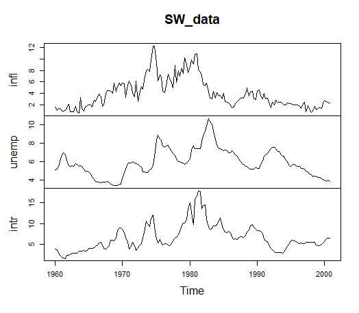

Figure: Stock and Watson (2001): U.S. macroeconomic time series (inflation, unemployment rate and interest rate).

Lag length selection: For this analysis and illustration, we follow Stock and Watson (2001) and specify a VAR(4) model. This choice is common in quarterly macroeconomic data as it captures potential year-over-year dynamics.

Parameter estimation: The VAR(4) model is estimated assuming the error terms are normally distributed. Because each equation in the VAR system has the same set of explanatory variables (the lagged values of all variables in the system), Ordinary Least Squares (OLS) applied equation-by-equation is an efficient estimation method.

- A key feature of VAR models is the large number of parameters. In this three-variable VAR(4) model, each of the three equations includes an intercept and four lags of all three variables, resulting in 3×(1+4×3)=39 parameters to be estimated. Due to this high dimensionality, interpreting individual coefficient estimates is often impractical. Instead, analysis typically focuses on system-wide properties through Granger causality tests, as well as impulse response functions and forecast error variance decomposition (Macroeconometrics course)

Residual diagnostics: After estimation, diagnostic tests are crucial for assessing the model’s adequacy.

- Portmanteau Test: The Portmanteau test for serial correlation in the residuals indicates some remaining unmodelled dynamics. The test’s statistically significant result suggests that the VAR(4) specification may not fully capture all the linear dependencies within the data.
- While the residuals from the different variable equations appear to have low cross-correlation, an analysis of the squared residuals reveals a different pattern. The presence of autocorrelation in the squared residuals is a strong indicator of conditional heteroskedasticity. This means the volatility of the shocks to the system is not constant over time. While the VAR(4) model may adequately capture the conditional mean of the variables, it fails to account for this time-varying variance in the error terms. A more advanced model, such as a VAR-GARCH (not considered in this course), would be required to model these volatility dynamics.

## 11.2 Granger causality in VARs

Granger causality is a concept used to determine whether one time series can predict another. It doesn’t imply true causality in the philosophical or scientific sense, but rather predictive causality based on temporal dependence and information content.

- Granger causality (note that here “causality” refers to predictive ability, not actual causality) can be examined for single-equation models, such as the ones considered in the previous chapter, examining whether the additional predictor Granger cause $y_t$.
- Granger causality is most often studied in the context of VAR models.

**Bivariate VAR model** ($n=2$): Granger-causality can be easily tested within a VAR model. Consider first, for simplicity, the bivariate VAR($p$) process
$$\begin{eqnarray*}
\left[ \begin{array}{c}
y_{1t} \\
y_{2t} \end{array} \right] =
\left[ \begin{array}{c}
\nu_{1} \\
\nu_{2} \end{array} \right]
+
\sum_{j=1}^{p}
\left[ \begin{array}{cc}
a_{11,j} & a_{12,j} \\
a_{21,j} & a_{22,j} \end{array} \right]
\left[ \begin{array}{c}
y_{1, t-j} \\
y_{2, t-j} \end{array} \right] +
\left[ \begin{array}{c}
u_{1t} \\
u_{2t} \end{array} \right].
\end{eqnarray*}$$
If $a_{12,j}$=0, $j=1,2, \ldots, p$, then the lags of $y_{2t}$ do not help to forecast $y_{1t}$ and there is no Granger-causality from $y_{2t}$ to $y_{1t}$ (or $y_{2t}$ is not Granger-causal for $y_{1t}$).

The restriction $a_{12,1} = a_{12,2} = \cdots = a_{12,p} = 0$ implies that there is not such Granger causality relationship.

- When working with estimated VAR model, this hypothesis can be tested by the Wald or likelihood ratio (LR) test, following $\chi^2_p$-distribution under Granger noncausality in this bivariate case.
- At times, such as in R program, also the $F$-test statistic (instead of the Wald test statistic) will be used where the critical values are coming from the $F$-distribution.

**Larger VAR models** ($n > 2$): When the VAR model contains more than two variables, Granger causality between two variables cannot be tested by testing zero-restrictions in a straightforward manner (as above). As an example, consider the following three-variable VAR process
$$\begin{eqnarray*}
\left[ \begin{array}{c}
y_{1t} \\
y_{2t} \\
y_{3t}
\end{array} \right] =
\left[ \begin{array}{c}
\nu_{1} \\
\nu_{2} \\
\nu_{3} \end{array} \right]
+
\sum_{j=1}^{p}
\left[ \begin{array}{ccc}
a_{11,j} & a_{12,j} & a_{13,j} \\
a_{21,j} & a_{22,j} & a_{23,j} \\
a_{31,j} & a_{32,j} & a_{33,j} \\
\end{array} \right]
\left[ \begin{array}{c}
y_{1, t-j} \\
y_{2, t-j} \\
y_{3, t-j}
\end{array} \right] +
\left[ \begin{array}{c}
u_{1t} \\
u_{2t} \\
u_{3t}
\end{array} \right].
\end{eqnarray*}$$
If, for instance, $a_{12,1}= \cdots = a_{12,p} = 0$, the lags of $y_{2t}$ do not help forecasting $y_{1t}$ one period ahead. However, because the lags of $y_{2t}$ may affect $y_{3t}$, which, in turn, affects $y_{1t}$, the lags of $y_{2t}$ may help forecasting $y_{1,t+1}$, $y_{1,t+2}$ etc. In other words, there may be Granger causality through indirect effects.

Generally, Granger causality from one **group of variables** to another is defined similarly. Partition $\boldsymbol{y}_t = [\boldsymbol{y}_{1t}^{\prime} \quad \boldsymbol{y}_{2t}^{\prime}]^{\prime}$, where $\boldsymbol{y}_{1t}$ is $n_1 \times 1$ and $\boldsymbol{y}_{2t}$ is $n_2 \times 1$ , ($n_1+n_2=n$), and write the VAR($p$) process
$$\begin{eqnarray*}
\left[ \begin{array}{c}
\boldsymbol{y}_{1t} \\
\boldsymbol{y}_{2t} \end{array} \right] =
\left[ \begin{array}{c}
\boldsymbol{\nu}_1 \\
\boldsymbol{\nu}_2 \end{array} \right]
+
\sum_{j=1}^{p}
\left[ \begin{array}{cc}
\boldsymbol{A}_{11,j} & \boldsymbol{A}_{12,j} \\
\boldsymbol{A}_{21,j} & \boldsymbol{A}_{22,j} \end{array} \right]
\left[ \begin{array}{c}
\boldsymbol{y}_{1, t-j} \\
\boldsymbol{y}_{2, t-j} \end{array} \right] +
\left[ \begin{array}{c}
\boldsymbol{\zeta}_{1t} \\
\boldsymbol{\zeta}_{2t} \end{array} \right],
\end{eqnarray*}$$
where $\boldsymbol{A}_{\cdot \cdot , \,j}$ are generally matrices (but of course may reduce to scalar-valued components in certain situations)

- If, for instance, $\boldsymbol{A}_{12,j} = \boldsymbol{0}, \, \forall j=1, \ldots, p$, then the variables in $\boldsymbol{x}_t$ are not Granger-causal for the variables in $\boldsymbol{w}_t$.

The general restriction $\boldsymbol{A}_{12,1} = \boldsymbol{A}_{12,2} = \ldots = \boldsymbol{A}_{12,p} = \boldsymbol{0}$ can be tested by the Wald ($F$-test) or likelihood ratio (LR) test.

- The above restrictions and test statistic apply also when there is a constant term included in the VAR($p$).

The hypothesis of interest
$$\begin{equation*}
\boldsymbol{A}_{12,1} = \boldsymbol{A}_{12,2} = \cdots = \boldsymbol{A}_{12,p} = \boldsymbol{0}
\end{equation*}$$
implies that there is $n_1 n_2 p$ zero restrictions. Wald and LR tests can be used to test the above null hypothesis.

- Under the null hypothesis, the Wald and LR tests are asympotically $\chi^2_{n_1 n_2 p}$-distributed and large values of the test statistics are critical for the null.
- As mentioned, at times $F$-test statistic is used where the number of restrictions (the first degree-of-freedom parameter in the $F$-distribution) is the above number of restrictions.

**Example: Three-variable process/model**. Consider the VAR(1) process/model:
$$\begin{equation*}
\boldsymbol{y}_t = \left[ \begin{array}{c}
y_{1t} \\ y_{2t} \\ y_{3t} \end{array} \right] =
\left[ \begin{array}{c}
0 \\ 2 \\ 1 \end{array} \right] +
\left[ \begin{array}{ccc}
0.5 & 0 & 0 \\
0.1 & 0.1 & 0.3 \\
0 & 0.2 & 0.3
\end{array} \right] \boldsymbol{y}_{t-1} +\boldsymbol{u}_t.
\end{equation*}$$
Partitioning $\boldsymbol{y}_t = [y_{1t} \quad \boldsymbol{y}^{\prime}_{2t}]^{\prime}$ so that $\boldsymbol{y}_{2t} = [y_{2t} \quad y_{3t}]^{\prime}$, $\boldsymbol{y}_{2t}$ does not Granger cause $\boldsymbol{y}_{1t} = y_{1t}$ because the matrix $\boldsymbol{A}_{12,1} = \boldsymbol{0}$. On the other hand, $y_{1t}$ Granger causes $\boldsymbol{y}_{2t}$.

**Instantaneous causality**. In the bivariate VAR, there is no instantaneous causality between $y_{1t}$ and $y_{2t}$ if the errors $u_{1t}$ and $u_{2t}$ are uncorrelated. In general (not necessarily related to the VAR), a variable $y_{1t}$ is said to be instantaneously causal for another variable $y_{2t}$, if knowing the value of $y_{1t}$ in the forecast period helps to improve forecasts of $y_{2t}$.

It can be proved that instantaneous causality is symmetric so that if $y_{1t}$ causes $y_{2t}$, then also $y_{2t}$ causes $y_{1t}$. That is the concept is symmetric: This definition does not account for the “direction” of causality which must be determined from other sources.

- For instance, economic theory may suggest that the (instantaneous) causality runs only in one direction. Then significant correlation can be interpreted in favour of a causal relation.

In systems with more than two variables, there is no instantaneous causality between two groups of variables if the covariance matrix of the errors, $\Sigma_u$, is block diagonal.

- As an example, if the covariance matrix in a VAR process for $\boldsymbol{y}_t = (y_{1t}, y_{2t}, y_{3t})$ is
  $$\begin{equation*} \Sigma_u= \left[
  \begin{array}{ccc}
  2.0 & 0 & 0 \\
  0 & 1.5 & 0.4 \\
  0 & 0.4 & 1.0 \\
  \end{array} \right],
  \end{equation*}$$
  then there is no instantaneous causality between $y_{1t}$ and $\boldsymbol{y}_{2t} = (y_{2t}, y_{3t})$.
- Instantaneous causality can be tested by a Wald type of test of zero restrictions on the corresponding elements of the covariance matrix of the error terms of a VAR model.

**Empirical example: Three-variable monetary policy VAR**. Continue with the three-variable VAR(4) model selected above. Consider Granger causality and instantaneous causality tests. The goal is to determine if past values of certain variables are useful in predicting others. The null hypothesis for each test is that no Granger causality/instantaneous causality exists.

The results, obtained using R, strongly indicate a highly interconnected dynamic system. We find statistically significant Granger causality in all tested directions, meaning the variables have substantial predictive power over each other. A summary of the test results is provided below:

```markdown
| (Infl., Unemp.) -> Int. rate  | Granger (F-Test) | 4.86 | < 0.001 | Inst. causality (\chi^2) | 29.56 | < 0.001
| (Unemp., Int. rate) -> Infl.  | Granger (F-Test) | 3.40 | < 0.001 | Inst. causality (\chi^2) | 5.05  | 0.080
| (Infl., Int. rate) ->  Unemp. | Granger (F-Test) | 4.82 | < 0.001 | Inst. causality (\chi^2) | 27.42 | < 0.001
```

In short, the past values of each pair of variables are useful for predicting the third.

- That is we are rejecting the null hypotheses of no Granger causality at the conventional statistical significance levels.

Significant instantaneous (contemporaneous) relationships are also present in almost all cases, with the only exception being the link between inflation and the other two variables (unemployment rate and interest rate), which is not significant at the 5% level. Overall, these results confirm strong dynamic interlinkages among the interest rate, inflation, and unemployment rate.

## 11.3 R Lab

# 12 Nonstationary processes

## 12.1 Integrated process

In some application fields, such as economics and finance, the existence of trends in the analyzed time series is common.

- Here the term “trend” is used quite generally.

Earlier in this material, it was discussed that nonstationary time series containing a trend can be investigated using methods developed for stationary time series if the trend is first removed using a suitable transformation. The most popular of such transformations is taking differences, which amounts to modelling the differenced series $\Delta y_t = y_t-y_{t-1}$.

- Here $\Delta = 1-B$ is the difference operator.
- These series might seem stationary and thus be modelled with stationary models reasonably well. If the differences still include some sort of trend, it is natural to extend this procedure to the difference of these differences $\Delta^2 y_{t} = y_t-2y_{t-1}+y_{t-2}$, and so on. This, however, is very rare in practice, and typically only first differences are considered when differencing data.

Based on the aforementioned, let us introduce the following definition for univariate time series process:

**Integrated process**. Stochastic process $y_t$ $\{y_t, t=1,2,\dots\}$ is said to be **an integrated process of order $d$ or $I(d$) process** if the $d$ times differenced process
$$\begin{equation*}
\Delta^d(y_t-\mathsf{E}(y_t)), \quad t=1,2,\dots
\end{equation*}$$
is stationary, but the $d-1$ times differenced process
$$\begin{equation*}
\Delta^{d-1}(y_t-\mathsf{E}(y_t)), \quad t=1,2,\dots
\end{equation*}$$
is not. If $y_t$ is an $I(d)$ **process**, we denote
$$\begin{equation*}
y_t\sim \mathrm{I}(d) \,\,\, (d\geq 1).
\end{equation*}$$
In this course, we will consider only $d=1$ and $d=0$.

**Random walk**. The simplest example of an $I(1)$ process is **random walk**, which was briefly covered already in connnection to the AR(1) process. Here the random walk is defined with a drift term $\nu$:
$$\begin{equation*}
\Delta y_t = \nu + u_t, \,\, t=1,2,\ldots
\end{equation*}$$
where $u_t\sim \mathsf{iid}(0,\sigma^2$). By recursive substitutions, we get
$$\begin{equation*}
y_t=y_0+\nu t + \sum_{j=1}^{t}u_j, \,\,\, t=1,2,\dots
\end{equation*}$$
Sometimes, depending on the time series and application that we are considering. it is assumed that $\nu=0$, that is, we have **random walk without drift**, and hence the term $\nu t$ above vanishes. Moreover, in that case, differences $y_t-y_{t-1}=u_t$ from the process $y_t=y_0+\sum_{j=0}^{t-1}u_{t-j}$ are stationary, and this holds even if instead of $u_t\sim\mathsf{iid}(0,\sigma^2)$ we only assume $u_t$ is stationary.

Assuming the initial (starting) value $y_0$ as constant, for the random walk we get (details are left as an exercise)
$$\begin{equation*}
\mathsf{E}(y_t)=y_0+\nu t,
\end{equation*}$$
$$\begin{equation*}
\mathsf{Var}(y_t)=\mathsf{Var}\left(\sum_{j=1}^{t}u_j\right)=\sigma^2t,
\end{equation*}$$
$$\begin{equation*}
\mathsf{Cor}(y_t,y_{t+k})=\frac{1}{\sqrt{1+k/t}}, \,\, k\geq 0.
\end{equation*}$$
Here we can observe that random walk is not stationary even if the value of $y_0$ is altered.

- As $\Delta y_t\sim\mathsf{iid}(\nu,\sigma^2)$ is stationary, we can conclude that the random walk is an $I(1)$ process.
- From the calculations above, we can observe that for random walk $\mathsf{Var}(y_t)\rightarrow\infty$ and $\mathsf{Cor}(y_t,y_{t+k})\rightarrow 1$ with any $k>0$ as $t\rightarrow\infty$. Therefore, random walk processes are strongly autocorrelated, and due to their wandering nature, they exhibit trend-like features.

Random walk is the simplest example of so-called **ARIMA processes**, as introduced below. The letter $I$ in the middle refers to the term “integrated” as the sum $\sum_{j=0}^{t-1}u_{t-j}$ is interpreted as an integral. Furthermore, as the term $\sum_{j=1}^{t}u_j$ is stochastic (random), this trend component is often called a **stochastic trend**.

- If $\nu\neq0$, this stochastic trend appears around the **deterministic trend** $y_0+\nu t$. A deterministic trend is a non-random function of time, such as a linear function. A time series fluctuates around its deterministic trend component.
- A **stochastic trend** is random and varies over time. A stochastic trend exhibits a prolonged period of increase followed by a prolonged period of decrease in the time series.
- Moreover, a process, say, $y_t = \alpha + \beta t + \psi(B) u_t$, where $\psi(B)$ refers to the MA($\infty$) presentation of the ARMA process (including the special case of $\psi(B) =1$, as discussed in Section 1), is sometimes described as a trend-stationary process, because if one subtracts the trend ($\alpha + \beta t$) the result is a stationary process.

This brings us to the conclusion: As many economic (and other) time series exhibit a trend, it is important to distinguish whether a trend (persistent long-term movement over time) in a time series is generated by stochastic or deterministic trend.

- It turns out that it is often more appropriate to model economic (macroeconomic and financial) time series assuming that there is a stochastic trend rather than a deterministic trend.

- At times it is said that an $I(0)$ process is **mean reverting**, as there is tendency that the series returns to its mean. Furthermore, the process has a limited memory of its past behaviour and sample autocorrelations decay relatively rapidly to zero.
- In contrast, $I(1)$ process has an infinitely **long memory** (see, e.g., random walk case above). Each innovation has a permanent effect on the process. Estimated autocorrelations decay to zero very slowly.